# Figures for the Princeton talk

Retribution study (Study 2), N = 948

David G. Kamper

29 September 2026

# What this document does

Dan Simon is presenting the retribution study at Princeton and is building his own slides. This document draws the graphics he asked for, one per slide, so that each can be dropped onto a blank 16:9 slide. It answers three requests.

**1. Revenge against desert, just deserts, and severity-deserts.** The paper compares revenge with desert theory (H9 and H10). Dan asked whether the proper comparison is with just deserts, and proposed a new score, **severity-deserts**, that averages desert theory with the severity index. Slides 1 to 4 set revenge beside all three desert-based scores: how much participants endorsed each (slide 1), how closely each goes with punitiveness in the whole sample (slide 2) and among retributivists (slide 4), and how the parts of the two composites go with punitiveness on their own (slide 3), which shows why averaging in proportionality lowers just deserts and averaging in severity raises severity-deserts. The statistical tests of these comparisons are written to a table (`princeton_talk_tests.csv`), not drawn.

**2. Two models of agency.** Retributivists scored higher than the participants who ranked deterrence or incapacitation first on essentialism about offenders, on the belief that crime is a choice, and on rejecting society’s responsibility for crime. Dan suggested reading these as one view of agency, **agency as blameworthiness**, which predicts exactly those differences, and setting it against **agency as benevolence**, the view that retributivism rests on respect for the offender’s dignity, which predicts that retributivists would be no more hateful and no more willing to degrade, to inflict suffering, or to impose harsh conditions. Slide 5 shows both sets of differences, grouped by the model that speaks to them. No new test is run: the differences are the paper’s (Table S19, last column).

**3. The four ways of identifying retributivists.** Dan asked for the graphic showing the registered contrasts under all four groupings (the ranking, the median split, the top and bottom thirds, and the sentencing ratio). Slide 6 redraws it on the paper’s scorings, and slide 7 summarizes it, one bar per grouping. Under the ranking, slides 6 and 7 compare retributivists with all 577 other participants, the registered comparison; slide 5, like the paper’s main text, compares them with the 453 who ranked deterrence or incapacitation first. The same measure therefore has a larger d on slide 6 than on slide 5 (essentialism 0.69 against 0.59), and the ranking’s median d is 0.51 against all others and 0.41 against the 453.

**Slides 8 to 11, and the main line of the talk.** The recommended main line of the talk is **slides 8, 9, 10 and 6**, four plain slides that carry the argument; slides 1 to 5, 7 and 11 are backups for questions.

- **Slide 8, “Endorsing and Punishing.”** Revenge, desert theory and the proportionality principle, each twice: the share of participants who agree with it (a mean above the neutral 4) and how closely it goes with punitiveness. It shows that the principle almost everyone accepts (83.1%) has almost nothing to do with punishing (r = .038).
- **Slide 9, “Revenge, Desert, and Punitiveness.”** The correlations of slides 2 and 4 on one slide: the four scores’ correlations with punitiveness in the whole sample and among retributivists, side by side. Its header says who the retributivists are, because it is the first slide of the main line that names them.
- **Slide 10, “Two Models of Agency.”** Slide 5 told in shares rather than in Cohen’s d: the percentage of retributivists, and of those who ranked deterrence or incapacitation first, who endorse each of the seven measures (a mean above 4, the scale midpoint).
- **Slide 11, “Revenge and Desert, Three Ways”** (backup). The correlations of revenge (its four items, and Study 1’s three items), desert theory, just deserts and severity-deserts with punitiveness, with the policy-and-sentence components alone, and with the first sentence alone, for the question whether revenge’s lead depends on the attitude components.

**Slides 12 to 14: two questions Dan asked about numbers in the paper.**

- **Slide 12, “Desert, Proportionality, and Severity.”** The paper gives desert theory’s correlations with the proportionality principle and with the severity index twice: r = .199 and .474 (Results, Part 2, H6) and r = .078 and .277 (Part 3, H11). The first pair is the whole sample, the second the 371 retributivists alone. The slide sets the two pairs side by side, one panel per sample. In both, desert theory goes more closely with the severity index than with the principle. Among retributivists both correlations are lower, partly because the retributivists’ desert-theory scores are bunched near the top of the scale (their SD is 0.83, against 1.19 in the whole sample), and a score that varies less can correlate less with anything.
- **Slide 13, “Sentences by Group.”** The first and second sentences, in years, of the retributivists and of all 577 other participants, with each group’s mean, median, and share choosing the 50-year maximum. The registered test of the first sentence (H14) is in the caption.
- **Slide 14, “First Sentence by First-Ranked Goal”** (backup). The first sentence of each of the four groups defined by the goal of punishment ranked first. The 577 non-retributivists are not one group: those who ranked rehabilitation first gave the shortest sentences.

Severity-deserts is marked as new and exploratory wherever it appears (a white bar with a black outline on slides 2, 4, 9 and 11, and in its label on slide 1). The desert bars are a mid gray that holds up on a projector. Slide 6 draws no intervals, so that its 79 bars stay legible; the caption gives their typical half-width, and a dashed line marks each grouping’s median d.

**Design.** Every slide is 16:9 and in grayscale, with a short centered title and a caption of one or two lines. Correlations, differences, shares and summaries are bar charts; the 1-to-7 scores are violin plots. The takeaway of each slide is left to the speaker.

**What is new here and what is not.** Severity-deserts is new: it was not preregistered and is not in the paper, and every result that uses it is exploratory. The grouping of measures under the two models of agency is also new and ours. So are, on slide 8, the shares agreeing with revenge and with desert theory; on slide 10, the three blameworthiness shares and every comparison of shares; and on slide 11, the policy-and-sentence outcome and every correlation outside the first panel (except the .549 of revenge on Study 1’s three items, which the Supplement reports). On slide 12 the retributivists’ SD of desert theory and the 95% CIs of the retributivists’ two correlations are new (the paper prints the two r’s and their difference). On slides 13 and 14 every number in years is new and descriptive: the group means, medians, SDs, and shares choosing 50; the paper reports the whole-sample sentences, the registered H14 test on the standardized first sentence, and, in Table S20, the four goal groups’ standardized means. Each of these new numbers is guarded against its value computed independently of this document, so the knit stops if a later edit moves it. Every other number on the slides is a number already in the paper or in an export of `01_main_analysis.Rmd`, and a guard checks each one against its source; the knit stops if any guard fails.

**Reads.** Study 2’s scored data and the tables `01_main_analysis.Rmd` exported. Nothing here changes the analysis.

**Writes.** Fourteen figures, each as PNG (for slides) and PDF (for print), to `output/figures/princeton_talk/`, with a copy of each PNG in `Docs/Writing/figures/princeton_talk/`. Two tables: `output/tables/princeton_talk_figure_values.csv`, every value each slide plots (and, for slide 10, the tests of its differences; for slide 12, the differences between its correlations and the SDs; for slides 13 and 14, the medians, SDs, shares choosing 50, and who reduced, kept, or raised the sentence), and `output/tables/princeton_talk_tests.csv`, the tests of dependent correlations and paired differences behind slides 1 to 4, 9 and 11.

**Run order.** Knit `01_main_analysis.Rmd` first. This document reads its exports and stops if any is missing.

# 1. Paths, packages, and inputs

```r
# === PATHS AND INPUT CHECKS ===
# WHAT THIS CHUNK DOES: names every input and output, loads the packages, reads
# the scored data, and stops if any export the figures need is missing.
# READS: data/cleaned/retribution_scored.rds and the exports listed below.
# WRITES: nothing yet; it only creates the two figure folders and clears this
#         document's own old slides from them.
#
# PATHS ARE RELATIVE to this document's folder, like the other documents here,
# so the file runs unchanged wherever the project folder sits.
S2_TABLES   <- file.path("output", "tables")
S2_DATA     <- file.path("data", "cleaned", "retribution_scored.rds")
OUT_FIGURES <- file.path("output", "figures", "princeton_talk")
OUT_TABLES  <- file.path("output", "tables")
# A copy of every PNG goes to the manuscript's figure folder, beside the paper's
# own figures and the earlier talk figures, so everything Dan might paste into a
# deck sits in one place.
DOCS_FIG    <- file.path("..", "..", "Docs", "Writing", "figures", "princeton_talk")
dir.create(OUT_FIGURES, recursive = TRUE, showWarnings = FALSE)
dir.create(DOCS_FIG, recursive = TRUE, showWarnings = FALSE)
# CLEAR THIS DOCUMENT'S OLD SLIDES FIRST. Every file named pt_*.png or pt_*.pdf
# in these two folders is written by this document and nothing else. Removing
# them before drawing means a slide dropped or renamed in a later version cannot
# linger beside the current set and be mistaken for part of it.
# DANGER: keep the "^pt_" anchor. Widening this pattern would delete the
# paper's figures or the Study 2 talk figures (s2_*), which other documents
# write into neighbouring folders.
unlink(list.files(OUT_FIGURES, pattern = "^pt_.*\\.(png|pdf)$", full.names = TRUE))
unlink(list.files(DOCS_FIG, pattern = "^pt_.*\\.png$", full.names = TRUE))

# Every export read below. A missing file means 01_main_analysis.Rmd has not
# been knitted since the section that writes it was added; knit it first.
#   PAPER_person_scores      the paper's scores, one row per participant (9.19A, 9.19G)
#   PAPER_H9, PAPER_JD_H9    H9 on the paper's scorings (paired endorsement)
#   PAPER_H11_H9, PAPER_JD_H11_H9   the same among retributivists (H11)
#   PAPER_H10, PAPER_H10_cors, PAPER_JD_H10, PAPER_JD_H10_cors   H10 and its r's
#   PAPER_H11_H10, PAPER_H11_H10_cors, PAPER_JD_H11_H10   H10 among retributivists
#   PAPER_H6                 punitiveness with the severity index and the principle
#   PAPER_JD_parts           means of the two parts of just deserts
#   PAPER_contrasts_*        the registered contrasts under each grouping, and
#                            the main text's comparison with the deterrence- or
#                            incapacitation-first
#   PAPER_scorecard          the counts and medians Table S16 reports
#   H4_shares                the share agreeing with the proportionality
#                            principle (slide 8; Results, Part 2, H4: 83.1%)
#   H12_retributivist_endorsement, PAPER_H12_shares_vs_deter_incap
#                            the shares endorsing each hostile attitude among
#                            retributivists and among the deterrence- or
#                            incapacitation-first (slide 10; H12, Figure 11)
#   PAPER_H6_cors, PAPER_H11_H6, PAPER_H11_H6_steiger
#                            desert theory with the principle and with the
#                            severity index, whole sample and retributivists,
#                            and the difference among retributivists (slide 12;
#                            H6 in Parts 2 and 3). PAPER_H6, above, holds the
#                            whole-sample difference.
#   PAPER_reliability        the SD of desert theory in the whole sample
#                            (slide 12; Table 1)
#   descriptives             the whole sample's mean first sentence (slide 13)
#   P3_sentence_direction_by_ranking
#                            who reduced, kept, or raised the sentence, by the
#                            ranking grouping (slide 13; Supplement, Panel C of
#                            the groupings figure)
#   first_choice_group_means the standardized first sentence of each
#                            first-ranked-goal group (slide 14; Table S20)
S2_NEEDED <- c("PAPER_person_scores", "PAPER_H9", "PAPER_JD_H9", "PAPER_H11_H9",
               "PAPER_JD_H11_H9", "PAPER_H10", "PAPER_H10_cors", "PAPER_JD_H10",
               "PAPER_JD_H10_cors", "PAPER_H11_H10", "PAPER_H11_H10_cors",
               "PAPER_JD_H11_H10", "PAPER_H6", "PAPER_JD_parts",
               "PAPER_contrasts_vs_deter_incap", "PAPER_contrasts_rank",
               "PAPER_contrasts_med", "PAPER_contrasts_tert",
               "PAPER_contrasts_ratio", "PAPER_scorecard", "H4_shares",
               "H12_retributivist_endorsement", "PAPER_H12_shares_vs_deter_incap",
               "PAPER_H6_cors", "PAPER_H11_H6", "PAPER_H11_H6_steiger",
               "PAPER_reliability", "descriptives",
               "P3_sentence_direction_by_ranking", "first_choice_group_means")
S2_MISSING <- S2_NEEDED[!file.exists(file.path(S2_TABLES,
                                               paste0(S2_NEEDED, ".csv")))]
if (length(S2_MISSING)) stop("Knit 01_main_analysis.Rmd first. Missing: ",
                             paste(S2_MISSING, collapse = ", "))
stopifnot(file.exists(S2_DATA))

library(ggplot2)
# effectsize and cocor are called with :: below, exactly as 01 calls them, so
# the effect sizes and the dependent-correlation tests are computed by the same
# code that produced the paper's numbers. Stop here, with a clear message,
# rather than halfway through a figure if either is missing.
for (pkg in c("effectsize", "cocor"))
  if (!requireNamespace(pkg, quietly = TRUE)) stop("Install the package ", pkg)

d <- as.data.frame(readRDS(S2_DATA))
read_s2 <- function(name) read.csv(file.path(S2_TABLES, paste0(name, ".csv")),
                                   stringsAsFactors = FALSE)
stopifnot(nrow(d) == 948)
cat(sprintf("Study 2: %d participants.\n", nrow(d)))
```

```
## Study 2: 948 participants.
```

# 2. Shared tools: style, grays, intervals, and a guard

```r
# === ONE STYLE FOR EVERY SLIDE ===
# SLIDE SIZE. 13.333 x 7.5 inches is the standard 16:9 PowerPoint and Keynote
# slide, so a figure dropped onto a blank slide fills it at full size and the
# type prints at the size set here. PNGs are written at 200 dpi (2667 x 1500
# pixels), sharp on a projector without making the files large.
SLIDE_W <- 13.333; SLIDE_H <- 7.5; SLIDE_DPI <- 200

# GRAYSCALE. Every slide uses grays only, so the figures read the same on any
# projector, in print, and to a viewer who cannot tell colours apart. When a
# slide compares categories, they are told apart by shade, and every shade is
# also named in a legend or by a label on the bar itself.
# The four data grays form one light-to-dark ramp. The data-visualization
# palette validator confirmed that each step is visibly darker than the one
# before it and that the lightest still stands out against the white slide.
G1 <- "#1a1a1a"   # darkest: the series the slide is about
G2 <- "#404040"
G3 <- "#737373"
G4 <- "#b0b0b0"   # lightest data gray
# Two evenly spaced ramps for stacked bars, where neighbouring segments touch
# and must be told apart at a glance (also validated, light to dark):
RAMP4 <- c("#1a1a1a", "#4f4f4f", "#808080", "#b0b0b0")   # 1st to 4th place
RAMP3 <- c("#b0b0b0", "#666666", "#1a1a1a")              # reduced, kept, raised
FILL_VIOLIN <- "#d9d9d9"   # violin bodies: light, so the mean marks stand out
INK   <- "#000000"   # titles and values
INK2  <- "#404040"   # axis text
MUTED <- "#7a7a7a"   # reference lines only (the dashed neutral line)
# CAPTIONS take a darker gray than the reference lines. #7a7a7a on white is a
# contrast of about 4.3 to 1, below the 4.5 to 1 minimum for small text, and
# washes out on a projector; #555555 is about 7.5 to 1 and still reads as
# secondary to the black titles and values.
CAP_INK <- "#555555"
GRID  <- "#e6e6e6"   # hairline gridlines
BAND  <- "#eeeeee"   # shaded reference band

theme_slide <- function() {
  theme_minimal(base_size = 20, base_family = "sans") +
    theme(text = element_text(colour = INK),
          # SHORT, CENTERED TITLES. hjust = 0.5 centers the title; with
          # plot.title.position = "plot" it is centered on the whole slide,
          # not just on the plotting area.
          plot.title = element_text(face = "bold", size = 30, hjust = 0.5,
                                    margin = margin(b = 18)),
          # 14 pt in CAP_INK: the largest size at which every caption still
          # fits on two lines at the wrap width cap() uses below.
          plot.caption = element_text(size = 14, colour = CAP_INK, hjust = 0.5,
                                      margin = margin(t = 16), lineheight = 1.1),
          plot.title.position = "plot", plot.caption.position = "plot",
          axis.text = element_text(colour = INK2, size = 18),
          axis.title = element_text(colour = INK2, size = 18),
          axis.title.x = element_text(margin = margin(t = 10)),
          axis.title.y = element_text(margin = margin(r = 10)),
          panel.grid.minor = element_blank(),
          legend.position = "top", legend.justification = "center",
          legend.title = element_blank(),
          legend.text = element_text(size = 18, colour = INK2),
          legend.key.size = unit(1.1, "lines"),
          plot.margin = margin(26, 40, 18, 30))
}
# Horizontal bars: gridlines run up the value axis only.
theme_hbar <- function() theme_slide() +
  theme(panel.grid.major.y = element_blank(),
        panel.grid.major.x = element_line(colour = GRID, linewidth = 0.5),
        axis.text.y = element_text(colour = INK, size = 19))
# Vertical bars and violins: gridlines run across the value axis only.
theme_vbar <- function() theme_slide() +
  theme(panel.grid.major.x = element_blank(),
        panel.grid.major.y = element_line(colour = GRID, linewidth = 0.5),
        axis.text.x = element_text(colour = INK, size = 19))

# Correlations print without the leading zero (.71, not 0.71), as in the paper,
# and negative values take a true minus sign. A correlation smaller than .01 in
# size would print as .00 or .01 at two decimals, which misstates it, so it gets
# three decimals (.007).
fmt_r <- function(x, digits = 2) {
  dg <- ifelse(abs(x) < 0.01, 3, digits)
  s <- vapply(seq_along(x), function(i) formatC(x[i], format = "f", digits = dg[i]),
              character(1))
  s <- sub("^(-?)0\\.", "\\1.", s)
  sub("^-", "−", s)
}
# AXIS TICKS FOR r, one decimal without the leading zero (.2, .4), except
# zero itself, which prints as "0": ".0" reads as a typo on a slide. The
# !is.na() keeps a missing break (ggplot2 passes NA for a break outside the
# panel) from breaking the assignment.
axis_r <- function(x) {
  s <- sub("^-", "−", sub("^(-?)0\\.", "\\1.", sprintf("%.1f", x)))
  s[!is.na(x) & abs(x) < 1e-9] <- "0"
  s
}
# CAPTIONS: each argument to cap() is one line of the caption, written as a
# phrase or sentence that is whole on its own. Each argument is wrapped on its
# own, so a line break falls where the writer put it, between two phrases,
# never in the middle of one ("Error / bars"), which is hard to take in from
# the back of a hall. 140 characters is the width of the slide at the 14-pt
# caption size set above, so a line up to that length stays on the slide.
# GUARD: a caption that would take three lines stops the knit, naming its
# first line, so an overlong argument is shortened rather than silently
# broken mid-phrase.
# DANGER: raising the caption size without lowering this width lets a line
# run past the slide's edge; lowering the width without shortening a caption
# can push it to three lines. Look at every PNG after changing either.
cap <- function(...) {
  lines <- unlist(lapply(c(...), strwrap, width = 140))
  if (length(lines) > 2) stop("Caption runs to ", length(lines), " lines: ", lines[1])
  paste(lines, collapse = "\n")
}

# PEARSON r WITH ITS 95% INTERVAL. cor.test() gives the Fisher-z interval, the
# interval the main analysis uses for every correlation.
cor_ci <- function(x, y) {
  tt <- cor.test(x, y)
  data.frame(r = unname(tt$estimate), lower = tt$conf.int[1],
             upper = tt$conf.int[2], n = sum(complete.cases(x, y)))
}
# A 95% interval for a mean.
mean_ci <- function(x) {
  tt <- t.test(x)
  data.frame(mean = mean(x), lower = tt$conf.int[1], upper = tt$conf.int[2],
             n = length(x))
}
# GUARD: two numbers must agree to within a tolerance, or the knit stops with a
# message naming the check.
# HOW IT COMPARES. all.equal() measures ONE mean relative difference over the
# whole vector (the summed absolute differences over the summed absolute
# targets), and switches to an absolute difference when the target is smaller
# than the tolerance. So a vector that mixes sizes (a t of 7 beside a p of
# 1e-12) checks the small entries hardly at all. Guards on a group of numbers
# of different sizes therefore use same_each() below, and p-values use
# same_p(), never this function.
same <- function(a, b, what, tol = 1e-8) {
  if (!isTRUE(all.equal(as.numeric(a), as.numeric(b), tolerance = tol)))
    stop("Guard failed: ", what, " (", paste(signif(a, 6), collapse = ", "),
         " vs ", paste(signif(b, 6), collapse = ", "), ")")
  invisible(TRUE)
}
```

```r
# EVERY PLOTTED VALUE is collected here and written to one table at the end.
VALUES <- list()
keep_values <- function(fig, df) VALUES[[fig]] <<- cbind(figure = fig, df)

# THE PDF DEVICE, as in 04_two_study_figures.Rmd. R's default pdf() device draws
# every hyphen as a long minus sign ("Second-Degree" prints as "Second−Degree"),
# cannot encode Greek letters, and does not embed its fonts. On a Mac the slides
# are drawn with the system's own quartz PDF device, which has none of these
# faults; elsewhere cairo_pdf(), which also prints real hyphens and embeds its
# fonts. The title argument names each PDF after its file.
PDF_DEVICE <- if (capabilities("aqua")) {
  function(filename, width, height, bg = "white", ...)
    grDevices::quartz(type = "pdf", file = filename, width = width, height = height, bg = bg,
                      title = tools::file_path_sans_ext(basename(filename)))
} else {
  grDevices::cairo_pdf
}
save_slide <- function(p, name) {
  png_path <- file.path(OUT_FIGURES, paste0(name, ".png"))
  ggsave(png_path, p, width = SLIDE_W, height = SLIDE_H, dpi = SLIDE_DPI,
         bg = "white")
  ggsave(file.path(OUT_FIGURES, paste0(name, ".pdf")), p,
         width = SLIDE_W, height = SLIDE_H, bg = "white", device = PDF_DEVICE)
  file.copy(png_path, file.path(DOCS_FIG, basename(png_path)), overwrite = TRUE)
}

# HORIZONTAL BAR CHART OF CORRELATIONS, used by several slides. One bar per
# row, the value printed past the end of its interval. `fill` names the column
# that sets each bar's gray; `dodge` > 0 sets two bars per row side by side.
# coord_cartesian() zooms the axis without dropping any interval that runs past
# its ends (scale limits would silently delete such an interval).
bar_r <- function(df, y, fill, fills, xlim, xbreaks, xlab, dodge = 0) {
  pos <- if (dodge > 0) position_dodge(width = dodge) else position_identity()
  ggplot(df, aes(x = r, y = .data[[y]], fill = .data[[fill]])) +
    geom_col(width = if (dodge > 0) dodge * 0.95 else 0.68, position = pos) +
    geom_errorbar(aes(xmin = lower, xmax = upper), width = 0.22,
                  orientation = "y", linewidth = 0.7, colour = INK, position = pos) +
    geom_text(aes(x = pmax(upper, 0) + 0.012, label = fmt_r(r)), hjust = 0,
              size = 6, colour = INK, position = pos, show.legend = FALSE) +
    geom_vline(xintercept = 0, colour = INK2, linewidth = 0.6) +
    scale_fill_manual(values = fills) +
    scale_x_continuous(breaks = xbreaks, labels = axis_r) +
    coord_cartesian(xlim = xlim, clip = "off") +
    labs(x = xlab, y = NULL) +
    theme_hbar()
}

# VIOLIN PLOT OF 1-TO-7 SCORES, used by slide 1. The violin is the shape of
# everyone's answers (wider where more people answered); the black point is
# the mean and the black bar its 95% interval; the dashed line is the neutral
# midpoint of the scale.
# THE SCALE LABELS sit on one line each, with the anchor word before the
# numeral ("Strongly agree  7"), so every numeral is level with its own
# gridline. A label stacked over several lines ("7" above "Strongly agree") is
# centred on its gridline as a block, which lifts the numeral above the line
# it names.
violin_1to7 <- function(long, stats, x_levels) {
  long$measure  <- factor(long$measure, levels = x_levels)
  stats$measure <- factor(stats$measure, levels = x_levels)
  ggplot(long, aes(x = measure, y = score)) +
    geom_hline(yintercept = 4, linetype = "dashed", colour = MUTED, linewidth = 0.6) +
    geom_violin(fill = FILL_VIOLIN, colour = G3, linewidth = 0.6, width = 0.85,
                scale = "width", adjust = 1.2, trim = TRUE) +
    # EACH POINT IS ONE PARTICIPANT, spread sideways at random so that people
    # with the same score do not sit on top of one another. The spread is
    # sideways only, so every point stays at the participant's score; the seed
    # fixes the spread, so every knit draws the same slide.
    geom_point(position = position_jitter(width = 0.22, height = 0, seed = 1),
               size = 1.1, alpha = 0.3, colour = G3, stroke = 0) +
    geom_errorbar(data = stats, aes(x = measure, ymin = lower, ymax = upper),
                  inherit.aes = FALSE, width = 0.12, linewidth = 1, colour = INK) +
    geom_point(data = stats, aes(x = measure, y = mean), inherit.aes = FALSE,
               size = 5, colour = INK) +
    geom_label(data = stats, aes(x = measure, y = mean, label = sprintf("%.2f", mean)),
               inherit.aes = FALSE, nudge_x = 0.2, hjust = 0, size = 6,
               label.size = 0, fill = "white", label.padding = unit(0.15, "lines")) +
    scale_y_continuous(breaks = 1:7, limits = c(1, 7),
                       labels = c("Strongly disagree  1", "2", "3", "Neutral  4",
                                  "5", "6", "Strongly agree  7")) +
    labs(x = NULL, y = NULL) +
    theme_vbar() +
    theme(axis.text.y = element_text(size = 17))
}
```

```r
# === TOOLS THIS DOCUMENT ADDS ===
# WHAT THIS CHUNK DOES: defines the helpers the shared tools above do not have:
# a guard against numbers printed in the paper, a formatter for Cohen's d, a
# white knock-out that keeps intervals visible inside dark bars, a bar chart
# of d, and three statistical helpers that repeat, line for line, the
# way 01_main_analysis.Rmd computes a group contrast (welch_contrast()), a
# paired comparison (paired_test()), and a comparison of two dependent
# correlations (steiger_overlap()). Repeating 01's code rather than writing new
# code is what lets every guard below demand agreement to 1e-8.
# For slides 8 to 11 it also defines, at the end of this chunk: an outline
# rule for white bars (edge_of()), a faceted bar chart (bar_facets(), with
# hatching for one series, hatch_segments()), an exact interval for a share
# (share_cp()), and a difference between two shares with its interval and
# test (share_diff()).
# READS / WRITES: nothing.

# GUARD AGAINST A PRINTED NUMBER. The paper prints most values to two or three
# decimals. A printed value v with k decimals is matched when the computed x
# lies within half a unit of the last decimal (0.0005 for three decimals,
# 0.005 for two), that is, when x rounds to v. same() cannot do this job: it
# compares RELATIVE differences, so a small value such as r = .038 would fail
# against its own rounded form. The 1e-12 absorbs floating-point noise at the
# exact half-way point.
paper_same <- function(x, v, digits, what) {
  # all() so that a vector of values (one per grouping, say) is checked
  # element by element against a vector of printed values of the same length.
  stopifnot(length(x) == length(v), length(x) >= 1)
  if (!isTRUE(all(abs(as.numeric(x) - v) <= 0.5 * 10^(-digits) + 1e-12)))
    stop("Guard failed against the paper: ", what, " (computed ", signif(x, 6),
         ", paper ", v, ")")
  invisible(TRUE)
}

# GUARD ON EACH NUMBER SEPARATELY. same() on a vector checks one relative
# difference for the whole vector, so a small entry beside large ones (a d
# of 0.00 beside a t of 7) is barely checked. same_each() runs same() on each
# pair on its own, so every entry must agree to 1e-8 relative to ITS OWN size
# (absolutely, if that size is below 1e-8). The message names the entry.
same_each <- function(a, b, what, labels = seq_along(a), tol = 1e-8) {
  stopifnot(length(a) == length(b), length(a) == length(labels))
  for (i in seq_along(a)) same(a[i], b[i], paste0(what, ", ", labels[i]), tol = tol)
  invisible(TRUE)
}

# GUARD ON A p-VALUE. A p-value can be as small as 1e-80, so neither same()
# (which switches to an ABSOLUTE difference below 1e-8, where any two tiny p's
# agree) nor a fixed absolute tolerance can check it. same_p() demands
# agreement RELATIVE to the target's own size: |a - b| <= rel * |b| + floor.
#   floor = 0 (the default) where both p's come from the same computation, as
#     in the group contrasts: 01 and this document both call t.test().
#   floor = 1e-15 for the dependent correlations. The exports hold cocor's
#     one-sided p, 1 - pnorm(Z), which loses digits to cancellation once p is
#     small (its absolute error is about 2e-16, a relative error of about 5e-6
#     at p = 7.5e-12) and underflows to exactly 0 once Z passes about 8.3.
#     This document's p, pnorm(-Z), has neither fault. The floor absorbs the
#     cancellation and nothing more: a p of 7.5e-12 that was doubled would
#     still fail. Where the export's p is 0, the check reduces to "this p is
#     below 1e-15", and the guard on Z (same_each(), in chk_dep()) is what
#     ties the two together.
same_p <- function(a, b, what, rel = 1e-8, floor = 0) {
  a <- as.numeric(a); b <- as.numeric(b)
  stopifnot(length(a) == length(b), length(a) >= 1, !anyNA(a), !anyNA(b))
  if (!isTRUE(all(abs(a - b) <= rel * abs(b) + floor)))
    stop("Guard failed: ", what, " (", paste(signif(a, 6), collapse = ", "),
         " vs ", paste(signif(b, 6), collapse = ", "), ")")
  invisible(TRUE)
}

# COHEN'S d prints with its leading zero (0.59, not .59), as the paper prints
# it, because d is not bounded by 1; negative values take a true minus sign.
fmt_d <- function(x) sub("^-", "−", sprintf("%.2f", x))
axis_d <- function(x) sub("^-", "−", sprintf("%.1f", x))

# INTERVALS THAT STAY VISIBLE INSIDE A DARK BAR. Every interval is drawn in
# black (INK). On the two darkest bar grays that line all but disappears: black
# on G1 (#1a1a1a) is a contrast of about 1.2 to 1, and on G2 (#404040) about 2
# to 1. The half of the interval that lies inside the bar then vanishes on a
# projector, and the interval seems to start at the end of the bar, so a dark
# bar looks more precise than a light one beside it with the same width of
# interval. (On G3, #737373, black is about 4.4 to 1 and on G4 about 9.7 to 1;
# both read, so those bars keep the plain black interval.)
# THE FIX is a two-tone interval: black where it runs over the white slide,
# white where it runs inside a dark bar. ci_knockout() returns the layers that
# redraw the inside part (and, where there are caps, the lower cap) in white.
# DARK_FILLS names the grays that need it.
DARK_FILLS <- c(G1, G2)
# mark_dark() adds the logical column `dark` the knock-out layers read: TRUE
# where the bar's fill is one of DARK_FILLS.
#   df     the plotted data; fill  the column that picks each bar's gray;
#   fills  the named vector of grays given to scale_fill_manual(); v  the
#   column holding the bar's value (r or d).
mark_dark <- function(df, fill, fills, v) {
  # Every level must have a gray, or the lookup below would give NA and the
  # bar would silently keep an invisible interval.
  stopifnot(all(as.character(df[[fill]]) %in% names(fills)))
  df$dark <- unname(fills[as.character(df[[fill]])]) %in% DARK_FILLS
  # GUARD: the knock-out below assumes every dark bar points to the RIGHT of
  # zero (its inside part runs from max(lower, 0) to the bar's end). That holds
  # for every dark bar in this document (revenge's r and its share agreeing,
  # the blameworthiness d's, and the contrasts at one-sided p < .05 in the
  # registered direction). A
  # negative dark bar would need the mirror-image rule, so the knit stops.
  stopifnot(all(df[[v]][df$dark] > 0))
  df
}
# ci_knockout(): the white layers.
#   v          the column holding the bar's value, as a string ("r" or "d").
#   linewidth  the black interval's own line width, so the white exactly
#              covers it.
#   cap_width  the black interval's cap width; 0 draws no caps.
# The white segment runs from the lower end of the interval, or from zero if
# the interval crosses zero (pmax(lower, 0): the part left of zero lies on the
# white slide and stays black), to the end of the bar. The interval's upper
# end is never inside the bar (the interval always contains the estimate), so
# only the lower cap is redrawn, and only where it lies inside the bar
# (lower > 0).
# DANGER: these layers must be added AFTER the black geom_errorbar(). Layers
# are drawn in the order they are added; placed before it, the white would be
# painted over by the black and the fix would silently do nothing.
ci_knockout <- function(v, linewidth, cap_width = 0) {
  in_bar <- function(k) k[k$dark, , drop = FALSE]
  layers <- list(geom_linerange(data = in_bar,
                                aes(xmin = pmax(lower, 0), xmax = .data[[v]]),
                                orientation = "y", linewidth = linewidth,
                                colour = "white"))
  if (cap_width > 0)
    layers <- c(layers, list(geom_errorbar(
      data = function(k) k[k$dark & k$lower > 0, , drop = FALSE],
      # xmin = xmax = lower: a cap alone, with no horizontal line.
      aes(xmin = lower, xmax = lower), width = cap_width, orientation = "y",
      linewidth = linewidth, colour = "white")))
  layers
}
```

```r
# HORIZONTAL BAR CHART OF CORRELATIONS WITH THREE-DECIMAL VALUES. bar_r() above
# prints r to two decimals. On slides 2 to 4 that would mislead: revenge
# (.676) and desert theory (.674) would print as .68 and .67, a gap that looks
# real but is .002 (H10, one-sided p = .47). The paper reports these
# correlations to three decimals, so these slides do too. Otherwise identical
# to bar_r() with one bar per row (no dodge), except that a WHITE bar gets a
# black outline (edge_of(), below), so a white bar can mark the one new and
# exploratory score (severity-deserts) on slides 2 and 4.
bar_r3 <- function(df, y, fill, fills, xlim, xbreaks, xlab) {
  df <- mark_dark(df, fill, fills, "r")   # which bars take the white knock-out
  df$edge <- edge_of(df, fill, fills)     # black outline on white bars only
  ggplot(df, aes(x = r, y = .data[[y]], fill = .data[[fill]])) +
    # colour = edge draws the outline; scale_colour_identity() below takes the
    # column's colours as they are ("transparent" = no outline).
    geom_col(aes(colour = edge), width = 0.68, linewidth = 0.9) +
    scale_colour_identity() +
    geom_errorbar(aes(xmin = lower, xmax = upper), width = 0.22,
                  orientation = "y", linewidth = 0.7, colour = INK) +
    # The part of the interval inside a dark bar, redrawn in white (see
    # ci_knockout(); DANGER: it must follow the black errorbar layer).
    ci_knockout("r", linewidth = 0.7, cap_width = 0.22) +
    geom_text(aes(x = pmax(upper, 0) + 0.012, label = fmt_r(r, digits = 3)), hjust = 0,
              size = 6, colour = INK, show.legend = FALSE) +
    geom_vline(xintercept = 0, colour = INK2, linewidth = 0.6) +
    scale_fill_manual(values = fills) +
    scale_x_continuous(breaks = xbreaks, labels = axis_r) +
    coord_cartesian(xlim = xlim, clip = "off") +
    labs(x = xlab, y = NULL) +
    theme_hbar()
}

# HORIZONTAL BAR CHART OF COHEN'S d, the counterpart of bar_r() for group
# differences. Same geometry and the same zoom-without-dropping rule; only the
# column (d rather than r) and the number format differ. The value is printed
# past the end of the interval on the side the bar points to.
bar_d <- function(df, y, fill, fills, xlim, xbreaks, xlab) {
  df <- mark_dark(df, fill, fills, "d")   # which bars take the white knock-out
  ggplot(df, aes(x = d, y = .data[[y]], fill = .data[[fill]])) +
    geom_col(width = 0.68) +
    geom_errorbar(aes(xmin = lower, xmax = upper), width = 0.22,
                  orientation = "y", linewidth = 0.7, colour = INK) +
    # The part of the interval inside a dark bar, redrawn in white (see
    # ci_knockout(); DANGER: it must follow the black errorbar layer).
    ci_knockout("d", linewidth = 0.7, cap_width = 0.22) +
    geom_text(aes(x = ifelse(d >= 0, upper + 0.015, lower - 0.015),
                  hjust = ifelse(d >= 0, 0, 1), label = fmt_d(d)),
              size = 6, colour = INK, show.legend = FALSE) +
    geom_vline(xintercept = 0, colour = INK2, linewidth = 0.6) +
    scale_fill_manual(values = fills) +
    scale_x_continuous(breaks = xbreaks, labels = axis_d) +
    coord_cartesian(xlim = xlim, clip = "off") +
    labs(x = xlab, y = NULL) +
    theme_hbar()
}

# A GROUP CONTRAST EXACTLY AS 01 RUNS IT (welch_contrast(), section 0).
#   y  the outcome; g  a factor whose FIRST level is the retributive side, so
#   a positive d means retributivists (or the retributive side) score higher.
# Welch's t test (unequal variances), a one-sided p from a second run in the
# predicted direction (never a halved two-sided p), and Cohen's d from
# effectsize::cohens_d() with pooled_sd = FALSE: the difference in means over
# the square root of the mean of the two group variances, with its
# noncentral-t 95% interval. Rows missing the outcome or the group are dropped
# for this contrast only, and droplevels() removes an empty level (the middle
# third, which the thirds grouping codes NA).
# DANGER: pooled_sd = FALSE is what 01 uses. The effectsize default (pooled)
# gives a slightly different d, and every guard against the exports would fail.
welch_d <- function(y, g, alternative = "greater") {
  ok <- !is.na(y) & !is.na(g)
  y <- as.numeric(y[ok]); g <- droplevels(factor(g[ok]))
  stopifnot(nlevels(g) == 2)
  lv <- levels(g)
  tmp <- data.frame(y = y, g = g)
  tt <- stats::t.test(y ~ g, data = tmp)                       # level 1 - level 2
  pd <- stats::t.test(y ~ g, data = tmp, alternative = alternative)$p.value
  cd <- effectsize::cohens_d(y ~ g, data = tmp, pooled_sd = FALSE, ci = 0.95)
  data.frame(n1 = sum(g == lv[1]), n2 = sum(g == lv[2]),
             M1 = mean(y[g == lv[1]]), M2 = mean(y[g == lv[2]]),
             t = unname(tt$statistic), df = unname(tt$parameter), p_dir = pd,
             d = cd$Cohens_d, lower = cd$CI_low, upper = cd$CI_high)
}

# A PAIRED COMPARISON EXACTLY AS 01 RUNS IT (paired_test(), section 0), for
# H9-style differences in endorsement: a - b for each participant. The paired
# d is the mean difference divided by the SD of the differences, and its
# interval comes from effectsize::cohens_d(paired = TRUE), as in 01.
# DANGER: this paired d is standardized on the SD of the DIFFERENCES, not of
# the scores. It is not on the same footing as the group d's on slides 5 to 7
# and must not be set beside them as though it were.
paired_diff <- function(a, b, alternative = "greater") {
  ok <- stats::complete.cases(a, b)
  a <- as.numeric(a[ok]); b <- as.numeric(b[ok])
  tt <- stats::t.test(a, b, paired = TRUE)
  pd <- stats::t.test(a, b, paired = TRUE, alternative = alternative)$p.value
  cd <- effectsize::cohens_d(a, b, paired = TRUE, ci = 0.95)
  data.frame(n = length(a), M1 = mean(a), M2 = mean(b), mean_diff = mean(a - b),
             diff_lower = tt$conf.int[1], diff_upper = tt$conf.int[2],
             t = unname(tt$statistic), df = unname(tt$parameter),
             p_two = tt$p.value, p_one = pd,
             d = mean(a - b) / stats::sd(a - b), d_lower = cd$CI_low,
             d_upper = cd$CI_high)
}

# TWO DEPENDENT, OVERLAPPING CORRELATIONS, as 01's steiger_overlap(): does k
# (revenge) correlate more strongly with j (punitiveness) than h (a rival
# score) does? Both r's come from the same people and share j, so they are
# compared with Steiger's (1980) Z, and the difference r_jk - r_jh gets Zou's
# (2007) interval, both from cocor. complete.cases() across all three columns,
# because the test describes one covariance matrix from one set of people.
# THE p-VALUES are computed here from Z rather than taken from cocor. cocor
# returns 1 - pnorm(Z), which underflows to exactly 0 once Z passes about 8.3
# (revenge against just deserts gives Z = 8.70), and a table that prints p = 0
# states something no test can show. pnorm(-Z) is the same quantity without
# the underflow: 2 * pnorm(-|Z|) two-sided, and pnorm(-Z) one-sided in H10's
# registered direction (revenge higher, so a positive Z). Where cocor's p has
# not underflowed, the two agree to rounding, and the guard below checks that.
# Zou's interval does not depend on the direction of the test.
dep_cor <- function(j, k, h) {
  ok <- stats::complete.cases(j, k, h)
  j <- j[ok]; k <- k[ok]; h <- h[ok]; n <- sum(ok)
  r_jk <- stats::cor(j, k); r_jh <- stats::cor(j, h); r_kh <- stats::cor(k, h)
  cc <- cocor::cocor.dep.groups.overlap(r.jk = r_jk, r.jh = r_jh, r.kh = r_kh, n = n,
                                        alternative = "two.sided",
                                        test = c("steiger1980", "zou2007"))
  z <- unname(cc@steiger1980$statistic)
  p_two <- 2 * stats::pnorm(-abs(z))
  # GUARD: the same two-sided p as cocor's, wherever cocor's is not 0.
  stopifnot(abs(p_two - cc@steiger1980$p.value) < 1e-12)
  data.frame(n = n, r_revenge = r_jk, r_rival = r_jh, r_revenge_rival = r_kh,
             diff = r_jk - r_jh, diff_lower = cc@zou2007$conf.int[1],
             diff_upper = cc@zou2007$conf.int[2],
             z = z, p_two = p_two, p_one = stats::pnorm(-z))
}
```

```r
# ---- Tools for slides 8 to 11 (and the white bars of slides 2 and 4) --------

# OUTLINES FOR WHITE BARS. Severity-deserts, the one new and exploratory
# score, is marked by a WHITE bar wherever it is a bar. A white bar on a white slide
# has no edge of its own, so it gets a black (INK) outline; every other bar
# gets "transparent", which draws no outline at all. Returns one colour per
# row of df, for scale_colour_identity().
#   df, fill, fills  as in mark_dark(): the data, the column that picks each
#                    bar's gray, and the named vector of grays.
edge_of <- function(df, fill, fills) {
  # Every level must have a gray, or the lookup would give NA (no outline, and
  # a white bar would vanish).
  stopifnot(all(as.character(df[[fill]]) %in% names(fills)))
  ifelse(unname(fills[as.character(df[[fill]])]) == "white", INK, "transparent")
}

# HATCHING FOR ONE SERIES (slide 11's three-item revenge). ggplot2 has no
# pattern fill, so the stripes are drawn as short diagonal line segments
# clipped to the inside of each bar. The bar they sit on is white with a black
# outline, so the series reads as "revenge, a variant": the same ink as
# four-item revenge's solid black bar, but clearly not the same bar, which the
# next-darkest gray (G2, #404040, beside G1's #1a1a1a) would not be on a
# projector.
#   h     the rows to hatch, with columns panel, label (a factor: its level
#         number is the row's position on the discrete y axis), value (the
#         bar's end; must be positive).
#   run   how far, in x units, a stripe travels from the bar's bottom edge to
#         its top edge (sets the stripes' slant).
#   gap   the distance, in x units, between stripes.
#   half  half the bar's thickness in y units: 0.34 for the 0.68-wide bars
#         bar_facets() draws. DANGER: change both together, or the stripes
#         will spill above and below the bar.
# Each stripe starts where x = a on the bar's bottom edge and ends at x = a +
# run on its top edge; the ends are then pulled in to the bar (0 <= x <=
# value), and y is moved along the stripe by the same fraction, so a clipped
# stripe keeps its slant.
hatch_segments <- function(h, run, gap, half = 0.34) {
  stopifnot(is.factor(h$label), all(h$value > 0))
  do.call(rbind, lapply(seq_len(nrow(h)), function(i) {
    v  <- h$value[i]
    y0 <- as.integer(h$label[i]) - half; y1 <- y0 + 2 * half
    a  <- seq(-run, v, by = gap)                 # where each stripe meets the bottom
    xs <- pmax(a, 0);       ys <- y0 + (xs - a) / run * (y1 - y0)
    xe <- pmin(a + run, v); ye <- y0 + (xe - a) / run * (y1 - y0)
    keep <- xe > xs                               # drop stripes wholly outside the bar
    data.frame(panel = h$panel[i], x = xs[keep], xend = xe[keep],
               y = ys[keep], yend = ye[keep])
  }))
}

# FACETED HORIZONTAL BAR CHART, for slides 8, 9 and 11: the same rows in two or
# three panels side by side. One bar per row per panel, its 95% interval, and
# its value printed past the end of the interval.
#   df      one row per bar, with columns panel (factor, the panel order),
#           label (factor, the row order, bottom to top), value, lower, upper,
#           shade (picks the gray), txt (the printed value, already formatted)
#           and tx (where the printed value starts, in the panel's own units:
#           the interval's end plus a small offset).
#   fills   named vector of grays for the shade levels; "white" gets an outline.
#   lims    a data frame with column x (and panel, where the panels' axes
#           differ): values the axis must reach. Drawn with geom_blank(), which
#           draws nothing but stretches each panel's axis to cover them.
#   breaks, labels   the axis breaks and their labels, as vectors or as
#           functions (functions when the panels' axes differ, slide 8).
#   scales  "fixed" (one shared axis) or "free_x" (each panel its own axis).
#   hatch   the shade levels to hatch (hatch_segments()), or NULL.
# The axis runs exactly to the extremes of the data and lims (no padding), so
# the bars start at the zero line; clip = "off" lets a printed value run past
# the panel's right edge into the space between panels rather than be cut.
bar_facets <- function(df, fills, lims, breaks, labels, xlab, scales = "fixed",
                       hatch = NULL, hatch_run = 0.2, hatch_gap = 0.03) {
  df <- mark_dark(df, "shade", fills, "value")   # which bars take the knock-out
  df$edge <- edge_of(df, "shade", fills)         # outline for white bars
  p <- ggplot(df, aes(x = value, y = label)) +
    # The fills first, without outlines ...
    geom_col(aes(fill = shade), width = 0.68)
  if (!is.null(hatch))
    # ... then any hatching, in G2, thin, so that the black interval drawn
    # over it (thicker, and horizontal) stays the line the eye follows ...
    p <- p + geom_segment(data = hatch_segments(df[df$shade %in% hatch, ],
                                                hatch_run, hatch_gap),
                          aes(x = x, xend = xend, y = y, yend = yend),
                          inherit.aes = FALSE, colour = G2, linewidth = 0.45)
  p +
    # ... then the outlines on top, so no stripe end pokes over an edge.
    geom_col(aes(colour = edge), fill = NA, width = 0.68, linewidth = 0.9) +
    geom_errorbar(aes(xmin = lower, xmax = upper), width = 0.22,
                  orientation = "y", linewidth = 0.7, colour = INK) +
    # The part of the interval inside a dark bar, redrawn in white (see
    # ci_knockout(); DANGER: it must follow the black errorbar layer).
    ci_knockout("value", linewidth = 0.7, cap_width = 0.22) +
    # THE PRINTED VALUE starts with a space, a gap of about 5 points at this
    # 17-pt size, whatever the panel's width. tx alone is an offset in data
    # units, which shrinks on a narrow panel until the number touches the
    # interval's cap, and a cap beside ".676" reads as a leading 1 ("|.676").
    # DANGER: drop the space and the labels touch their caps on slides 8, 9
    # and 11.
    geom_text(aes(x = tx, label = paste0(" ", txt)), hjust = 0, size = 6, colour = INK) +
    geom_vline(xintercept = 0, colour = INK2, linewidth = 0.6) +
    geom_blank(data = lims, aes(x = x), inherit.aes = FALSE) +
    facet_wrap(~ panel, nrow = 1, scales = scales) +
    scale_fill_manual(values = fills, guide = "none") +
    scale_colour_identity() +
    scale_x_continuous(breaks = breaks, labels = labels, expand = expansion(0)) +
    coord_cartesian(clip = "off") +
    labs(x = xlab, y = NULL) +
    theme_hbar() +
    theme(strip.text = element_text(size = 20, face = "bold", colour = INK,
                                     margin = margin(b = 10)),
          strip.clip = "off")
}
```

```r
# A SHARE WITH ITS EXACT 95% INTERVAL. The share is the proportion of x that
# is TRUE; the interval is Clopper and Pearson's exact binomial interval, from
# binom.test(), the interval the paper's shares use (H4_shares and the H12
# exports hold exactly these intervals, and the guards on slides 8 and 10
# check that).
share_cp <- function(x) {
  stopifnot(is.logical(x), !anyNA(x))
  k <- sum(x); n <- length(x); ci <- stats::binom.test(k, n)$conf.int
  data.frame(k = k, n = n, share = k / n, lower = ci[1], upper = ci[2])
}

# THE DIFFERENCE BETWEEN TWO INDEPENDENT SHARES, k1/n1 - k2/n2, with
#   - its 95% interval by Newcombe's (1998) hybrid score method (his method 10):
#     each share's Wilson score interval, combined as below. It keeps close to
#     95% coverage at these sample sizes and never runs past -1 or 1, which the
#     simple Wald interval (prop.test()'s own interval) can;
#   - its two-sided p from the two-sample test of equal proportions WITHOUT the
#     continuity correction, prop.test(correct = FALSE): the Pearson chi-square
#     on the 2 x 2 table, identical to the pooled two-proportion z test.
# The two come from related but different methods (the p from the pooled z,
# the interval from Wilson scores), as is usual for this difference; the
# values table says which is which.
# Each share's Wilson interval is taken from prop.test(correct = FALSE) on that
# share alone, and a guard checks it against the Wilson formula, so the
# interval cannot silently change meaning if prop.test() ever changes.
share_diff <- function(k1, n1, k2, n2) {
  wilson <- function(k, n, z = stats::qnorm(0.975)) {
    p <- k / n
    (p + z^2 / (2 * n) + c(-1, 1) * z * sqrt(p * (1 - p) / n + z^2 / (4 * n^2))) /
      (1 + z^2 / n)
  }
  w1 <- stats::prop.test(k1, n1, correct = FALSE)$conf.int
  w2 <- stats::prop.test(k2, n2, correct = FALSE)$conf.int
  same_each(c(w1, w2), c(wilson(k1, n1), wilson(k2, n2)), "Wilson interval",
            labels = c("group 1 lower", "group 1 upper", "group 2 lower", "group 2 upper"))
  p1 <- k1 / n1; p2 <- k2 / n2; dlt <- p1 - p2
  # Newcombe's hybrid: the lower end borrows group 1's lower and group 2's
  # upper Wilson distances; the upper end the reverse.
  lo <- dlt - sqrt((p1 - w1[1])^2 + (w2[2] - p2)^2)
  hi <- dlt + sqrt((w1[2] - p1)^2 + (p2 - w2[1])^2)
  pt <- stats::prop.test(c(k1, k2), c(n1, n2), correct = FALSE)
  # GUARD: prop.test()'s p is the pooled two-proportion z test's p.
  pbar <- (k1 + k2) / (n1 + n2)
  z <- dlt / sqrt(pbar * (1 - pbar) * (1 / n1 + 1 / n2))
  same_p(pt$p.value, 2 * stats::pnorm(-abs(z)), "two-proportion test p")
  data.frame(diff = dlt, lower = lo, upper = hi, z = z, p_two = pt$p.value)
}
```

# 3. The scores

```r
# === THE SCORES EVERY SLIDE USES ===
# WHAT THIS CHUNK DOES: assembles, in one data frame `sc`, one row per
# participant with punitiveness, revenge, desert theory, the proportionality
# principle, just deserts, the severity index, and the new severity-deserts
# score, plus the retributivist flag and the grouping the main text uses
# (retributivists against the deterrence- or incapacitation-first). Guards tie
# each score to its items and to the paper's exports.
# READS: d (the scored data) and PAPER_person_scores (the paper's scores,
#        written by 01, sections 9.19A and 9.19G).
# MATCHES: Method, Study 2 ("Punitiveness", "Revenge and proportionality",
#          "Goals of punishment"); Results, Part 2.
#
# DANGER: THE SCORED DATA CARRY THE REGISTERED SCORES UNDER THE OBVIOUS NAMES.
# In retribution_scored.rds, `punitiveness` is the eight-item scale, `deserved`
# is the registered four-item desert score, and `just_deserts` is the
# registered just deserts (the four desert items with the three-item
# proportionality component). NONE of these is what the paper reports. The
# paper's punitiveness, desert theory and just deserts are in
# PAPER_person_scores and are taken from there. Reading d$just_deserts where
# the paper's score is meant would put a mean of 5.38 on the slide instead of
# 5.66 and move every correlation.
ps <- read_s2("PAPER_person_scores")
# The export is keyed by ResponseId and written in the order of `d`; if the
# order ever differed, every score would land on the wrong participant, so
# the order is checked, not assumed.
stopifnot(identical(ps$ResponseId, d$ResponseId), !anyNA(ps))

sc <- data.frame(ResponseId = d$ResponseId, stringsAsFactors = FALSE)
# PUNITIVENESS (the paper's): the six components (support for more punishment,
# rejection of parsimony, three-strikes laws, life without parole, the death
# penalty, and the first sentence standardized within vignette), each
# standardized across the sample and then averaged, so each carries a sixth
# of the weight.
sc$punit <- ps$punit_six
# REVENGE: the four registered items, averaged. The fourth ("Rather than
# showing criminals so much tolerance, we should be punishing them more
# severely") is kept, as in the paper. Revenge on Study 1's three items
# (revenge_1 to _3, without the harsher-punishment item) is built for the
# check rows of the tests table and for slide 11, the backup; no main-line
# slide shows it.
sc$revenge  <- d$revenge
sc$revenge3 <- rowMeans(d[, paste0("revenge_", 1:3)])
# DESERT THEORY: the mean of the five desert items, Retribution_1 to _5.
sc$desert_theory <- ps$desert_theory
# THE PROPORTIONALITY PRINCIPLE: the single item "Punishment should be
# proportionate to the severity of the crime, no more and no less" (1 to 7).
sc$proportionality_principle <- d$proportionality_principle
# JUST DESERTS (the paper's): the mean of desert theory and the principle.
sc$just_deserts <- ps$just_deserts
# THE SEVERITY INDEX: the mean of "Punishment should be greater than the
# seriousness of the crime" (severity_1) and "Punishment should be less severe
# than the harmfulness of the crime" (severity_2) REVERSED, so that a high
# score means punishment at or above the offense and never below it.
sc$severity_index <- d$severity_index
# SEVERITY-DESERTS (NEW, Dan's proposal; NOT PREREGISTERED; exploratory): the
# mean of desert theory and the severity index. It is built exactly as just
# deserts is built, a plain mean of two 1-to-7 scores, so the two composites
# differ only in their second part (the principle against the index).
# DANGER: do not standardize the two parts before averaging. Just deserts
# averages its raw parts, and severity-deserts must be built the same way, or
# the comparison between the two composites would mix two scoring rules.
sc$severity_deserts <- (sc$desert_theory + sc$severity_index) / 2
sc$retributivist <- d$retributivist

# GUARDS: EACH SCORE IS WHAT ITS NAME SAYS.
#   1. Desert theory is the mean of Retribution_1 to _5.
#   2. The principle is the raw item as answered.
#   3. Just deserts is (desert theory + principle) / 2, the identity the Method
#      states.
#   4. The severity index is (severity_1 + (8 - severity_2)) / 2; the reverse of
#      a 1-to-7 item is 8 minus the answer, and severity_2_R must be exactly
#      that reverse.
#   5. Revenge is the mean of its four items.
#   6. No score is missing: every rating item required an answer.
same(sc$desert_theory, rowMeans(d[, paste0("Retribution_", 1:5)]), "desert theory = mean of items 1-5")
same(sc$proportionality_principle, d$proportionality, "principle = the raw item")
same(sc$just_deserts, (sc$desert_theory + sc$proportionality_principle) / 2,
     "just deserts = (desert theory + principle) / 2")
same(d$severity_2_R, 8 - d$severity_2, "severity_2 reversed = 8 - severity_2")
same(sc$severity_index, (d$severity_1 + (8 - d$severity_2)) / 2,
     "severity index = mean of severity_1 and severity_2 reversed")
same(sc$revenge, rowMeans(d[, paste0("revenge_", 1:4)]), "revenge = mean of its four items")
stopifnot(!anyNA(sc))

# WHO RANKED WHAT FIRST, rebuilt with 01's rule (9.12b, cq_first).
# Prioritization_1 to _4 hold the ranks given to the four reasons in the
# instrument's order: 1 retribution ("Criminals deserve to be punished"),
# 2 deterrence, 3 incapacitation, 4 rehabilitation. The goal ranked first is
# the column holding the 1. A row with a missing rank or no 1 would be unknown
# (NA), never credited to a goal; there are none.
# DANGER: the column ORDER stands in for the goal's name, as it does in 01.
# Reordering prio_cols would silently relabel the goals; the guard on the
# retributivists below catches a change that moves retribution, and the guard
# on the four counts catches any other.
prio_cols <- paste0("Prioritization_", 1:4)
first <- apply(d[, prio_cols], 1, function(r) {
  if (anyNA(r) || !any(r == 1)) return(NA_integer_)
  which(r == 1)[1]
})
stopifnot(!anyNA(first),
          identical(which(first == 1), which(d$retributivist == 1)),
          identical(as.integer(table(factor(first, levels = 1:4))),
                    c(371L, 187L, 266L, 124L)))   # Part 3: 371, 187, 266, 124
# THE MAIN TEXT'S COMPARISON: retributivists (first level, so a positive d
# means retributivists higher) against those who ranked deterrence or
# incapacitation first. Those who ranked rehabilitation first are NA, and
# welch_d() drops them, as 01's welch_contrast() does.
sc$grp_vs_deter_incap <- factor(
  ifelse(first == 1, "Retributivist",
         ifelse(first %in% c(2, 3), "Deterrence or incapacitation first", NA_character_)),
  levels = c("Retributivist", "Deterrence or incapacitation first"))
stopifnot(identical(as.integer(table(sc$grp_vs_deter_incap)), c(371L, 453L)))

# THE FOUR REGISTERED GROUPINGS, as the scored data carry them. Each factor's
# first level is the retributive side (01, Phase 5), and the counts are the
# ones the paper reports (Part 3 and Table S16).
for (g in c("grp_rank", "grp_med", "grp_tert", "grp_ratio")) sc[[g]] <- d[[g]]
stopifnot(identical(as.integer(table(droplevels(sc$grp_rank))),  c(371L, 577L)),
          identical(as.integer(table(droplevels(sc$grp_med))),   c(470L, 478L)),
          identical(as.integer(table(droplevels(sc$grp_tert))),  c(314L, 317L)),
          identical(as.integer(table(droplevels(sc$grp_ratio))), c(514L, 433L)),
          levels(sc$grp_rank)[1] == "Retributivist")

# GUARDS AGAINST THE EXPORTS. The means of the paper's scores are the ones the
# H9 exports hold (the paper's scorings, whole sample), and the parts of just
# deserts have the means PAPER_JD_parts holds.
h9 <- read_s2("PAPER_H9"); jd9 <- read_s2("PAPER_JD_H9"); jdp <- read_s2("PAPER_JD_parts")
same(mean(sc$desert_theory), h9$M1, "desert theory mean (PAPER_H9)")
same(mean(sc$revenge),       h9$M2, "revenge mean (PAPER_H9)")
same(mean(sc$just_deserts),  jd9$M1[jd9$var1 == "just_deserts"], "just deserts mean (PAPER_JD_H9)")
same(mean(sc$proportionality_principle), jdp$M_principle[jdp$sample == "Whole sample"],
     "principle mean (PAPER_JD_parts)")
cat(sprintf("Means: revenge %.2f, desert theory %.2f, just deserts %.2f, severity index %.2f, severity-deserts %.2f\n",
            mean(sc$revenge), mean(sc$desert_theory), mean(sc$just_deserts),
            mean(sc$severity_index), mean(sc$severity_deserts)))
```

```
## Means: revenge 4.14, desert theory 5.60, just deserts 5.66, severity index 4.32, severity-deserts 4.96
```

```r
# THE FOUR SCORES the first four slides compare, in the order they take on
# every slide: revenge first, then desert theory, then the two composites.
SCORES <- c(revenge = "Revenge", desert_theory = "Desert theory",
            just_deserts = "Just deserts", severity_deserts = "Severity-deserts")
# Shading on the bar charts (slides 2, 4 and 9): revenge in the darkest gray;
# desert theory and just deserts in the mid gray G3; severity-deserts WHITE
# with a black outline (bar_r3() and bar_facets() outline every white bar), so
# the one new and exploratory score stands apart from the paper's scores, and
# every caption can point to "the white bar". Every bar is also named on its
# axis, so no legend is needed.
# WHY G3 AND NOT THE LIGHTEST GRAY (G4, #b0b0b0) for the desert bars: G4
# washes out to near-white on a projector, which would make
# desert theory, the bar that ties revenge, look fainter than it is. On G3 a
# black interval is still about 4.4 to 1, so those bars keep plain black
# intervals; only G1 takes the white knock-out (mark_dark()).
FAMILY <- c(revenge = "Revenge", desert_theory = "Desert", just_deserts = "Desert",
            severity_deserts = "Exploratory")
FAMILY_FILLS <- c(Revenge = G1, Desert = G3, Exploratory = "white")
```

# 4. Revenge, desert theory, just deserts, and severity-deserts

```r
# === SLIDE 1: HOW MUCH PARTICIPANTS ENDORSED EACH SCORE (VIOLIN PLOT) ===
# WHAT THIS CHUNK DOES: one violin per score (revenge, desert theory, just
# deserts, severity-deserts), each on its 1-to-7 scale, with every participant
# as a point and the mean with its 95% interval.
# READS: sc (section 3); PAPER_H9 and PAPER_JD_H9 for the guards.
# WRITES: pt_01_endorsement (PNG, PDF, Docs copy); its values.
# MATCHES: Results, Part 2, H9 ("M = 5.60 against 4.14"; just deserts
#          M = 5.66). Severity-deserts is new and not in the paper.
#
# The x labels carry each score's make-up, so the caption can be kept to the
# wording of the two parts the composites add. A composite is labelled by its
# two parts joined with "and" ("desert theory and proportionality"), never with
# a "+", which would read as a sum; the Method defines each as the MEAN of its
# two parts.
# THE COMPOSITES' LABELS name both parts in the paper's terms. Just deserts is
# "desert theory and proportionality principle", never "... and
# proportionality" alone: the Supplement also reports a three-item
# "proportionality component", the one in the registered just-deserts score,
# and the short form would leave open which of the two this composite uses.
# Severity-deserts, the one new and exploratory score, says so on its label
# ("new, exploratory"), so the violin cannot be read as one of the paper's
# scores. Both composite labels take four lines; the axis is as tall as its
# tallest label, so the two cost no more height than one would.
# LINE BREAKS. The violins sit about 2.4 inches apart, and at 17 pt no line of
# a label may be much wider than 2 inches or it runs into its neighbour (a
# line such as "(mean of desert theory", 2.4 inches, would touch the next
# label). The widest line here, "(desert theory and", is about 1.9 inches.
SCORE_X <- c(revenge = "Revenge\n(four items)",
             desert_theory = "Desert theory\n(five items)",
             just_deserts = "Just deserts\n(desert theory and\nproportionality\nprinciple)",
             severity_deserts = "Severity-deserts\n(desert theory and\nseverity index;\nnew, exploratory)")
endorse <- do.call(rbind, lapply(names(SCORES), function(v)
  cbind(measure = SCORE_X[[v]], key = v, mean_ci(sc[[v]]))))
# GUARDS: the three means the paper reports, against the exports (1e-8) and
# against the printed two-decimal values.
same(endorse$mean[endorse$key == "revenge"],       h9$M2, "slide 1: revenge mean")
same(endorse$mean[endorse$key == "desert_theory"], h9$M1, "slide 1: desert theory mean")
same(endorse$mean[endorse$key == "just_deserts"],
     jd9$M1[jd9$var1 == "just_deserts"], "slide 1: just deserts mean")
paper_same(endorse$mean[endorse$key == "revenge"],       4.14, 2, "revenge mean 4.14")
paper_same(endorse$mean[endorse$key == "desert_theory"], 5.60, 2, "desert theory mean 5.60")
paper_same(endorse$mean[endorse$key == "just_deserts"],  5.66, 2, "just deserts mean 5.66")
stopifnot(all(endorse$n == 948))

endorse_long <- do.call(rbind, lapply(names(SCORES), function(v)
  data.frame(measure = SCORE_X[[v]], score = sc[[v]])))
fig01 <- violin_1to7(endorse_long, endorse, unname(SCORE_X)) +
  # THE SEVERITY INDEX GLOSS is the Method's own sentence ("a high score means
  # punishment at or above the offense and never below it"). DANGER: do not
  # paraphrase it as "punishment greater than the crime"; the index's high end
  # is punishment AT or above the offense, not only above it.
  labs(title = "Endorsing Revenge and Desert",
       caption = cap("N = 948. Proportionality principle: “Punishment should be proportionate to the severity of the crime, no more and no less.”",
                     "Severity index: a high score means punishment at or above the offense and never below it. Black points: means with 95% CIs.")) +
  # The two- to four-line x labels need a little less line spacing to sit
  # compactly under their violins; 17 pt keeps the longest line inside its
  # own column (see LINE BREAKS above).
  theme(axis.text.x = element_text(colour = INK, size = 17, lineheight = 0.92))
save_slide(fig01, "pt_01_endorsement")
```

```
## [1] TRUE
```

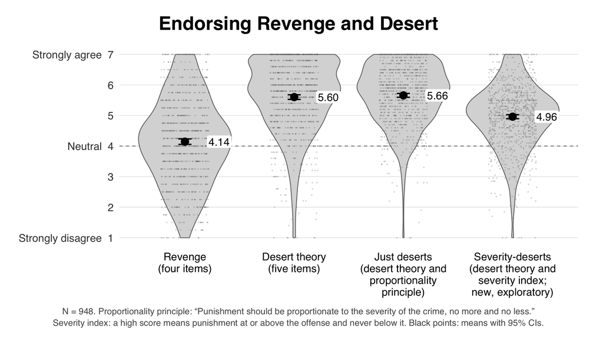

```r
keep_values("pt_01_endorsement", data.frame(
  label = paste("Mean (1 to 7):", SCORES[endorse$key]), value = endorse$mean,
  lower = endorse$lower, upper = endorse$upper, n = endorse$n))
fig01
```

```r
# === SLIDE 2: HOW CLOSELY EACH SCORE TRACKS PUNITIVENESS, WHOLE SAMPLE ===
# WHAT THIS CHUNK DOES: the correlation of each of the four scores with
# punitiveness (the paper's six-component score), with its Fisher 95%
# interval, as horizontal bars.
# READS: sc; PAPER_H10_cors and PAPER_JD_H10_cors for the guards.
# WRITES: pt_02_punitiveness; its values.
# MATCHES: Results, Part 2, H10: revenge r = .676 [.640, .709], desert theory
#          .674 [.638, .708], just deserts .432 [.379, .482]. Severity-deserts
#          (.734) is new; it is guarded against its value computed
#          independently of this document.
# A backup slide: slide 9, in the main line, shows these four correlations
# beside slide 4's, reusing `assoc` and its guards. The desert bars are mid
# gray (G3), severity-deserts is a white bar with a black outline, and the
# caption marks it as new and exploratory.
assoc <- do.call(rbind, lapply(names(SCORES), function(v)
  cbind(label = SCORES[[v]], key = v, family = FAMILY[[v]], cor_ci(sc$punit, sc[[v]]))))
# GUARDS: each r and both ends of its interval against the export row that
# holds it (1e-8), then against the paper's three-decimal values.
h10c <- read_s2("PAPER_H10_cors"); jd10c <- read_s2("PAPER_JD_H10_cors")
pick_cor <- function(tab, sample, y, x = "Punitiveness (six components)")
  tab[tab$sample == sample & tab$x == x & tab$y == y, ]
chk2 <- list(revenge = pick_cor(h10c, "Whole sample", "Revenge"),
             desert_theory = pick_cor(h10c, "Whole sample", "Desert theory"),
             just_deserts = pick_cor(jd10c, "Whole sample", "Just deserts"))
for (v in names(chk2)) {
  stopifnot(nrow(chk2[[v]]) == 1)
  a <- assoc[assoc$key == v, ]
  same(c(a$r, a$lower, a$upper), c(chk2[[v]]$r, chk2[[v]]$ci_lower, chk2[[v]]$ci_upper),
       paste("slide 2: r and CI,", v))
}
paper_same(assoc$r[assoc$key == "revenge"],          .676, 3, "r(punitiveness, revenge) .676")
paper_same(assoc$r[assoc$key == "desert_theory"],    .674, 3, "r(punitiveness, desert theory) .674")
paper_same(assoc$r[assoc$key == "just_deserts"],     .432, 3, "r(punitiveness, just deserts) .432")
paper_same(assoc$r[assoc$key == "severity_deserts"], .734, 3, "r(punitiveness, severity-deserts) .734 (new; computed independently)")
stopifnot(all(assoc$n == 948))

# Revenge on top: rows are drawn bottom-up, so the levels are reversed.
assoc$label <- factor(assoc$label, levels = rev(unname(SCORES)))
fig02 <- bar_r3(assoc, "label", "family", fills = FAMILY_FILLS,
               xlim = c(0, 0.84), xbreaks = seq(0, 0.8, 0.2),
               xlab = "Correlation with punitiveness (r)") +
  theme(legend.position = "none") +
  # REGISTRATION WORDING. The caption says severity-deserts is "new and
  # exploratory", not that it "was not preregistered": that
  # wording would imply that the other three bars were, and they were not as
  # scored here (desert theory and the paper's just deserts both depart from
  # the preregistration; Method, Analytic Strategy). "New" says it is not in
  # the paper; "exploratory" says that no hypothesis, registered or rerun,
  # bears on it. The registered tests are in the Supplement (Section S4).
  # "(white bar)" ties the words to the bar: severity-deserts is the only
  # white bar (FAMILY_FILLS, section 3).
  # THE CAPTION, one sentence group per line, so neither line breaks inside a
  # sentence or a list. Punitiveness is defined in the same words as on
  # slides 8 and 9: "two punitive attitudes" are support for more punishment
  # and rejection of parsimony; "three policies" are three-strikes laws, life
  # without parole and the death penalty. The six listed one by one do not
  # fit on one line, and a list split across two lines is hard to take in.
  labs(title = "Revenge, Desert, and Punitiveness",
       caption = cap("N = 948. Punitiveness: six standardized components (two punitive attitudes, three policies, the first sentence).",
                     "Error bars: 95% CIs. Severity-deserts (white bar) is new and exploratory."))
save_slide(fig02, "pt_02_punitiveness")
```

```
## [1] TRUE
```

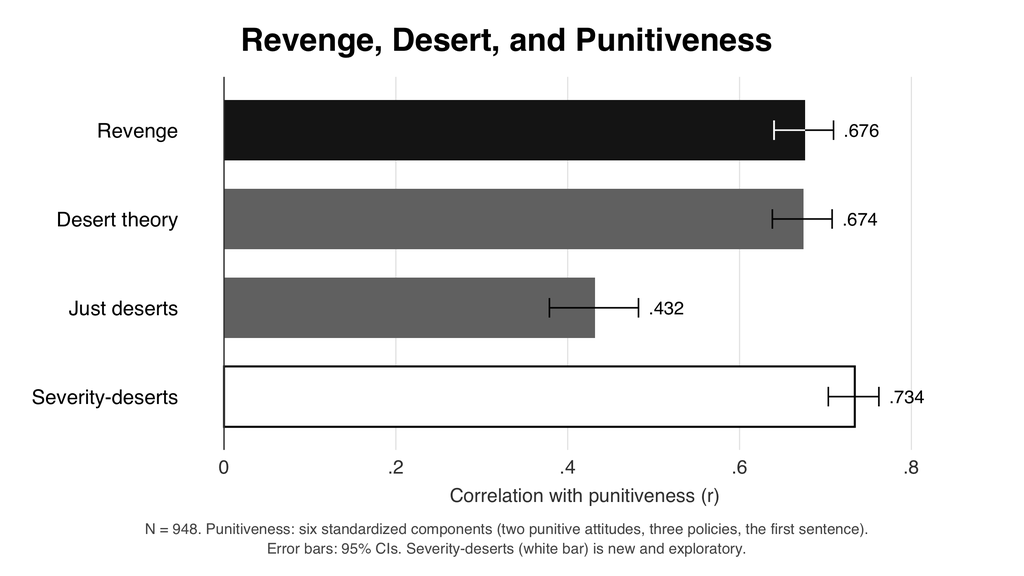

```r
keep_values("pt_02_punitiveness", data.frame(
  label = paste("r with punitiveness, whole sample:", assoc$label), value = assoc$r,
  lower = assoc$lower, upper = assoc$upper, n = assoc$n))
fig02
```

```r
# === SLIDE 3: THE PARTS OF THE TWO COMPOSITES, EACH WITH PUNITIVENESS ===
# WHAT THIS CHUNK DOES: the correlation with punitiveness of desert theory
# (the part both composites share), the proportionality principle (the second
# part of just deserts) and the severity index (the second part of
# severity-deserts). A composite that averages two parts goes with
# punitiveness roughly in proportion to what its parts bring, so this slide
# shows where the two composites' correlations on slide 2 come from.
# READS: sc; PAPER_H10_cors and PAPER_H6 for the guards.
# WRITES: pt_03_parts; its values.
# MATCHES: Results, Part 2, H6 ("r = .588 with the severity index against .038
#          with the principle"; not registered) and H10 (desert theory .674).
PARTS <- c(desert_theory = "Desert theory\n(in both composites)",
           proportionality_principle = "Proportionality principle\n(in just deserts)",
           severity_index = "Severity index\n(in severity-deserts)")
parts <- do.call(rbind, lapply(names(PARTS), function(v)
  cbind(label = PARTS[[v]], key = v, cor_ci(sc$punit, sc[[v]]))))
# GUARDS: desert theory against PAPER_H10_cors; the principle and the index
# against the H6 comparison for punitiveness (PAPER_H6: r_jk is the index,
# r_jh the principle); then against the paper's printed values.
h6 <- read_s2("PAPER_H6"); h6p <- h6[h6$pair == "Punitiveness (six components)", ]
stopifnot(nrow(h6p) == 1)
same(parts$r[parts$key == "desert_theory"], chk2$desert_theory$r, "slide 3: desert theory r")
same(parts$r[parts$key == "severity_index"], h6p$r_jk, "slide 3: severity index r (PAPER_H6)")
same(parts$r[parts$key == "proportionality_principle"], h6p$r_jh, "slide 3: principle r (PAPER_H6)")
paper_same(parts$r[parts$key == "severity_index"], .588, 3, "r(punitiveness, severity index) .588")
paper_same(parts$r[parts$key == "proportionality_principle"], .038, 3,
           "r(punitiveness, principle) .038")
stopifnot(all(parts$n == 948))

parts$label <- factor(parts$label, levels = rev(unname(PARTS)))
# One gray for all three bars: the slide compares three parts, not families.
parts$shade <- "part"
fig03 <- bar_r3(parts, "label", "shade", fills = c(part = G3),
               xlim = c(-0.08, 0.8), xbreaks = seq(0, 0.8, 0.2),
               xlab = "Correlation with punitiveness (r)") +
  theme(legend.position = "none",
        axis.text.y = element_text(colour = INK, size = 19, lineheight = 0.95)) +
  # THE CAPTION: N, the intervals, the two items of the severity index (the
  # second reverse-scored) and that none of the three correlations was
  # preregistered. The two items together are too long for one line, so the
  # line breaks between them, never inside a quoted item: each item is read
  # whole, as the participants read it. "Error bars" is on the first line to
  # keep the second as short as the other slides' lines.
  labs(title = "The Parts and Punitiveness",
       caption = cap("N = 948. Error bars: 95% CIs. Severity index: “Punishment should be greater than the seriousness of the crime” and, reversed,",
                     "“Punishment should be less severe than the harmfulness of the crime.” None of these correlations was preregistered."))
save_slide(fig03, "pt_03_parts")
```

```
## [1] TRUE
```

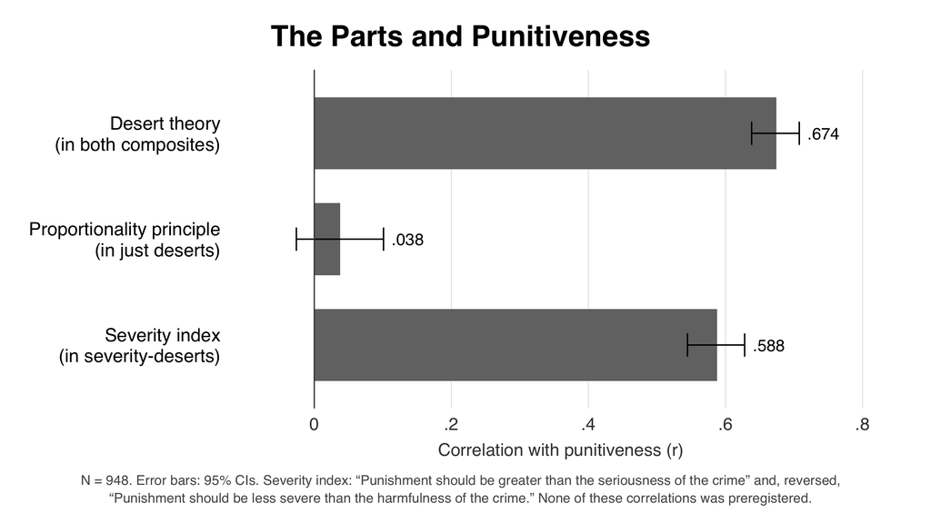

```r
keep_values("pt_03_parts", data.frame(
  label = paste("r with punitiveness, whole sample:", gsub("\n.*", "", parts$label)),
  value = parts$r, lower = parts$lower, upper = parts$upper, n = parts$n))
fig03
```

```r
# === SLIDE 4: THE SAME FOUR CORRELATIONS AMONG RETRIBUTIVISTS ===
# WHAT THIS CHUNK DOES: slide 2 repeated within the 371 retributivists, the
# participants who ranked "Criminals deserve to be punished" first.
# READS: sc; PAPER_H11_H10_cors and PAPER_JD_H10_cors for the guards.
# WRITES: pt_04_retributivists; its values.
# MATCHES: Results, Part 3, H11: revenge r = .570 against just deserts .157;
#          desert theory .545 (Table S17). Severity-deserts (.558) is new.
# A backup slide: slide 9, in the main line, shows these correlations beside
# slide 2's, reusing `assoc4` and its guards. Shaded as slide 2 is.
rt <- sc[sc$retributivist == 1, ]
stopifnot(nrow(rt) == 371)
assoc4 <- do.call(rbind, lapply(names(SCORES), function(v)
  cbind(label = SCORES[[v]], key = v, family = FAMILY[[v]], cor_ci(rt$punit, rt[[v]]))))
h11c <- read_s2("PAPER_H11_H10_cors")
chk4 <- list(revenge = pick_cor(h11c, "Retributivists", "Revenge"),
             desert_theory = pick_cor(h11c, "Retributivists", "Desert theory"),
             just_deserts = pick_cor(jd10c, "Retributivists", "Just deserts"))
for (v in names(chk4)) {
  stopifnot(nrow(chk4[[v]]) == 1, chk4[[v]]$n == 371)
  a <- assoc4[assoc4$key == v, ]
  same(c(a$r, a$lower, a$upper), c(chk4[[v]]$r, chk4[[v]]$ci_lower, chk4[[v]]$ci_upper),
       paste("slide 4: r and CI,", v))
}
paper_same(assoc4$r[assoc4$key == "revenge"],          .570, 3, "retributivists: revenge .570")
paper_same(assoc4$r[assoc4$key == "desert_theory"],    .545, 3, "retributivists: desert theory .545")
paper_same(assoc4$r[assoc4$key == "just_deserts"],     .157, 3, "retributivists: just deserts .157")
paper_same(assoc4$r[assoc4$key == "severity_deserts"], .558, 3, "retributivists: severity-deserts .558 (new; computed independently)")
stopifnot(all(assoc4$n == 371))

assoc4$label <- factor(assoc4$label, levels = rev(unname(SCORES)))
fig04 <- bar_r3(assoc4, "label", "family", fills = FAMILY_FILLS,
               xlim = c(0, 0.84), xbreaks = seq(0, 0.8, 0.2),
               xlab = "Correlation with punitiveness (r)") +
  theme(legend.position = "none") +
  labs(title = "Punitiveness Among Retributivists",
       caption = cap("Retributivists only: the 371 participants who ranked “Criminals deserve to be punished” first of four reasons for punishment.",
                     "Error bars are 95% confidence intervals. Severity-deserts (white bar) is new and exploratory."))
# (The caption says "new and exploratory", not "not preregistered", for the
# reason given on slide 2.)
save_slide(fig04, "pt_04_retributivists")
```

```
## [1] TRUE
```

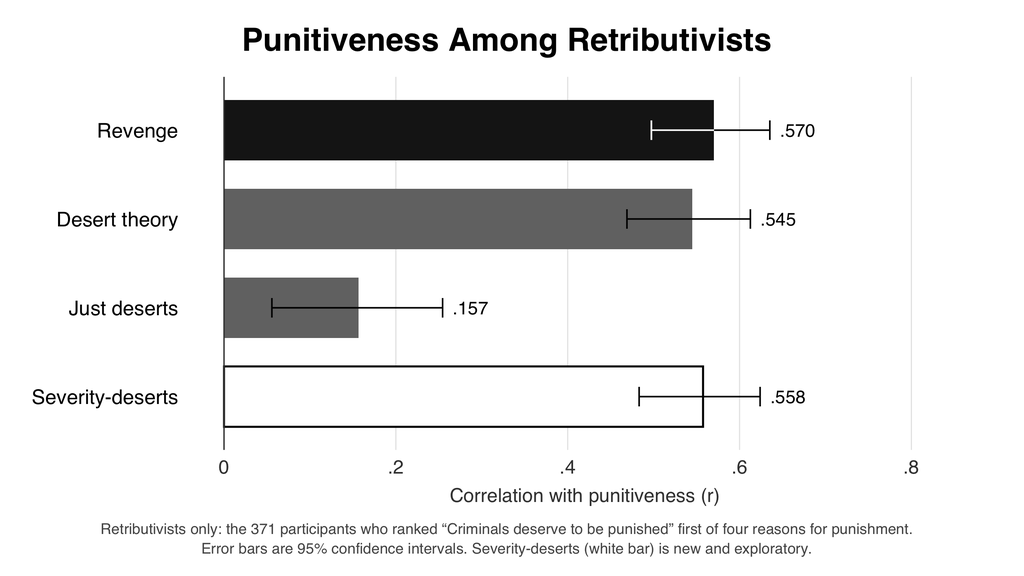

```r
keep_values("pt_04_retributivists", data.frame(
  label = paste("r with punitiveness, retributivists:", assoc4$label), value = assoc4$r,
  lower = assoc4$lower, upper = assoc4$upper, n = assoc4$n))
fig04
```

```r
# === THE TESTS BEHIND SLIDES 1 TO 4 (TABLE, NOT DRAWN) ===
# WHAT THIS CHUNK DOES: two families of tests, written to
# princeton_talk_tests.csv.
#   A. WHICH SCORE GOES MORE CLOSELY WITH PUNITIVENESS. Revenge against desert
#      theory, just deserts and severity-deserts, in the whole sample and
#      among retributivists, each by Steiger's Z with Zou's interval for the
#      difference in r. Revenge is scored with its four registered items and,
#      as a check, with Study 1's three items.
#   B. WHICH SCORE PARTICIPANTS ENDORSED MORE (H9-style). Each desert-based
#      score minus revenge, participant by participant: the mean difference,
#      its 95% interval, the paired t, and the paired d as 01 computes it. The
#      difference is taken as the desert score minus revenge so that its sign
#      matches the paper's (1.46, d = 1.18, for desert theory).
# READS: sc; the H9, H10 and H11 exports for the guards.
# WRITES: nothing yet; slide 11 (section 7) adds six rows and an `outcome`
#         column, and the table is written in section 8.
# MATCHES: Results, Part 2 (H9, H10) and Part 3 (H11); Table S17.
#
# WHAT IS REGISTERED, AND WHAT THIS TABLE HOLDS. H10 registered a comparison
# of revenge with just deserts, one-sided (revenge goes more closely with
# punitiveness); H9 registered just deserts against revenge, one-sided (just
# deserts endorsed more); H11 repeats both among retributivists. The
# REGISTERED TESTS are run on the registered just-deserts score (the
# registered desert items 1 to 4 averaged with the three-item proportionality
# component) and are in the Supplement: Table S12 for H9 and H10 (H9: d = 0.90;
# H10: delta r = .251, Z = 8.96, on the eight-item scale), Table S17 for H11
# (delta r = .384; H9's d = 0.76). NONE OF THOSE ROWS IS IN THIS TABLE.
# This table uses the paper's scorings, and neither was registered:
#   - just deserts as the mean of desert theory and the proportionality
#     principle ("Scoring the two parts as one departs from the
#     preregistration", Analytic Strategy; Supplement: "That score was not
#     registered"). These rows rerun the registered hypothesis, in its
#     registered direction, on that score.
#   - desert theory, the five desert-theory items, which the paper reports
#     beside just deserts; also a rerun in the registered direction.
# A rerun of a registered one-sided test on another scoring keeps the
# registered direction (Analytic Strategy; Supplement S4), so these rows carry
# a one-sided p. Three-item revenge rows are rescorings of revenge, so they
# too keep the registered direction.
# Severity-deserts is a new score, not a rescoring of just deserts (it has no
# proportionality in it), so its rows rerun no registered test: they are
# exploratory and two-sided only, and their one-sided p is left blank.
# DANGER: never label a row here "registered test". The registered test is
# on the registered just-deserts score and gives different numbers; quoting
# .244 / Z = 8.70 or d = 1.08 as "the registered test" would misstate it.
RIVALS <- c(desert_theory = "Desert theory", just_deserts = "Just deserts",
            severity_deserts = "Severity-deserts")
# Three-item revenge is named by its source, Study 1's three items: the
# Supplement reports two three-item scorings (Table S12: without the father
# item, and Study 1's three items, which leave out the harsher-punishment
# item), and "three items" alone would not say which.
REV_SCORING <- c(revenge = "Revenge, four items",
                 revenge3 = "Revenge, Study 1's three items (check)")
status_of <- function(rev, rival, sample, family) {
  # The hypothesis each row belongs to: H10 (correlations) or H9 (endorsement)
  # in the whole sample, and H11, which repeats them among retributivists.
  base <- if (family == "A") "H10" else "H9"
  hyp <- if (sample == "Whole sample") base else paste0("H11: ", base, " among retributivists")
  # Where the registered test on the registered just-deserts score is found.
  where <- if (sample == "Whole sample") "Table S12" else "Table S17"
  if (rival == "severity_deserts")
    return(paste0("exploratory: new score, not preregistered, reruns no registered test; ",
                  "two-sided only",
                  if (rev == "revenge3") "; revenge on Study 1's three items (check on the revenge scoring)" else ""))
  if (rev == "revenge3")
    return(paste0("exploratory: revenge on Study 1's three items (check on the revenge scoring); ",
                  "registered direction of ", hyp, " kept"))
  if (rival == "just_deserts")
    return(paste0("registered hypothesis and direction (", hyp, "), on the paper's ",
                  "just-deserts score, which was not registered; the registered test uses ",
                  "the registered just-deserts score (", where, ")"))
  # Desert theory rows: the hypothesis names just deserts, so these rows are
  # the hypothesis rerun with desert theory in its place, as the paper
  # reports them.
  paste0(hyp, " rerun on desert theory in place of just deserts, one-sided in the ",
         "registered direction, as the paper reports it; desert theory was not ",
         "registered; the registered test is in ", where)
}

# --- A. Dependent correlations -------------------------------------------------
SAMPLES <- list("Whole sample" = sc, "Retributivists" = rt)
tests_a <- do.call(rbind, lapply(names(SAMPLES), function(s) {
  x <- SAMPLES[[s]]
  do.call(rbind, lapply(names(REV_SCORING), function(rv) {
    do.call(rbind, lapply(names(RIVALS), function(h) {
      cbind(family = "Correlation with punitiveness: revenge vs rival (Steiger Z, Zou CI)",
            sample = s, revenge_scoring = REV_SCORING[[rv]], rival = RIVALS[[h]],
            rv_key = rv, rival_key = h,
            dep_cor(x$punit, x[[rv]], x[[h]]),
            status = status_of(rv, h, s, "A"), stringsAsFactors = FALSE)
    }))
  }))
}))
# GUARDS against the exports: each r, the correlation between the two scores,
# the difference, both ends of Zou's interval and Z, each to 1e-8 relative to
# its own size (same_each()), and the one-sided p on its own (same_p()). The
# exports hold cocor's one-sided p, 1 - pnorm(Z), which loses digits to
# cancellation when p is small and underflows to exactly 0 once Z passes about
# 8.3 (revenge against just deserts, Z = 8.70). same_p() is therefore run with
# a floor of 1e-15, which absorbs that cancellation and nothing larger: where
# the export's p is not 0 it must still agree to about 1e-8 relative (a
# doubled p fails), and where it is 0 the guard on Z carries the check.
tA <- function(s, rv, h) tests_a[tests_a$sample == s & tests_a$rv_key == rv & tests_a$rival_key == h, ]
chk_dep <- function(row, ex, what) {
  stopifnot(nrow(row) == 1, nrow(ex) == 1, row$n == ex$n)
  same_each(c(row$r_revenge, row$r_rival, row$r_revenge_rival, row$diff,
              row$diff_lower, row$diff_upper, row$z),
            c(ex$r_jk, ex$r_jh, ex$r_kh, ex$diff, ex$diff_lower, ex$diff_upper, ex$z), what,
            labels = c("r revenge", "r rival", "r revenge-rival", "difference",
                       "difference lower", "difference upper", "Z"))
  same_p(row$p_one, ex$p, paste(what, "one-sided p"), floor = 1e-15)
}
h10 <- read_s2("PAPER_H10"); jd10 <- read_s2("PAPER_JD_H10")
h11 <- read_s2("PAPER_H11_H10"); jd11 <- read_s2("PAPER_JD_H11_H10")
SIX <- "Punitiveness (six components)"
REG <- "one-sided, registered direction"
chk_dep(tA("Whole sample", "revenge", "desert_theory"),
        h10[h10$punitiveness == SIX & h10$sidedness == REG, ], "H10, revenge vs desert theory")
chk_dep(tA("Whole sample", "revenge", "just_deserts"),
        jd10[jd10$punitiveness == SIX & jd10$sidedness == REG, ], "H10, revenge vs just deserts")
chk_dep(tA("Whole sample", "revenge3", "desert_theory"),
        h10[h10$punitiveness == SIX & grepl("^one-sided.*three-item", h10$sidedness), ],
        "H10, three-item revenge vs desert theory")
chk_dep(tA("Retributivists", "revenge", "desert_theory"),
        h11[h11$punitiveness == SIX & h11$sidedness == REG, ], "H11, revenge vs desert theory")
chk_dep(tA("Retributivists", "revenge", "just_deserts"),
        jd11[jd11$punitiveness == SIX & jd11$sidedness == REG, ], "H11, revenge vs just deserts")
# GUARDS against the paper's printed values (Part 2 and Part 3) and, for the
# new comparison (revenge vs severity-deserts), against its values computed
# independently of this document.
a <- tA("Whole sample", "revenge", "desert_theory")
paper_same(a$diff, .002, 3, "H10 dt: diff .002"); paper_same(a$diff_lower, -.039, 3, "H10 dt: lower")
paper_same(a$diff_upper, .042, 3, "H10 dt: upper"); paper_same(a$z, 0.09, 2, "H10 dt: Z 0.09")
paper_same(a$p_one, .47, 2, "H10 dt: one-sided p .47")
a <- tA("Whole sample", "revenge", "just_deserts")
paper_same(a$diff, .244, 3, "H10 jd: diff .244"); paper_same(a$diff_lower, .188, 3, "H10 jd: lower")
paper_same(a$diff_upper, .301, 3, "H10 jd: upper"); paper_same(a$z, 8.70, 2, "H10 jd: Z 8.70")
a <- tA("Whole sample", "revenge", "severity_deserts")
paper_same(a$diff, -.058, 3, "revenge vs severity-deserts: diff -.058 (new; computed independently)")
paper_same(a$diff_lower, -.094, 3, "revenge vs severity-deserts: lower -.094")
paper_same(a$diff_upper, -.022, 3, "revenge vs severity-deserts: upper -.022")
paper_same(a$z, -3.20, 2, "revenge vs severity-deserts: Z -3.20")
a <- tA("Retributivists", "revenge", "desert_theory")
paper_same(a$diff, .026, 3, "H11 dt: diff .026"); paper_same(a$diff_lower, -.060, 3, "H11 dt: lower")
paper_same(a$diff_upper, .112, 3, "H11 dt: upper"); paper_same(a$p_one, .28, 2, "H11 dt: p .28")
a <- tA("Retributivists", "revenge", "just_deserts")
paper_same(a$diff, .414, 3, "H11 jd: diff .414"); paper_same(a$diff_lower, .295, 3, "H11 jd: lower")
paper_same(a$diff_upper, .531, 3, "H11 jd: upper"); paper_same(a$z, 6.75, 2, "H11 jd: Z 6.75")
```

```r
# --- B. Paired endorsement --------------------------------------------------------
# Four-item revenge only: H9 is registered on the four items, and the
# three-item check concerns H10's correlations, not endorsement.
tests_b <- do.call(rbind, lapply(names(SAMPLES), function(s) {
  x <- SAMPLES[[s]]
  do.call(rbind, lapply(names(RIVALS), function(h) {
    cbind(family = "Endorsement: rival minus revenge (paired t, paired d)",
          sample = s, revenge_scoring = REV_SCORING[["revenge"]], rival = RIVALS[[h]],
          rv_key = "revenge", rival_key = h,
          paired_diff(x[[h]], x$revenge),
          status = status_of("revenge", h, s, "B"), stringsAsFactors = FALSE)
  }))
}))
tB <- function(s, h) tests_b[tests_b$sample == s & tests_b$rival_key == h, ]
# GUARDS against the H9 exports: every number to 1e-8 relative to its own
# size (same_each()), and both p's on their own (same_p(); no floor, because
# 01 and this document both take them from t.test()).
chk_pair <- function(row, ex, what) {
  stopifnot(nrow(row) == 1, nrow(ex) == 1, row$n == ex$n)
  same_each(c(row$M1, row$M2, row$mean_diff, row$diff_lower, row$diff_upper, row$t,
              row$d, row$d_lower, row$d_upper),
            c(ex$M1, ex$M2, ex$mean_diff, ex$ci_lower, ex$ci_upper, ex$t,
              ex$d, ex$d_lower, ex$d_upper), what,
            labels = c("M rival", "M revenge", "difference", "difference lower",
                       "difference upper", "t", "d", "d lower", "d upper"))
  same_p(row$p_two, ex$p_two, paste(what, "two-sided p"))
  same_p(row$p_one, ex$p_dir, paste(what, "one-sided p"))
}
h11_9 <- read_s2("PAPER_H11_H9"); jd11_9 <- read_s2("PAPER_JD_H11_H9")
chk_pair(tB("Whole sample", "desert_theory"), h9, "H9, desert theory vs revenge")
chk_pair(tB("Whole sample", "just_deserts"), jd9[jd9$var1 == "just_deserts", ],
         "H9, just deserts vs revenge")
chk_pair(tB("Retributivists", "desert_theory"), h11_9, "H11 (H9), desert theory vs revenge")
chk_pair(tB("Retributivists", "just_deserts"), jd11_9[jd11_9$var1 == "just_deserts", ],
         "H11 (H9), just deserts vs revenge")
b <- tB("Whole sample", "desert_theory")
paper_same(b$mean_diff, 1.46, 2, "H9: difference 1.46"); paper_same(b$diff_lower, 1.38, 2, "H9: lower")
paper_same(b$diff_upper, 1.54, 2, "H9: upper"); paper_same(b$t, 36.22, 2, "H9: t 36.22")
paper_same(b$d, 1.18, 2, "H9: d 1.18"); paper_same(b$d_lower, 1.09, 2, "H9: d lower")
paper_same(b$d_upper, 1.26, 2, "H9: d upper")
b <- tB("Whole sample", "just_deserts")
paper_same(b$mean_diff, 1.52, 2, "H9 jd: difference 1.52"); paper_same(b$t, 33.27, 2, "H9 jd: t")
paper_same(b$d, 1.08, 2, "H9 jd: d 1.08")
paper_same(tB("Retributivists", "desert_theory")$d, 1.25, 2, "H11: H9 d 1.25")
paper_same(tB("Retributivists", "just_deserts")$d, 0.93, 2, "H11: H9 jd d 0.93")

# One table, family A and family B stacked; columns a family does not use are
# NA. The statistic column says which test statistic each row carries.
# ONE-SIDED p ONLY WHERE A REGISTERED DIRECTION EXISTS. The paper's rule is
# that analyses that were not registered are two-sided unless they rerun a
# registered test (Analytic Strategy). Severity-deserts reruns none, so its
# rows carry the two-sided p only and the one-sided column is NA. Printing a
# "registered-direction" p there would invite misreading: revenge against
# severity-deserts gives two-sided p = .0014 with severity-deserts AHEAD, which
# a one-sided p of .9993 would hide.
one_sided_or_na <- function(p, rival_key) ifelse(rival_key == "severity_deserts", NA_real_, p)
TEST_COLS <- c("family", "sample", "revenge_scoring", "rival", "n",
               "r_revenge", "r_rival", "r_revenge_rival",
               "M_rival", "M_revenge", "difference", "difference_lower", "difference_upper",
               "statistic", "statistic_value", "df", "p_two_sided",
               "p_one_sided_registered_direction", "paired_d", "paired_d_lower",
               "paired_d_upper", "status")
out_a <- data.frame(tests_a[, c("family", "sample", "revenge_scoring", "rival", "n",
                                "r_revenge", "r_rival", "r_revenge_rival")],
                    M_rival = NA_real_, M_revenge = NA_real_,
                    difference = tests_a$diff, difference_lower = tests_a$diff_lower,
                    difference_upper = tests_a$diff_upper,
                    statistic = "Steiger Z", statistic_value = tests_a$z, df = NA_real_,
                    p_two_sided = tests_a$p_two,
                    p_one_sided_registered_direction = one_sided_or_na(tests_a$p_one,
                                                                       tests_a$rival_key),
                    paired_d = NA_real_, paired_d_lower = NA_real_, paired_d_upper = NA_real_,
                    status = tests_a$status, stringsAsFactors = FALSE)
out_b <- data.frame(tests_b[, c("family", "sample", "revenge_scoring", "rival", "n")],
                    r_revenge = NA_real_, r_rival = NA_real_, r_revenge_rival = NA_real_,
                    M_rival = tests_b$M1, M_revenge = tests_b$M2,
                    difference = tests_b$mean_diff, difference_lower = tests_b$diff_lower,
                    difference_upper = tests_b$diff_upper,
                    statistic = "paired t", statistic_value = tests_b$t, df = tests_b$df,
                    p_two_sided = tests_b$p_two,
                    p_one_sided_registered_direction = one_sided_or_na(tests_b$p_one,
                                                                       tests_b$rival_key),
                    paired_d = tests_b$d, paired_d_lower = tests_b$d_lower,
                    paired_d_upper = tests_b$d_upper,
                    status = tests_b$status, stringsAsFactors = FALSE)
TESTS <- rbind(out_a[, TEST_COLS], out_b[, TEST_COLS])
rownames(TESTS) <- NULL
# GUARDS on the table's labelling: the one-sided p is blank on every
# severity-deserts row and on no other; every row has a two-sided p; and no
# row calls itself "registered test" (see WHAT IS REGISTERED above).
sev <- TESTS$rival == "Severity-deserts"
stopifnot(sum(sev) == 6,
          all(is.na(TESTS$p_one_sided_registered_direction[sev])),
          !anyNA(TESTS$p_one_sided_registered_direction[!sev]),
          !anyNA(TESTS$p_two_sided),
          !any(grepl("registered test (", TESTS$status, fixed = TRUE)),
          !any(grepl("^registered test", TESTS$status)))
print(TESTS[, c("sample", "revenge_scoring", "rival", "difference", "difference_lower",
                "difference_upper", "statistic_value", "p_two_sided", "paired_d")], digits = 3)
```

```
##            sample                        revenge_scoring            rival
## 1    Whole sample                    Revenge, four items    Desert theory
## 2    Whole sample                    Revenge, four items     Just deserts
## 3    Whole sample                    Revenge, four items Severity-deserts
## 4    Whole sample Revenge, Study 1's three items (check)    Desert theory
## 5    Whole sample Revenge, Study 1's three items (check)     Just deserts
## 6    Whole sample Revenge, Study 1's three items (check) Severity-deserts
## 7  Retributivists                    Revenge, four items    Desert theory
## 8  Retributivists                    Revenge, four items     Just deserts
## 9  Retributivists                    Revenge, four items Severity-deserts
## 10 Retributivists Revenge, Study 1's three items (check)    Desert theory
## 11 Retributivists Revenge, Study 1's three items (check)     Just deserts
## 12 Retributivists Revenge, Study 1's three items (check) Severity-deserts
## 13   Whole sample                    Revenge, four items    Desert theory
## 14   Whole sample                    Revenge, four items     Just deserts
```

[output cut: 42 more lines]

# 5. Two models of agency

```r
# === SLIDE 5: TWO MODELS OF AGENCY (BAR CHART OF COHEN'S d, TWO GROUPS) ===
# WHAT THIS CHUNK DOES: Cohen's d, retributivists (371) minus the participants
# who ranked deterrence or incapacitation first (453), for seven registered
# contrasts, grouped under the two models of agency Dan proposed:
#   AGENCY AS BLAMEWORTHINESS: agency and the capacity to choose make the
#     offender the author of the crime, so a retributivist who holds this view
#     should see offenders as criminal to the core (essentialism), see crime as
#     a choice, and reject society's share of responsibility. The model
#     predicts that retributivists score HIGHER on all three.
#   AGENCY AS BENEVOLENCE: retribution rests on respect for the offender's
#     dignity as an agent, so a retributivist who holds this view should be no
#     more hateful and no more willing to degrade, to inflict suffering, or to
#     impose harsh prison conditions. The model predicts that retributivists
#     score NO HIGHER (or lower) on all four.
# The d values and intervals are read from the export and each is recomputed
# from the data exactly as 01 computes it.
# READS: sc; PAPER_contrasts_vs_deter_incap.
# WRITES: pt_05_agency; its values.
# MATCHES: Results, Part 3 and General Discussion (essentialism d = 0.59,
#          choice 0.47, rejecting society's responsibility 0.50); Table S19,
#          last column (hatred 0.48, degradation 0.36, suffering 0.42, harsh
#          conditions 0.52). The contrasts are registered (H13, H16, H17, H19);
#          the comparison group (leaving out the rehabilitation-first) and the
#          grouping into two models are not.
# A backup slide: slide 10, in the main line, tells the same comparison in
# shares. The caption says that the seven contrasts are preregistered, under
# which hypotheses, and that only the comparison group and the two-model
# grouping are not; a guard checks the hypotheses against the export.
MODELS <- c(blame = "Agency as blameworthiness: predicts retributivists higher",
            benev = "Agency as benevolence: predicts retributivists no higher")
AGENCY <- data.frame(
  variable = c("essentialism", "choice", "society_reject",
               "hatred", "degradation", "suffering", "harsh"),
  label = c("Essentialism about offenders", "Crime is a choice",
            "Rejecting society’s responsibility",
            "Hatred of offenders", "Degradation of prisoners",
            "Infliction of suffering", "Harsh prison conditions"),
  model = MODELS[c("blame", "blame", "blame", "benev", "benev", "benev", "benev")],
  # The d the paper prints for each (two decimals), for the printed-value guard.
  paper_d = c(0.59, 0.47, 0.50, 0.48, 0.36, 0.42, 0.52),
  stringsAsFactors = FALSE)
cq <- read_s2("PAPER_contrasts_vs_deter_incap")
stopifnot(all(AGENCY$variable %in% cq$variable), all(cq$grouping == "grp_vs_deter_incap"))
ag <- do.call(rbind, lapply(seq_len(nrow(AGENCY)), function(i) {
  ex <- cq[cq$variable == AGENCY$variable[i], ]
  stopifnot(nrow(ex) == 1, ex$alternative == "greater")
  # GUARD: recompute the contrast from the data, 01's way (welch_d(), which is
  # welch_contrast()), and demand the export's n's exactly; its means, t, d
  # and interval each to 1e-8 relative to its own size (same_each()); and its
  # one-sided p on its own, to 1e-8 relative (same_p()), because inside one
  # vector beside t and the means a p of 1e-12 would hardly be checked.
  re <- welch_d(d[[AGENCY$variable[i]]], sc$grp_vs_deter_incap, alternative = "greater")
  stopifnot(re$n1 == ex$n1, re$n2 == ex$n2)
  same_each(c(re$M1, re$M2, re$t, re$d, re$lower, re$upper),
            c(ex$M1, ex$M2, ex$t, ex$d, ex$d_lower, ex$d_upper),
            paste("slide 5: contrast,", AGENCY$variable[i]),
            labels = c("M1", "M2", "t", "d", "d lower", "d upper"))
  same_p(re$p_dir, ex$p_dir, paste("slide 5: one-sided p,", AGENCY$variable[i]))
  paper_same(ex$d, AGENCY$paper_d[i], 2, paste("slide 5: printed d,", AGENCY$variable[i]))
  data.frame(label = AGENCY$label[i], model = AGENCY$model[i], d = ex$d,
             lower = ex$d_lower, upper = ex$d_upper, p_dir = ex$p_dir,
             n1 = ex$n1, n2 = ex$n2, hypothesis = ex$hypothesis,
             stringsAsFactors = FALSE)
}))
# Every one of the seven is one-sided p < .001 (Table S19 note).
stopifnot(all(ag$p_dir < .001), all(ag$n1 == 371), all(ag$n2 == 453))
# GUARD FOR THE CAPTION: the caption names the hypotheses the seven contrasts
# were registered under, H13 (the four hostile measures), H16 (essentialism),
# H17 (choice) and H19 (society's responsibility), read here from the export,
# so the caption cannot name a hypothesis the contrasts do not belong to.
stopifnot(identical(sort(unique(ag$hypothesis)), c("H13", "H16", "H17", "H19")),
          identical(ag$hypothesis[ag$label %in% AGENCY$label[4:7]], rep("H13", 4)))

# Rows keep the order listed above within each group; rows are drawn
# bottom-up, so the levels are reversed. The facet order puts the
# blameworthiness group on top.
ag$label <- factor(ag$label, levels = rev(AGENCY$label))
ag$model <- factor(ag$model, levels = unname(MODELS))
# The two groups take two clearly different grays; the strip above each panel
# names the group and its prediction, so no legend is needed.
# DANGER: not the lightest data gray (G4). On slide 6, G4 means "one-sided
# p >= .05", and every benevolence contrast here is p < .001; in G4 these
# bars would look weak or non-significant, the opposite of what they show.
# G3 keeps the two groups clearly apart (#1a1a1a against #737373).
MODEL_FILLS <- setNames(c(G1, G3), unname(MODELS))
fig05 <- bar_d(ag, "label", "model", fills = MODEL_FILLS,
               xlim = c(0, 0.8), xbreaks = seq(0, 0.8, 0.2),
               # "95% CI" sits in the axis title, which frees the caption's
               # two lines for the comparison group and what was registered.
               xlab = "Retributivists minus deterrence- or incapacitation-first (Cohen’s d, 95% CI)") +
  # ONE PANEL PER MODEL, stacked, each only as tall as its rows need
  # (space = "free_y"), so the bars are equally thick in both panels.
  facet_wrap(~ model, ncol = 1, scales = "free_y", space = "free_y") +
  theme(legend.position = "none",
        strip.text = element_text(size = 20, face = "bold", colour = INK, hjust = 0,
                                  margin = margin(t = 6, b = 8)),
        panel.spacing.y = unit(1.4, "lines")) +
  labs(title = "Two Models of Agency",
       # "n\u00a0=\u00a0371" uses non-breaking spaces, so the caption's line wrap
       # can never split a sample size from its "n =".
       # WHAT WAS AND WAS NOT REGISTERED, said on the slide, as the paper says
       # it wherever these d's appear (Part 3, Figure 10 note). The caption
       # first says what WAS registered, the seven contrasts and their
       # hypotheses (guarded above), and then that ONLY the comparison group
       # and the grouping into two models were not, so no one reads the whole
       # slide as exploratory. That the comparison leaves out the 124 who
       # ranked rehabilitation first is said by the two group sizes, which do
       # not add to 948, and by the header of this chunk; the caption keeps to
       # two lines.
       caption = cap("Retributivists (ranked retribution first, n\u00a0=\u00a0371) vs deterrence- or incapacitation-first (n\u00a0=\u00a0453). Positive d: retributivists higher.",
                     "The seven contrasts are preregistered (H13, H16, H17, H19); only this comparison group and the two-model grouping are not."))
save_slide(fig05, "pt_05_agency")
```

```
## [1] TRUE
```

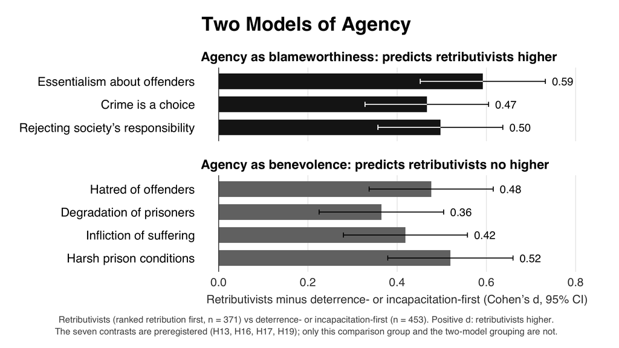

```r
keep_values("pt_05_agency", data.frame(
  label = paste0(sub(":.*", "", ag$model), ": ", ag$label, " (d, 371 vs 453)"),
  value = ag$d, lower = ag$lower, upper = ag$upper, n = ag$n1 + ag$n2))
fig05
```

# 6. The four ways of identifying retributivists

```r
# === SLIDE 6: THE REGISTERED CONTRASTS UNDER EACH OF THE FOUR GROUPINGS ===
# WHAT THIS CHUNK DOES: Cohen's d with its 95% interval for the 20 registered
# contrasts (H13 to H21), under each registered grouping, as four panels side
# by side that share one list of measures:
#   Ranking        retribution ranked first (371) against all others (577),
#                  the registered primary comparison;
#   Median split   on relative retribution (470 against 478);
#   Thirds         top against bottom third of relative retribution (314, 317);
#   Sentencing ratio  kept or raised the sentence (514) against reduced it (433).
# The 20 contrasts are the 19 rows from the hostile aggression cluster to
# convicting on uncertain evidence, plus punitiveness counted once: the
# six-component score under the first three groupings, and under the
# sentencing ratio the five attitude components without the sentence, because
# that grouping is built from the sentences (prereg 5.11; Table S16 note). The
# first sentence (H14) cannot be run under the ratio and is marked "not run".
# The exploratory E1 rows and the second punitiveness row are left out, as
# the paper's counts leave them out.
# READS: sc, d; PAPER_contrasts_rank, _med, _tert, _ratio; PAPER_scorecard
#        (for the guard on the medians).
# WRITES: pt_06_four_groupings; its values, with each panel's median d and
#         its typical interval half-width.
# MATCHES: Table S16 (all four columns, and the medians 0.51, 0.20, 0.30,
#          0.40); Supplement S5.
# DESIGN (slide 6 is in the talk's main line):
#   - NO ERROR BARS. With 79 bars on one slide, whiskers would crowd the bars.
#     Every interval here is nearly the same width within a grouping (the
#     groups' sizes do not change from one measure to the next), so the
#     caption states the typical half-width, computed below from the exports,
#     and the values table keeps every interval.
#   - The first panel is headed "Ranking (vs all others)", which says on the
#     slide that the registered comparison is with all 577 others, not with
#     the 453 of slide 5.
#   - A dashed line at each panel's median d, labelled with its value, so the
#     medians of slide 7 can be read here without it.
#   - Row labels at 17 pt, large enough to read on a projector, and no
#     legend: the caption says what the dark bars are, and the legend's
#     height goes to the rows.
#   - The ratio's empty first-sentence cell reads "not run", and the caption
#     says why.
GROUPINGS <- data.frame(
  key = c("rank", "med", "tert", "ratio"),
  col = c("grp_rank", "grp_med", "grp_tert", "grp_ratio"),
  name = c("Ranking", "Median split", "Top vs bottom third", "Sentencing ratio"),
  stringsAsFactors = FALSE)
# The 19 non-punitiveness contrasts, by their variable names in the exports and
# the scored data, with the labels the slide prints (Table S16's wording, except
# "Hatred of offenders", which is slide 5's label for the same measure, so the
# two slides name it alike).
CONTRASTS <- c(hostile_agg = "Hostile aggression cluster", hatred = "Hatred of offenders",
               revenge = "Revenge", degradation = "Degradation of prisoners",
               suffering = "Infliction of suffering",
               prisonviol = "Tolerance of prison violence", anger = "Anger",
               exclusion = "Social exclusion", harsh = "Harsh prison conditions",
               crimerates = "Perceived crime rates", fear = "Fear of crime",
               Sentence1_z = "First sentence", Shark_3 = "Painful death for the shark",
               essentialism = "Essentialism about offenders", choice = "Crime is a choice",
               leanPros = "Leaning toward the prosecution",
               society_reject = "Rejecting society’s responsibility",
               dueprocess = "Due-process permissiveness",
               uncertain = "Convicting on uncertain evidence")
PUNIT_LAB <- "Punitiveness"
# Punitiveness under each grouping: the export's variable name and the
# person-score column that holds it.
# DANGER: under the ratio this must stay the five-component score. The
# six-component score contains the first sentence, and the ratio grouping is
# built from the sentences, so using it there would put the sentence on both
# sides of the comparison.
PUNIT_VAR <- c(rank = "punit_parts6", med = "punit_parts6", tert = "punit_parts6",
               ratio = "punit_parts5z")
PUNIT_COL <- c(punit_parts6 = "punit_six", punit_parts5z = "punit_five_z")

g6 <- do.call(rbind, lapply(seq_len(nrow(GROUPINGS)), function(k) {
  gk <- GROUPINGS[k, ]
  ex <- read_s2(paste0("PAPER_contrasts_", gk$key))
  stopifnot(all(ex$grouping == gk$col))
  vars <- c(names(CONTRASTS), PUNIT_VAR[[gk$key]])
  # H14 (the first sentence) is absent from the ratio export by design.
  if (gk$key == "ratio") {
    stopifnot(!"Sentence1_z" %in% ex$variable, !"punit_parts6" %in% ex$variable)
    vars <- setdiff(vars, "Sentence1_z")
  }
  do.call(rbind, lapply(vars, function(v) {
    e <- ex[ex$variable == v, ]
    stopifnot(nrow(e) == 1, e$alternative == "greater",
              e$hypothesis %in% paste0("H", 13:21))
    # GUARD: recompute from the data, 01's way, and demand the export: t, d
    # and both ends of the interval each to 1e-8 relative to its own size
    # (same_each(); a d of 0.00 beside a t of 7 would otherwise hardly be
    # checked), and the one-sided p on its own (same_p()). The p matters here:
    # it sets each bar's shade and slide 7's counts.
    y <- if (v %in% names(PUNIT_COL)) ps[[PUNIT_COL[[v]]]] else d[[v]]
    re <- welch_d(y, sc[[gk$col]], alternative = "greater")
    stopifnot(re$n1 == e$n1, re$n2 == e$n2)
    same_each(c(re$t, re$d, re$lower, re$upper), c(e$t, e$d, e$d_lower, e$d_upper),
              paste("slide 6:", gk$key, v), labels = c("t", "d", "d lower", "d upper"))
    same_p(re$p_dir, e$p_dir, paste("slide 6: one-sided p,", gk$key, v))
    data.frame(grouping = gk$key, variable = v,
               label = if (v %in% names(PUNIT_COL)) PUNIT_LAB else CONTRASTS[[v]],
               d = e$d, lower = e$d_lower, upper = e$d_upper, p_dir = e$p_dir,
               n1 = e$n1, n2 = e$n2, stringsAsFactors = FALSE)
  }))
}))
# GUARDS: 20 contrasts under each grouping but the ratio, 19 under it.
stopifnot(identical(as.integer(table(factor(g6$grouping, levels = GROUPINGS$key))),
                    c(20L, 20L, 20L, 19L)))
# GUARDS against Table S16 (two decimals), a few values per column, so a
# column cannot be misassigned: punitiveness, essentialism, the shark's pain
# (negative under three groupings), and fear of crime.
gd <- function(g, v) g6$d[g6$grouping == g & g6$variable == v]
paper_same(gd("rank", "punit_parts6"), 0.80, 2, "S16: punitiveness, ranking")
paper_same(gd("med", "punit_parts6"), 0.24, 2, "S16: punitiveness, median split")
paper_same(gd("tert", "punit_parts6"), 0.36, 2, "S16: punitiveness, thirds")
paper_same(gd("ratio", "punit_parts5z"), 0.61, 2, "S16: punitiveness, ratio")
paper_same(gd("rank", "essentialism"), 0.69, 2, "S16: essentialism, ranking")
paper_same(gd("ratio", "essentialism"), 0.48, 2, "S16: essentialism, ratio")
paper_same(gd("med", "Shark_3"), -0.04, 2, "S16: shark, median split")
paper_same(gd("tert", "Shark_3"), -0.11, 2, "S16: shark, thirds")
paper_same(gd("ratio", "Shark_3"), -0.06, 2, "S16: shark, ratio")
paper_same(gd("tert", "fear"), 0.08, 2, "S16: fear, thirds")
```

```r
# Panel titles carry each grouping's two group sizes, read from the data.
ns6 <- aggregate(cbind(n1, n2) ~ grouping, data = g6, FUN = function(x) x[1])
stopifnot(all(aggregate(cbind(n1, n2) ~ grouping, data = g6,
                        FUN = function(x) length(unique(x)))[, -1] == 1))
GROUP_TITLE <- setNames(sprintf("%s\n%d vs %d", GROUPINGS$name,
                                ns6$n1[match(GROUPINGS$key, ns6$grouping)],
                                ns6$n2[match(GROUPINGS$key, ns6$grouping)]),
                        GROUPINGS$key)
# SLIDE 6'S OWN PANEL TITLES. The first panel is headed "Ranking (vs all
# others)", on its own line above the two group sizes. GROUP_TITLE itself
# keeps the plain "Ranking", because slide 7 labels its bars with it and has
# its own caption for the comparison.
# DANGER: slide 6 must use GROUP_TITLE6 everywhere (the panels, the "not run"
# cell, the median lines); a layer given GROUP_TITLE instead would sit in a
# panel of its own, a fifth panel with a different name.
GROUP_TITLE6 <- GROUP_TITLE
GROUP_TITLE6[["rank"]] <- sub("^Ranking", "Ranking (vs all others)", GROUP_TITLE[["rank"]])
stopifnot(GROUP_TITLE6[["rank"]] == "Ranking (vs all others)\n371 vs 577",
          identical(GROUP_TITLE6[-1], GROUP_TITLE[-1]))
g6$panel <- factor(GROUP_TITLE6[g6$grouping], levels = unname(GROUP_TITLE6))
# ROW ORDER: by the size of d under the ranking, the registered primary
# grouping, largest at the top, so the first panel reads as a ranked list and
# the other three show how each measure fares when retributivists are picked
# out another way.
row_order <- g6$label[g6$grouping == "rank"][order(g6$d[g6$grouping == "rank"])]
g6$label <- factor(g6$label, levels = row_order)
# Shade: dark where the registered one-sided test reached p < .05, light where
# it did not (Table S16's dagger). These are the counts slide 7 reports.
SIG6 <- c("One-sided p < .05", "One-sided p ≥ .05")
g6$sig <- factor(ifelse(g6$p_dir < .05, SIG6[1], SIG6[2]), levels = SIG6)
FILLS6 <- setNames(c(G2, G4), SIG6)
# The significant bars are G2. The slide draws no intervals, so nothing is
# knocked out in white, but mark_dark() is run as a GUARD: it halts if a
# dark bar (a contrast significant in the registered, positive direction) were
# ever negative, which would mean a sign or a grouping had been flipped.
g6 <- mark_dark(g6, "sig", FILLS6, "d")
stopifnot(identical(g6$dark, g6$p_dir < .05))
# The blank the ratio leaves for the first sentence, marked in its own panel.
not_run <- data.frame(label = factor("First sentence", levels = row_order),
                      panel = factor(GROUP_TITLE6[["ratio"]], levels = unname(GROUP_TITLE6)))

# EACH PANEL'S MEDIAN d, drawn as a dashed line. The median is taken over the
# ABSOLUTE d's, as Table S16 and 01's scorecard take it (and as slide 7 does),
# and guarded against both. The line is drawn on the SIGNED axis, so the knit
# also demands that the signed median equals the absolute one; it does in every
# grouping (the few negative d's all fall below the middle of each list), and
# if it ever did not, the line would stand at a value no bar's median has.
scc6 <- read_s2("PAPER_scorecard")
scc6 <- scc6[scc6$row_set == "Registered (H13 to H21), punitiveness once", ]
SC_RUN6 <- c(rank = "Ranking (primary)", med = "Median split", tert = "Tertiles",
             ratio = "Sentencing ratio grouping")
med6 <- data.frame(grouping = GROUPINGS$key, stringsAsFactors = FALSE)
med6$median_abs_d <- sapply(med6$grouping, function(g) median(abs(g6$d[g6$grouping == g])))
med6$median_d     <- sapply(med6$grouping, function(g) median(g6$d[g6$grouping == g]))
for (i in seq_len(nrow(med6))) {
  s <- scc6[scc6$run == SC_RUN6[[med6$grouping[i]]], ]
  stopifnot(nrow(s) == 1)
  same(med6$median_abs_d[i], s$median_abs_estimate, paste("slide 6: median |d|,", med6$grouping[i]))
}
same_each(med6$median_d, med6$median_abs_d, "slide 6: signed median = absolute median",
          labels = med6$grouping)
paper_same(med6$median_abs_d, c(0.51, 0.20, 0.30, 0.40), 2, "Table S16: median |d| (slide 6)")
med6$panel <- factor(GROUP_TITLE6[med6$grouping], levels = unname(GROUP_TITLE6))
# Where the line and its label sit. The rows are the 20 levels of `label`,
# at positions 1 (bottom) to 20 (top) on the discrete axis; a position given
# as a number is placed on that same axis. The line runs from below the
# bottom row to half a row above the top row, and the label sits on the end of
# the line, in the room the y axis's expansion (below) leaves over the top row.
# WHY SO LOW IN THAT ROOM: the label's bottom edge is 0.55 of a row above the
# top row, and the top row's bar ends 0.33 above it (bars are 0.66 thick), so
# about a fifth of a row (about 20 px in the PNG) separates the label from the
# bar, and about 30 px separates it from the panel headers above. Set higher,
# at the top of the band, the label sat as close under the two-line header
# as the header's lines sit to each other, and read as a third header line.
# DANGER: MED_LABEL_Y must stay above the top of the row-20 bar (20.33), or
# the label's white box cuts into the bar; and MED_LINE_TOP must stay just
# below MED_LABEL_Y, so the line ends under its label.
N_ROWS6 <- nlevels(g6$label)
stopifnot(N_ROWS6 == 20)
MED_LINE_TOP <- N_ROWS6 + 0.5
MED_LABEL_Y  <- N_ROWS6 + 0.55
stopifnot(MED_LABEL_Y > N_ROWS6 + 0.33, MED_LINE_TOP < MED_LABEL_Y)
# THE LINES AS SEGMENTS. Each panel's line runs from 0.4 (below the bottom
# row) to MED_LINE_TOP, except in the sentencing-ratio panel, where the line
# (at 0.40) would run through the "not run" label: there it stops half a row
# below the first-sentence row and starts again half a row above it, so the
# label sits in a gap of the dashed line.
NOT_RUN_Y <- as.integer(not_run$label)
med_seg <- do.call(rbind, lapply(seq_len(nrow(med6)), function(i) {
  if (med6$grouping[i] == "ratio")
    data.frame(panel = med6$panel[i], x = med6$median_abs_d[i],
               y = c(0.4, NOT_RUN_Y + 0.5), yend = c(NOT_RUN_Y - 0.5, MED_LINE_TOP))
  else
    data.frame(panel = med6$panel[i], x = med6$median_abs_d[i], y = 0.4, yend = MED_LINE_TOP)
}))
stopifnot(nrow(med_seg) == 5)
```

```r
# THE TYPICAL WIDTH OF THE INTERVALS, WHICH THE SLIDE DOES NOT DRAW. For each
# grouping, the median over its contrasts of the half-width of the 95%
# interval of d, (upper - lower) / 2, from the exports (the lower and upper
# columns of g6 are the exports' d_lower and d_upper, guarded above). The
# interval of d is not exactly symmetric, so the caption says "about".
# Within a grouping the half-widths hardly vary, because the two groups' sizes
# are the same for every measure; they are wider for the thirds, which compare
# 631 of the 948 participants.
hw6 <- data.frame(grouping = GROUPINGS$key, stringsAsFactors = FALSE)
hw6$median_half_width <- sapply(hw6$grouping, function(g) {
  x <- g6[g6$grouping == g, ]
  median((x$upper - x$lower) / 2)
})
hw6$shown <- sprintf("%.2f", hw6$median_half_width)
# GUARD ON THE CAPTION'S FORM. The caption states one half-width for the
# ranking, the median split and the sentencing ratio, and another for the
# thirds. That form is true only if the first three round to the same two
# decimals and the thirds do not; otherwise the knit stops, and the caption
# must be rewritten. The values are computed here, not typed, so the caption
# follows the data (±0.13, and ±0.16 for the thirds).
HW_MAIN  <- unique(hw6$shown[hw6$grouping != "tert"])
HW_THIRD <- hw6$shown[hw6$grouping == "tert"]
stopifnot(length(HW_MAIN) == 1, HW_THIRD != HW_MAIN)
cat(sprintf("Slide 6: median 95%% CI half-width %s (ranking, median split, ratio), %s (thirds)\n",
            HW_MAIN, HW_THIRD))
```

```
## Slide 6: median 95% CI half-width 0.13 (ranking, median split, ratio), 0.16 (thirds)
```

```r
fig06 <- ggplot(g6, aes(x = d, y = label)) +
  # THE MEDIAN LINES, dashed and black, drawn BEHIND the bars. They show in
  # the white gap between every pair of rows and past the end of every bar
  # shorter than the median, which is enough for the eye to follow each line
  # down its panel; a bar that hides the line is plainly longer than the
  # median. Drawn over the bars, the line would have to cross the dark bars
  # in white to be seen, and a white stripe through a bar cuts it in two,
  # leaving a stub past the stripe that reads as a tick or an interval's cap.
  # DANGER: this layer must come BEFORE geom_col(). Layers are drawn in the
  # order they are added; after geom_col() the line would run over the bars.
  geom_segment(data = med_seg, aes(x = x, xend = x, y = y, yend = yend),
               inherit.aes = FALSE, colour = INK, linewidth = 0.8, linetype = "22") +
  # Bars 0.66 of a row thick, so the gaps between rows, where the dashed
  # lines show, are a third of a row: wide enough to carry a dash in every
  # gap.
  geom_col(aes(fill = sig), width = 0.66) +
  geom_vline(xintercept = 0, colour = INK2, linewidth = 0.6) +
  # The median's value above its line, at 16 pt, in the same two decimals as
  # Table S16 and slide 7. In a white box with no border: centred on a median
  # of 0.20 or 0.30 the label reaches back past zero, and the box keeps the
  # zero line (and the light gridlines) from running through the words. The
  # box sits in the empty band above the top row (MED_LABEL_Y), so it covers
  # no bar.
  geom_label(data = med6, aes(x = median_abs_d, y = MED_LABEL_Y,
                              label = paste("median", fmt_d(median_abs_d))),
             inherit.aes = FALSE, vjust = 0, size = 16 / .pt, colour = INK,
             fill = "white", label.size = 0, label.padding = unit(0.08, "lines"),
             label.r = unit(0, "lines")) +
  # "not run" at about 15 pt in the axis-text gray: large and dark enough to
  # read on a projector, italic so it is not mistaken for a value. The caption
  # says why the cell is empty.
  geom_text(data = not_run, aes(x = 0.03, y = label, label = "not run"),
            inherit.aes = FALSE, hjust = 0, size = 5.4, colour = INK2, fontface = "italic") +
  facet_wrap(~ panel, nrow = 1) +
  scale_fill_manual(values = FILLS6, guide = "none") +
  scale_x_continuous(breaks = c(0, 0.4, 0.8), labels = axis_d) +
  # ROOM ABOVE THE TOP ROW for the median labels: 1.9 row-heights at the top
  # (0.6 at the bottom, the usual margin). The labels sit low in this room
  # (MED_LABEL_Y, above), and the empty part above them is the gap that keeps
  # them from reading as part of the panel headers. DANGER: shrinking the
  # top margin pushes the labels up against the headers.
  scale_y_discrete(expand = expansion(add = c(0.6, 1.9))) +
  # Without intervals the axis needs only to hold the bars: the smallest d is
  # -0.11 (the shark's pain, thirds) and the largest 0.80 (punitiveness,
  # ranking).
  coord_cartesian(xlim = c(-0.16, 0.92), clip = "off") +
  # THE CAPTION: what the dark bars are, which way a positive d points (the
  # shark's pain points the other way under three groupings), the typical
  # half-width of the intervals (computed above), and why the
  # sentencing-ratio panel has no first sentence and a different
  # punitiveness. Each argument is one line (cap()). The ranking panel's
  # header says the ranking compares retributivists with all others; slide 5
  # and the paper's main text use the 453 who ranked deterrence or
  # incapacitation first, so the same measure has a larger d here
  # (essentialism 0.69 here, 0.59 on slide 5).
  labs(title = "Retributivists Under Four Groupings", x = "Cohen’s d", y = NULL,
       caption = cap(sprintf("Dark bars: one-sided p < .05 in the registered direction. Positive d: retributive side higher. 95%% CIs: about ±%s (±%s for thirds).",
                             HW_MAIN, HW_THIRD),
                     "The ratio is built from the sentences, so under it the first sentence is not run and punitiveness omits the sentence.")) +
  theme_hbar() +
  # TYPE SIZES. Row labels at 17 pt, large enough to read on a projector; with
  # no legend, its height goes to the rows, which is what lets 20 rows take
  # 17 pt without touching. The strips are 16 pt, because at 17 pt "Top vs
  # bottom third" and "Sentencing ratio" are clipped.
  # strip.clip = "off" lets a strip label run past its panel's edge rather
  # than be cut ("Ranking (vs all others)" is wider than its panel and runs
  # into the space on either side).
  theme(axis.text.y = element_text(colour = INK, size = 17),
        axis.text.x = element_text(size = 16),
        # The tick labels sit 5 pt under the panel rather than the theme's
        # 9 pt; those 4 pt go to the gap above the caption (MARGINS, below),
        # so the rows keep their height. The theme sets this gap on
        # axis.text.x.bottom, which overrides any margin given to axis.text.x.
        axis.text.x.bottom = element_text(margin = margin(t = 5)),
        axis.title.x = element_text(size = 17, margin = margin(t = 4)),
        strip.text = element_text(size = 16, face = "bold", colour = INK, lineheight = 0.95,
                                  margin = margin(b = 2)),
        strip.clip = "off",
        panel.spacing.x = unit(1.6, "lines"),
        legend.position = "none",
        # MARGINS. The top margin is theme_slide()'s 26 pt, so the title
        # stands at the same height as on every other slide and does not jump
        # when Dan advances to this slide from slide 10. The bottom, left and
        # right margins are narrower than theme_slide()'s (10, 20 and 30 pt
        # against 18, 30 and 40), and the caption sits 8 pt below the axis
        # title rather than 16 (plot.caption below): that is the room that
        # lets 20 rows take 17-pt labels without touching. 8 pt, not less,
        # keeps the caption's first line further from "Cohen’s d" than from
        # its own second line, so it does not read as part of the axis title.
        # The caption's size, colour, centring and line height are
        # theme_slide()'s.
        # DANGER: restoring the bottom margin or the caption's 16-pt gap takes
        # the height from the rows, and descenders on one row label then
        # touch the capitals of the next (the gap is about 1 px now).
        plot.margin = margin(26, 30, 10, 20),
        plot.caption = element_text(size = 14, colour = CAP_INK, hjust = 0.5,
                                    lineheight = 1.1, margin = margin(t = 8)),
        plot.title = element_text(face = "bold", size = 30, hjust = 0.5,
                                  margin = margin(b = 10)))
save_slide(fig06, "pt_06_four_groupings")
```

```
## [1] TRUE
```

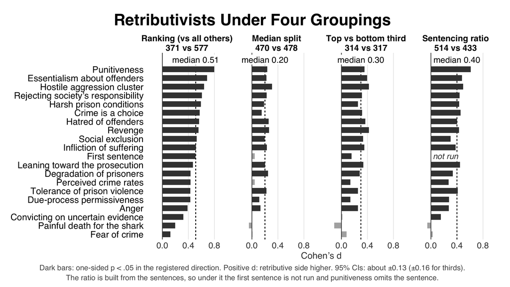

```r
keep_values("pt_06_four_groupings", rbind(
  data.frame(
    label = sprintf("%s: %s (d, %d vs %d)", GROUPINGS$name[match(g6$grouping, GROUPINGS$key)],
                    ifelse(g6$variable == "punit_parts5z", "Punitiveness without the sentence",
                           as.character(g6$label)), g6$n1, g6$n2),
    value = g6$d, lower = g6$lower, upper = g6$upper, n = g6$n1 + g6$n2),
  # The dashed lines: each grouping's median absolute d (n = contrasts run).
  data.frame(label = paste0(GROUPINGS$name, ": median absolute d (dashed line)"),
             value = med6$median_abs_d, lower = NA, upper = NA,
             n = as.integer(table(factor(g6$grouping, levels = GROUPINGS$key)))),
  # The caption's "about ±": each grouping's median 95% CI half-width, unrounded
  # (the caption rounds it to two decimals).
  data.frame(label = paste0(GROUPINGS$name, ": median 95% CI half-width of d (caption, rounded to ",
                            hw6$shown, ")"),
             value = hw6$median_half_width, lower = NA, upper = NA,
             n = as.integer(table(factor(g6$grouping, levels = GROUPINGS$key))))))
fig06
```

```r
# === SLIDE 7: ONE BAR PER GROUPING ===
# WHAT THIS CHUNK DOES: for each registered grouping, the median of the
# absolute d across the registered contrasts it could run (20; 19 under the
# sentencing ratio), labelled with how many of them reached one-sided p < .05.
# The median is taken over ABSOLUTE d, as 01's scorecard and Table S16 take it
# ("Median absolute d"); under the three alternative groupings the shark's pain
# is negative, so the sign matters in principle; here the two medians are the
# same, because the negative d's all fall below the middle of each list.
# READS: g6 (slide 6); PAPER_scorecard.
# WRITES: pt_07_groupings_summary; its values.
# MATCHES: Supplement S5 and Table S16 (median d 0.51, 0.20, 0.30, 0.40;
#          one-sided p < .05 on 20, 15, 17 and 17); General Discussion,
#          Methodological Limitations (0.51; 0.20 to 0.40).
summ <- do.call(rbind, lapply(GROUPINGS$key, function(g) {
  x <- g6[g6$grouping == g, ]
  data.frame(grouping = g, n_run = nrow(x), n_sig = sum(x$p_dir < .05),
             median_abs_d = median(abs(x$d)), stringsAsFactors = FALSE)
}))
# GUARDS: against 01's scorecard (the row set that counts punitiveness once,
# as the paper does), to 1e-8, and against the paper's printed values.
scc <- read_s2("PAPER_scorecard")
scc <- scc[scc$row_set == "Registered (H13 to H21), punitiveness once", ]
SC_RUN <- c(rank = "Ranking (primary)", med = "Median split", tert = "Tertiles",
            ratio = "Sentencing ratio grouping")
for (g in GROUPINGS$key) {
  s <- scc[scc$run == SC_RUN[[g]], ]; m <- summ[summ$grouping == g, ]
  stopifnot(nrow(s) == 1, s$n_rows == m$n_run, s$n_one_sided_p05 == m$n_sig)
  same(m$median_abs_d, s$median_abs_estimate, paste("slide 7: median |d|,", g))
}
paper_same(summ$median_abs_d, c(0.51, 0.20, 0.30, 0.40), 2, "Table S16: median |d|")
stopifnot(identical(summ$n_sig, c(20L, 15L, 17L, 17L)),
          identical(summ$n_run, c(20L, 20L, 20L, 19L)))
# NOT PLOTTED, GUARDED FOR THE SPEAKER. The ranking's median here (0.51) is
# against all 577 others. Against the 453 deterrence- or incapacitation-first
# (slide 5's comparison and the paper's main text, Part 3) the same 20
# contrasts give a median of 0.41, with 19 of 20 at one-sided p < .05 (fear of
# crime falls short). A speaker who shows slides 5 and 7 together may be
# asked why the numbers differ; this is the answer, checked against the paper.
REG20 <- c(names(CONTRASTS), "punit_parts6")
cq20 <- cq[cq$variable %in% REG20, ]
stopifnot(nrow(cq20) == 20, setequal(cq20$variable, REG20),
          sum(cq20$p_dir < .05) == 19, cq20$variable[cq20$p_dir >= .05] == "fear")
paper_same(median(abs(cq20$d)), 0.41, 2, "Part 3: median d against the 453, 0.41")
paper_same(range(cq20$d), c(0.06, 0.66), 2, "Part 3: d from 0.06 to 0.66")

summ$panel <- factor(GROUP_TITLE[summ$grouping], levels = unname(GROUP_TITLE))
# The ranking, the registered primary grouping, in the darkest gray; the three
# alternatives in one lighter gray. The x labels name every bar.
# DANGER: not the lightest data gray (G4) for the alternatives. On slide 6,
# which comes just before this one, G4 means "one-sided p >= .05", and 15 of
# 20, 17 of 20 and 17 of 19 of the alternatives' contrasts are p < .05; in G4
# these bars would read as "not significant". G3 keeps the two kinds of bar
# clearly apart (#1a1a1a against #737373), as on slide 5.
# The count inside each bar is white on both grays: white on G1 is about 17
# to 1, and on G3 about 4.7 to 1, enough for the 17-pt count text. (Black on
# G3 would be only about 4.4 to 1.)
summ$shade <- ifelse(summ$grouping == "rank", "primary", "alternative")
fig07 <- ggplot(summ, aes(x = panel, y = median_abs_d, fill = shade)) +
  geom_col(width = 0.6) +
  # The median above each bar ...
  geom_text(aes(y = median_abs_d + 0.012, label = fmt_d(median_abs_d)),
            vjust = 0, size = 8, fontface = "bold", colour = INK) +
  # ... and, inside it near the top, the count at one-sided p < .05, in white
  # on every bar (see the DANGER note above on the two grays).
  geom_text(aes(y = median_abs_d - 0.015,
                label = sprintf("%d of %d\nat p < .05", n_sig, n_run),
                colour = shade), vjust = 1, size = 6, lineheight = 0.95) +
  scale_fill_manual(values = c(primary = G1, alternative = G3), guide = "none") +
  scale_colour_manual(values = c(primary = "white", alternative = "white"), guide = "none") +
  scale_y_continuous(breaks = seq(0, 0.6, 0.1), labels = axis_d,
                     expand = expansion(mult = c(0, 0.05))) +
  coord_cartesian(ylim = c(0, 0.6), clip = "off") +
  labs(title = "Median Difference by Grouping", x = NULL, y = "Median Cohen’s d",
       # "Ranking: ... all 577 others" because the ranking's median here (0.51)
       # is against all others, the registered comparison; against the 453
       # deterrence- or incapacitation-first (slide 5, the paper's main text)
       # the median is 0.41.
       caption = cap("Bars: the median absolute Cohen’s d across the registered contrasts each grouping could run (20; 19 under the sentencing ratio).",
                     "Counts: contrasts reaching one-sided p < .05 in the registered direction. Ranking: retributivists vs all 577 others.")) +
  theme_vbar() +
  theme(axis.text.x = element_text(colour = INK, size = 19, lineheight = 0.95))
save_slide(fig07, "pt_07_groupings_summary")
```

```
## [1] TRUE
```

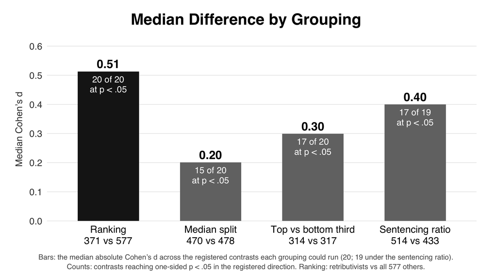

```r
keep_values("pt_07_groupings_summary", rbind(
  data.frame(label = paste0(GROUPINGS$name, ": median absolute d"),
             value = summ$median_abs_d, lower = NA, upper = NA, n = summ$n_run),
  data.frame(label = paste0(GROUPINGS$name, ": contrasts at one-sided p < .05"),
             value = summ$n_sig, lower = NA, upper = NA, n = summ$n_run)))
fig07
```

# 7. Slides 8 to 11 and the main line of the talk

The recommended main line of the talk is slides 8, 9, 10 and 6. Slides 8 to 10 tell the story of slides 1 to 5 more plainly; slide 11 is a backup for questions about whether revenge’s lead over just deserts depends on how punitiveness is measured.

```r
# === SLIDE 8: ENDORSING AND PUNISHING ===
# WHAT THIS CHUNK DOES: for revenge (four items), desert theory (five items)
# and the proportionality principle, two numbers side by side:
#   LEFT, "Endorse": the share of the 948 participants whose score is above the
#     neutral 4, with its exact (Clopper-Pearson) 95% interval (share_cp());
#   RIGHT, "Go with punishing": the score's correlation with punitiveness
#     (the paper's six components), with its Fisher 95% interval.
# Read across a row, the slide sets what participants endorse against what
# goes with punishing. The proportionality principle is endorsed by most
# (83.1%) and goes with punitiveness hardly at all (r = .038); revenge is
# endorsed by about half and goes with punitiveness as closely as desert
# theory does.
# READS: sc (section 3); assoc (slide 2) and parts (slide 3), whose r's are
#        already guarded against the exports; H4_shares.
# WRITES: pt_08_endorsing_punishing (PNG, PDF, Docs copy); its values.
# MATCHES: Results, Part 2: H4 ("Most participants, 83.1%, agreed with the
#          proportionality principle"), H10 (revenge r = .676, desert theory
#          .674) and H6 (the principle, r = .038). NEW AND DESCRIPTIVE, not in
#          the paper: the shares agreeing with revenge (50.4%) and with desert
#          theory (89.5%); each is guarded against its value computed
#          independently of this document.
#
# "AGREE" MEANS A MEAN ABOVE THE NEUTRAL 4, the paper's rule for endorsement
# (H4's shares, and H12's "mean exceeded 4, the scale midpoint"). A score of
# exactly 4 is neutral, not agreement.
# DANGER: ">= 4" in place of "> 4" would count the neutral as agreeing and
# raise every share; the principle's share would then differ from the
# paper's 83.1%, and the guard below would stop the knit.
ROWS8 <- c(revenge = "Revenge (four items)", desert_theory = "Desert theory (five items)",
           proportionality_principle = "Proportionality principle")
sh8 <- do.call(rbind, lapply(names(ROWS8), function(v)
  cbind(key = v, share_cp(sc[[v]] > 4), stringsAsFactors = FALSE)))
stopifnot(all(sh8$n == 948))

# GUARD: THE PRINCIPLE'S SHARE AGAINST THE EXPORT THAT GIVES IT. H4_shares
# counts the COMPLEMENT: the participants who do not endorse the principle
# (proportionality <= 4), 160 of 948. So the count endorsing must be 948 - 160,
# the share 1 minus the export's share, and the exact interval 1 minus the
# export's interval with its ends swapped (the Clopper-Pearson interval of
# (n - k) / n is exactly 1 minus that of k / n, reversed).
h4 <- read_s2("H4_shares")
h4p <- h4[grepl("^Do NOT endorse strict proportionality", h4$measure), ]
stopifnot(nrow(h4p) == 1, h4p$n == 948)
pp8 <- sh8[sh8$key == "proportionality_principle", ]
stopifnot(pp8$k == h4p$n - h4p$k, pp8$n == h4p$n)
same_each(c(pp8$share, pp8$lower, pp8$upper),
          c(1 - h4p$prop, 1 - h4p$ci_upper, 1 - h4p$ci_lower),
          "slide 8: principle's share against H4_shares",
          labels = c("share", "lower", "upper"))
paper_same(100 * pp8$share, 83.1, 1, "Part 2, H4: 83.1% agreed with the principle")
# GUARDS ON THE TWO NEW SHARES, against their values computed independently
# of this document (one decimal), and on the principle's interval.
paper_same(100 * unlist(sh8[sh8$key == "revenge", c("share", "lower", "upper")]),
           c(50.4, 47.2, 53.7), 1, "revenge: share agreeing 50.4% [47.2, 53.7] (new; computed independently)")
paper_same(100 * unlist(sh8[sh8$key == "desert_theory", c("share", "lower", "upper")]),
           c(89.5, 87.3, 91.3), 1, "desert theory: share agreeing 89.5% [87.3, 91.3] (new; computed independently)")
paper_same(100 * c(pp8$lower, pp8$upper), c(80.6, 85.5), 1,
           "principle: interval [80.6, 85.5]")

# THE CORRELATIONS, reused from slides 2 and 3 rather than recomputed, so the
# guards there (against PAPER_H10_cors and PAPER_H6, to 1e-8) cover them.
r8 <- rbind(assoc[assoc$key %in% c("revenge", "desert_theory"), c("key", "r", "lower", "upper", "n")],
            parts[parts$key == "proportionality_principle", c("key", "r", "lower", "upper", "n")])
stopifnot(identical(sort(r8$key), sort(names(ROWS8))), all(r8$n == 948))
paper_same(r8$r[r8$key == "revenge"], .676, 3, "slide 8: r(punitiveness, revenge) .676")
paper_same(r8$r[r8$key == "desert_theory"], .674, 3, "slide 8: r(punitiveness, desert theory) .674")
paper_same(r8$r[r8$key == "proportionality_principle"], .038, 3,
           "slide 8: r(punitiveness, principle) .038")

# ONE LONG TABLE FOR THE TWO PANELS. The left panel is in percent (0 to 100),
# the right in r; bar_facets() gives each panel its own axis (scales =
# "free_x"). txt is the printed value: shares to one decimal, as the paper
# prints 83.1%; r to three decimals, as slides 2 to 4 print it. tx places it
# just past the end of the interval, in each panel's own units (1.5 points of
# percent; .012 of r), and bar_facets() adds a space before the number, so
# it clears the interval's cap on any panel width.
# PANEL HEADERS in two lines: the panel's name, and under it what the
# panel's axis measures. The slide has no x-axis title, because the two
# panels measure different things; the second line of each header does that
# job. (On one line, "Go with punishing (r with punitiveness)" would run to
# the slide's right edge.)
P8 <- c(endorse = "Endorse\n(% agreeing)", punish = "Go with punishing\n(r with punitiveness)")
e8 <- data.frame(panel = P8[["endorse"]], key = sh8$key, value = 100 * sh8$share,
                 lower = 100 * sh8$lower, upper = 100 * sh8$upper, n = sh8$n,
                 stringsAsFactors = FALSE)
e8$txt <- sprintf("%.1f%%", e8$value); e8$tx <- e8$upper + 1.5
g8 <- data.frame(panel = P8[["punish"]], key = r8$key, value = r8$r,
                 lower = r8$lower, upper = r8$upper, n = r8$n, stringsAsFactors = FALSE)
g8$txt <- fmt_r(g8$value, digits = 3); g8$tx <- pmax(g8$upper, 0) + 0.012
d8 <- rbind(e8, g8)
d8$panel <- factor(d8$panel, levels = unname(P8))
# Revenge on top: rows are drawn bottom-up, so the levels are reversed.
d8$label <- factor(ROWS8[d8$key], levels = rev(unname(ROWS8)))
# FILL: revenge in G1 (with the white knock-out inside it); desert theory and
# the principle in the mid gray G3, not the light G4, which washes out on a
# projector. On G3 a black interval reads (about 4.4 to 1), so it stays black.
d8$shade <- ifelse(d8$key == "revenge", "Revenge", "Other")
FILLS8 <- c(Revenge = G1, Other = G3)
# EACH PANEL'S AXIS. The percent axis runs 0 to 100%, the whole scale, so a
# share is read against all participants. The r axis runs from -.06, so that
# the principle's interval, which dips below zero (-.026), is drawn whole, to
# .84, which leaves room for the printed .676. The breaks and labels are
# functions because the two panels need different ones: ggplot2 calls them
# once per panel, with that panel's limits and breaks.
lims8 <- data.frame(panel = factor(rep(unname(P8), each = 2), levels = unname(P8)),
                    x = c(0, 100, -0.06, 0.84))
brk8 <- function(lim) if (lim[2] > 2) seq(0, 100, 25) else seq(0, 0.8, 0.2)
lab8 <- function(x) if (any(x > 2, na.rm = TRUE)) ifelse(is.na(x), NA, paste0(x, "%")) else axis_r(x)

fig08 <- bar_facets(d8, FILLS8, lims8, breaks = brk8, labels = lab8, xlab = NULL,
                    scales = "free_x") +
  # The printed 89.5% runs past the 100% line into the space between the
  # panels; 3.4 lines (about 0.95 inches) keeps it clear of the right panel.
  theme(panel.spacing.x = unit(3.4, "lines"),
        axis.text.y = element_text(colour = INK, size = 20),
        strip.text = element_text(size = 20, face = "bold", colour = INK,
                                  lineheight = 0.95, margin = margin(b = 10))) +
  # THE CAPTION: N; what "agree" means; which shares are new; and what
  # punitiveness is. Its components are grouped rather than listed ("two
  # punitive attitudes" are support for more punishment and rejection of
  # parsimony; "three policies" are three-strikes laws, life without parole
  # and the death penalty), because the full list pushes the caption to three
  # lines. Slides 2 and 9 use the same words; the six are listed in full
  # where punitiveness is read in (PUNITIVENESS, `scores` chunk).
  labs(title = "Endorsing and Punishing",
       caption = cap("N = 948. Agree: a mean above the neutral 4. The revenge and desert-theory shares are descriptive and not in the paper.",
                     "Punitiveness: six standardized components (two punitive attitudes, three policies, the first sentence). Error bars: 95% CIs."))
save_slide(fig08, "pt_08_endorsing_punishing")
```

```
## [1] TRUE
```

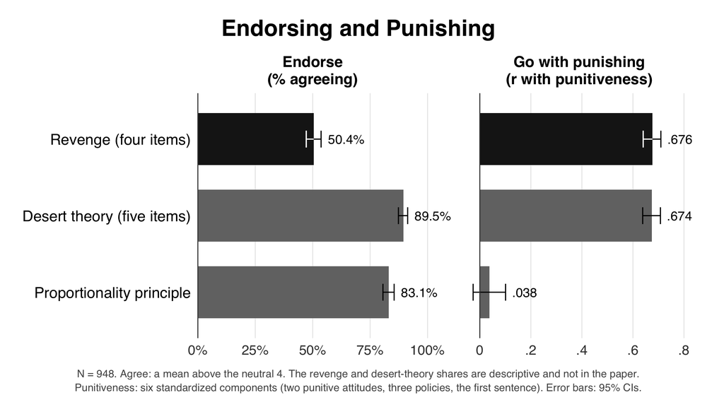

```r
keep_values("pt_08_endorsing_punishing", rbind(
  data.frame(label = paste("Agree (mean above 4), % of all, exact 95% CI:", ROWS8[e8$key]),
             value = e8$value, lower = e8$lower, upper = e8$upper, n = e8$n),
  data.frame(label = paste("r with punitiveness, whole sample:", ROWS8[g8$key]),
             value = g8$value, lower = g8$lower, upper = g8$upper, n = g8$n)))
fig08
```

```r
# === SLIDE 9: REVENGE, DESERT, AND PUNITIVENESS, IN BOTH SAMPLES ===
# WHAT THIS CHUNK DOES: slides 2 and 4 merged into one slide of two panels,
# the whole sample and the retributivists, on one shared r axis, with the same
# four rows in the same order: revenge, desert theory, just deserts,
# severity-deserts. Nothing is recomputed: the values are slide 2's `assoc`
# and slide 4's `assoc4`, with every guard those chunks ran.
# READS: assoc (slide 2), assoc4 (slide 4).
# WRITES: pt_09_revenge_desert_both; its values.
# MATCHES: as slides 2 and 4: Results, Part 2, H10 (revenge .676, desert
#          theory .674, just deserts .432) and Part 3, H11 (revenge .570,
#          desert theory .545, just deserts .157). Severity-deserts (.734,
#          .558) is new and exploratory.
#
# WHO THE RETRIBUTIVISTS ARE, said in the right panel's header. Slide 9 is
# the first slide of the talk's main line (8, 9, 10, 6) that names the
# retributivists, and slides 10 and 6 name them only by their number, so the
# definition goes here, on the slide, rather than being left to the speaker:
# the participants who ranked retribution ("Criminals deserve to be
# punished") first of the four goals of punishment.
P9 <- c(whole  = sprintf("Whole sample (N = %d)", nrow(sc)),
        retrib = sprintf("Retributivists (n = %d)\nranked retribution first", nrow(rt)))
stopifnot(P9[["whole"]] == "Whole sample (N = 948)",
          P9[["retrib"]] == "Retributivists (n = 371)\nranked retribution first")
pick9 <- function(a, panel) data.frame(panel = panel, key = a$key, value = a$r,
                                       lower = a$lower, upper = a$upper, n = a$n,
                                       stringsAsFactors = FALSE)
d9 <- rbind(pick9(assoc, P9[["whole"]]), pick9(assoc4, P9[["retrib"]]))
# GUARD: every row is the value slides 2 and 4 plot, in the right panel, to
# 1e-8 (a slip that swapped the two data frames would be caught here).
for (v in names(SCORES)) {
  same_each(unlist(d9[d9$panel == P9[["whole"]] & d9$key == v, c("value", "lower", "upper")]),
            unlist(assoc[assoc$key == v, c("r", "lower", "upper")]),
            paste("slide 9, whole sample:", v), labels = c("r", "lower", "upper"))
  same_each(unlist(d9[d9$panel == P9[["retrib"]] & d9$key == v, c("value", "lower", "upper")]),
            unlist(assoc4[assoc4$key == v, c("r", "lower", "upper")]),
            paste("slide 9, retributivists:", v), labels = c("r", "lower", "upper"))
}
stopifnot(nrow(d9) == 8, all(d9$n[d9$panel == P9[["whole"]]] == 948),
          all(d9$n[d9$panel == P9[["retrib"]]] == 371))
paper_same(d9$value, c(.676, .674, .432, .734, .570, .545, .157, .558), 3,
           "slide 9: the eight r's (paper; severity-deserts computed independently)")
d9$panel <- factor(d9$panel, levels = unname(P9))
d9$label <- factor(SCORES[d9$key], levels = rev(unname(SCORES)))
# FILL, as on slides 2 and 4: revenge G1 (white knock-out inside), desert
# theory and just deserts G3, severity-deserts WHITE with a black outline and
# a black interval (FAMILY_FILLS, section 3).
d9$shade <- unname(FAMILY[d9$key])
d9$txt <- fmt_r(d9$value, digits = 3); d9$tx <- pmax(d9$upper, 0) + 0.012

fig09 <- bar_facets(d9, FAMILY_FILLS, lims = data.frame(x = c(0, 0.84)),
                    breaks = seq(0, 0.8, 0.2), labels = axis_r,
                    xlab = "Correlation with punitiveness (r)") +
  # The right panel's header is two lines (its name, then who the
  # retributivists are); the whole-sample header is one. vjust = 0 sets each
  # header on the bottom of its strip, so both headers end the same distance
  # above their bars and the right header's extra line rises above the left
  # one, rather than the one-line header floating halfway up its strip.
  theme(panel.spacing.x = unit(3, "lines"),
        strip.text = element_text(size = 20, face = "bold", colour = INK, vjust = 0,
                                  lineheight = 0.95, margin = margin(b = 10))) +
  # The caption names the one new score by its bar, says what it is and that
  # it is new and exploratory, and defines punitiveness, whose components are
  # grouped as on slide 8 so the caption keeps to two lines.
  labs(title = "Revenge, Desert, and Punitiveness",
       caption = cap("Severity-deserts (white bar) averages desert theory and the severity index; it is new and exploratory. Error bars: 95% CIs.",
                     "Punitiveness: six standardized components (two punitive attitudes, three policies, the first sentence)."))
save_slide(fig09, "pt_09_revenge_desert_both")
```

```
## [1] TRUE
```

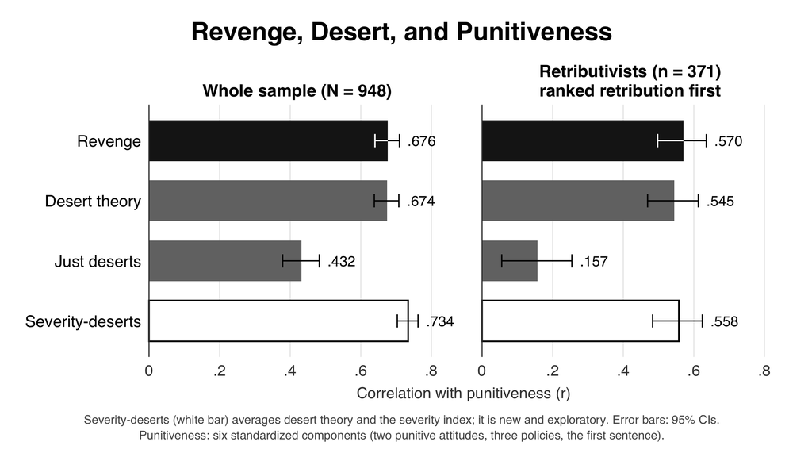

```r
keep_values("pt_09_revenge_desert_both", data.frame(
  label = paste0("r with punitiveness, ", ifelse(d9$panel == P9[["whole"]], "whole sample", "retributivists"),
                 ": ", SCORES[d9$key]),
  value = d9$value, lower = d9$lower, upper = d9$upper, n = d9$n))
fig09
```

```r
# === SLIDE 10: TWO MODELS OF AGENCY, IN SHARES ===
# WHAT THIS CHUNK DOES: slide 5 told in shares. For each of the seven measures
# on slide 5, two bars: the percentage of retributivists (371) who endorse it,
# that is, whose mean on it is above 4, the scale midpoint, and the same
# percentage among the participants who ranked deterrence or incapacitation
# first (453). The measures sit under the
# same two models of agency as on slide 5, with the same prediction in each
# group's header:
#   AGENCY AS BLAMEWORTHINESS (predicts retributivists higher): essentialism
#     about offenders, crime is a choice, rejecting society's responsibility;
#   AGENCY AS BENEVOLENCE (predicts retributivists no higher): hatred of
#     offenders, degradation of prisoners, infliction of suffering, harsh
#     prison conditions.
# Each difference between the two groups is also tested (share_diff():
# Newcombe's hybrid score interval for the difference, and the two-sample
# test of equal proportions without continuity correction). The tests are in
# the values table, not on the slide.
# READS: d (the measures), sc (the two groups); AGENCY and MODELS (slide 5);
#        H12_retributivist_endorsement and PAPER_H12_shares_vs_deter_incap.
# WRITES: pt_10_agency_shares; its values (each share with its exact 95%
#         interval; each difference in percentage points with its 95%
#         interval; each difference's two-sided p).
# MATCHES: Results, Part 3, H12 and Figure 11: the four hostility shares
#          (hatred 56.3% [51.1, 61.4] among retributivists; 36.2% among the
#          deterrence- or incapacitation-first), guarded exactly against the
#          exports behind Figure 11. NEW, not in the paper: the three
#          blameworthiness shares (guarded against their values computed
#          independently of this document) and all seven tests of the
#          differences.
# WHAT IS REGISTERED: the seven contrasts are preregistered as differences
# in means (H13, H16, H17, H19; the d's of slide 5). Among retributivists,
# the four hostility shares are H12's. The comparison of shares between the
# two groups is not registered (Table S22 note: the comparison groups'
# shares "were not registered, are descriptive"), nor is this comparison
# group, which leaves out the 124 who ranked rehabilitation first, nor the
# grouping into two models.
#
# "ABOVE 4" is the paper's rule for endorsing an attitude (Figure 11: "the
# percentage of participants whose mean exceeded 4, the scale midpoint").
# The slide says "endorsing" and "the scale midpoint", never "agreeing" or
# "the neutral 4": hatred is rated from "not at all" to "very much so", an
# intensity scale with no agree or neutral point (Table S22 note).
# DANGER: ">= 4" would count the midpoint as endorsing and break the guard
# against Figure 11's exports.
in_R  <- which(sc$grp_vs_deter_incap == "Retributivist")
in_DI <- which(sc$grp_vs_deter_incap == "Deterrence or incapacitation first")
stopifnot(length(in_R) == 371, length(in_DI) == 453,
          identical(in_R, which(sc$retributivist == 1)))
sh10 <- do.call(rbind, lapply(seq_len(nrow(AGENCY)), function(i) {
  x <- d[[AGENCY$variable[i]]]
  # Every measure was answered by everyone in the two groups; a missing score
  # would silently drop out of a share, so the knit stops instead.
  stopifnot(!anyNA(x[c(in_R, in_DI)]))
  a <- share_cp(x[in_R] > 4); b <- share_cp(x[in_DI] > 4)
  df <- share_diff(a$k, a$n, b$k, b$n)
  data.frame(variable = AGENCY$variable[i], label = AGENCY$label[i], model = AGENCY$model[i],
             k1 = a$k, n1 = a$n, s1 = a$share, l1 = a$lower, u1 = a$upper,
             k2 = b$k, n2 = b$n, s2 = b$share, l2 = b$lower, u2 = b$upper,
             diff = df$diff, diff_lower = df$lower, diff_upper = df$upper,
             p_two = df$p_two, stringsAsFactors = FALSE)
}))

# GUARDS: THE FOUR HOSTILITY SHARES ARE THE PAPER'S (Figure 11), EXACTLY. The
# counts and group sizes must be identical, and each share and both ends of
# its exact interval must agree to 1e-8 with the export: retributivists from
# H12_retributivist_endorsement (H12), the deterrence- or incapacitation-first
# from PAPER_H12_shares_vs_deter_incap (the paper's descriptive comparison).
H12_ATT <- c(hatred = "Hatred toward offenders", degradation = "Degradation of prisoners",
             suffering = "Infliction of suffering", harsh = "Harsh prison conditions")
h12r <- read_s2("H12_retributivist_endorsement")
h12d <- read_s2("PAPER_H12_shares_vs_deter_incap")
for (v in names(H12_ATT)) {
  s  <- sh10[sh10$variable == v, ]
  er <- h12r[h12r$attitude == H12_ATT[[v]], ]
  ed <- h12d[h12d$attitude == H12_ATT[[v]], ]
  stopifnot(nrow(s) == 1, nrow(er) == 1, nrow(ed) == 1,
            s$k1 == er$k_endorsing, s$n1 == er$n, s$k2 == ed$k_endorsing, s$n2 == ed$n)
  same_each(c(s$s1, s$l1, s$u1, s$s2, s$l2, s$u2),
            c(er$share, er$share_ci_lower, er$share_ci_upper,
              ed$share, ed$share_ci_lower, ed$share_ci_upper),
            paste("slide 10 against Figure 11's exports:", v),
            labels = c("retributivists", "lower", "upper", "deterrence/incap.", "lower", "upper"))
}
# ... and against the paper's printed values (Part 3, H12).
paper_same(100 * unlist(sh10[sh10$variable == "hatred", c("s1", "l1", "u1")]),
           c(56.3, 51.1, 61.4), 1, "H12: hatred 56.3% [51.1, 61.4] among retributivists")
paper_same(100 * sh10$s2[sh10$variable == "hatred"], 36.2, 1,
           "H12: hatred 36.2% among the deterrence- or incapacitation-first")
# GUARDS ON ALL FOURTEEN SHARES against their values computed independently
# of this document, one decimal, in AGENCY's order.
paper_same(100 * sh10$s1, c(53.4, 74.7, 39.9, 56.3, 39.6, 46.6, 34.0), 1,
           "slide 10: retributivists' shares (computed independently)")
paper_same(100 * sh10$s2, c(33.3, 57.4, 21.9, 36.2, 23.8, 32.7, 16.6), 1,
           "slide 10: deterrence- or incapacitation-first shares (computed independently)")
# Every difference is positive: a larger share of retributivists endorses
# each of the seven, as the d's on slide 5 say (all one-sided p < .001 there).
stopifnot(all(sh10$diff > 0), all(sh10$diff_lower > 0))
print(data.frame(measure = sh10$label, R = round(100 * sh10$s1, 1), DI = round(100 * sh10$s2, 1),
                 diff = round(100 * sh10$diff, 1), lower = round(100 * sh10$diff_lower, 1),
                 upper = round(100 * sh10$diff_upper, 1), p_two = signif(sh10$p_two, 2)))
```

```
##                              measure    R   DI diff lower upper   p_two
## 1       Essentialism about offenders 53.4 33.3 20.0  13.3  26.6 7.0e-09
## 2                  Crime is a choice 74.7 57.4 17.3  10.8  23.5 2.3e-07
## 3 Rejecting society’s responsibility 39.9 21.9 18.0  11.7  24.2 1.9e-08
## 4                Hatred of offenders 56.3 36.2 20.1  13.3  26.7 7.7e-09
## 5           Degradation of prisoners 39.6 23.8 15.8   9.4  22.0 1.1e-06
## 6            Infliction of suffering 46.6 32.7 14.0   7.3  20.5 4.3e-05
## 7            Harsh prison conditions 34.0 16.6 17.4  11.5  23.3 7.1e-09
```

```r
# THE PLOT DATA: one row per bar. The legend names both groups with their
# sizes, read from the data.
GRP10 <- c(R  = sprintf("Retributivists (n = %d)", length(in_R)),
           DI = sprintf("Deterrence or incapacitation first (n = %d)", length(in_DI)))
long10 <- rbind(data.frame(label = sh10$label, model = sh10$model, group = "R",
                           share = 100 * sh10$s1, stringsAsFactors = FALSE),
                data.frame(label = sh10$label, model = sh10$model, group = "DI",
                           share = 100 * sh10$s2, stringsAsFactors = FALSE))
# DODGE ORDER. Dodged bars on a horizontal chart are placed bottom to top in
# the order of the group's levels, so "DI" comes first to put the
# retributivists' bar on TOP of each pair; the legend's order is set
# separately (breaks = below), retributivists first.
long10$group <- factor(long10$group, levels = c("DI", "R"))
long10$label <- factor(long10$label, levels = rev(AGENCY$label))
long10$model <- factor(long10$model, levels = unname(MODELS))
# WHERE EACH PRINTED SHARE STARTS: 1.2 points past the end of its bar.
# A LABEL ACROSS THE 50% LINE. A share from about 43% to just under 49% puts
# its printed value across the dashed line (here the retributivists' 47% for
# infliction of suffering), and the line would run through the number. Such a
# label gets a white box, just big enough to hide the line under the text
# (geom_label below). The label is not moved past the line instead, because
# a "47%" printed to the right of the 50% line looks, at a glance, like a
# share above half.
# LABEL_W10 is the width of a three-character label ("47%") at the 17-pt size
# below, in percentage points of this axis: the text measures about 0.46
# inches in the PNG, on an axis about 7.8 inches wide for 100 points, which is
# 5.8 points; 6 allows for the white box's padding. Only labels starting
# between 44 and 50 points are boxed, so every share from about 43% to just
# under 49% is covered.
# DANGER: the axis width depends on the side margins (theme(plot.margin) in
# the plot below). Widening them narrows the axis and makes each label span
# more points; re-measure the label and the axis and reset this value.
LABEL_W10 <- 6
long10$tx <- long10$share + 1.2
long10$straddle <- long10$tx < 50 & long10$tx + LABEL_W10 > 50
# GUARD: the white box is safe only where no other bar reaches it. Each pair
# of bars is retributivists on top, the other group below; the box of a
# retributivists' label sits between that measure's other bar (below) and the
# other group's bar of the measure above (drawn next up). Both must end
# before the label starts, or the box would cut a notch out of a bar; then
# the knit stops and the label needs another fix. A box on the LOWER bar of a
# pair would always cut into the retributivists' bar above it, which is
# longer on every measure, so only retributivists' labels may take a box.
box10 <- long10[long10$straddle, ]
LEVELS10 <- levels(long10$label)
for (i in seq_len(nrow(box10))) {
  m <- as.character(box10$label[i])
  stopifnot(box10$group[i] == "R")
  own_other <- long10$share[long10$label == m & long10$group == "DI"]
  above <- if (match(m, LEVELS10) < length(LEVELS10)) LEVELS10[match(m, LEVELS10) + 1] else NA
  above_other <- if (!is.na(above) &&
                     long10$model[long10$label == above][1] == box10$model[i])
    long10$share[long10$label == above & long10$group == "DI"] else -Inf
  stopifnot(own_other < box10$tx[i], above_other < box10$tx[i])
}
cat("Slide 10: labels boxed over the 50% line:",
    paste(box10$label, box10$group, collapse = "; "), "\n")
```

```
## Slide 10: labels boxed over the 50% line: Infliction of suffering R
```

```r
fig10 <- ggplot(long10, aes(x = share, y = label, fill = group)) +
  # THE 50% LINE, dashed, drawn FIRST so it sits behind the bars: it shows in
  # the gaps between bars and past their ends, where it lets the eye judge
  # which shares pass half, and it never runs over a bar or a printed value's
  # background (a line over the G3 bars, #737373, would vanish into them).
  geom_vline(xintercept = 50, linetype = "dashed", colour = MUTED, linewidth = 0.8) +
  geom_col(position = position_dodge(width = 0.8), width = 0.76) +
  # WHOLE PERCENTS at the end of each bar; the values table keeps the
  # decimals and the intervals. No interval is drawn: with two bars per
  # measure, fourteen whiskers and fourteen labels would crowd the slide, and
  # the tested quantity is the difference, which is in the values table.
  # Labels clear of the 50% line are plain text; a label across it (see the
  # guard above) is the same text in a white box with no border, drawn over
  # the line. The plain-text layer keeps EVERY row and prints "" for a boxed
  # one: position_dodge() places each bar's text by the pair it belongs to,
  # and a row dropped from the layer would leave its partner alone, centred
  # on the measure's row, on top of the other bar.
  # The boxed labels are placed by hand, for the same reason: with a dodge
  # width of 0.8 and two groups, the retributivists' bar is centred 0.2 above
  # the row.
  # DANGER: the 0.2 is tied to position_dodge(width = 0.8); change both
  # together.
  geom_text(aes(x = tx, label = ifelse(straddle, "", sprintf("%.0f%%", share)), group = group),
            position = position_dodge(width = 0.8), hjust = 0, size = 6, colour = INK) +
  geom_label(data = function(k) k[k$straddle, ],
             aes(x = tx, label = sprintf("%.0f%%", share)), fill = "white",
             position = position_nudge(y = 0.2), hjust = 0, size = 6, colour = INK,
             label.size = 0, label.padding = unit(0.08, "lines"),
             label.r = unit(0, "lines")) +
  geom_vline(xintercept = 0, colour = INK2, linewidth = 0.6) +
  # ONE PANEL PER MODEL, stacked, each as tall as its rows need, so the bars
  # are equally thick in both, as on slide 5.
  facet_wrap(~ model, ncol = 1, scales = "free_y", space = "free_y") +
  scale_fill_manual(values = c(R = G1, DI = G3), breaks = c("R", "DI"), labels = GRP10) +
  # The axis runs 0 to 100%, the whole of each group, with no padding, so the
  # bars start at the zero line.
  scale_x_continuous(breaks = seq(0, 100, 25), labels = function(x) paste0(x, "%"),
                     expand = expansion(0)) +
  coord_cartesian(xlim = c(0, 100), clip = "off") +
  # "Share endorsing", as the paper's Figure 11 has it ("Participants
  # endorsing"); see "ABOVE 4" above for why not "agreeing".
  labs(title = "Two Models of Agency", x = "Share endorsing", y = NULL,
       # THE CAPTION, one line each:
       #   1. What a share is, in the paper's words (a mean above 4, the scale
       #      midpoint), and which shares are the paper's and which are new,
       #      named by the words in the two group headers, "benevolence" and
       #      "blameworthiness", so each can be matched to its panel.
       #   2. What was and was not preregistered. The seven contrasts were, as
       #      differences in means against ALL 577 other participants (the
       #      registered comparison; H13, H16, H17, H19). Three things on this
       #      slide were not: the comparison group (deterrence- or
       #      incapacitation-first only, the paper's stricter main-text
       #      comparison), the shares (Table S22 note), and the two-model
       #      grouping. Saying only "the seven contrasts are preregistered"
       #      would invite the reading that the share gaps drawn here are the
       #      registered tests.
       #   DANGER: this line names H13, H16, H17 and H19; the guard on slide 5
       #   (`ag`) is what ties those names to the export.
       #   Both lines are kept to about 125 characters, so that, like every
       #   other caption, they end at least 0.8 inches from the slide's edges.
       caption = cap("Share: percentage with a mean above 4, the scale midpoint. Benevolence shares are the paper’s (Figure 11); blameworthiness, new.",
                     "Preregistered as mean differences vs all 577 others (H13, H16, H17, H19); not this comparison group, the shares, or the grouping.")) +
  theme_hbar() +
  # SIDE MARGINS 24 pt wider than theme_slide()'s on both sides (54 and 64 pt
  # against 30 and 40). The axis ends at 100%, so the "100%" tick label is
  # centred on the panel's right edge and half of it sticks out; with the
  # usual 40 pt it ended a quarter of an inch from the slide's edge. The extra
  # room is added on BOTH sides so the title, legend and caption, which are
  # centred between the margins, stay centred where they are on every other
  # slide; widening the right margin alone would shift all three to the left.
  theme(plot.margin = margin(26, 64, 18, 54)) +
  theme(strip.text = element_text(size = 20, face = "bold", colour = INK, hjust = 0,
                                  margin = margin(t = 6, b = 8)),
        panel.spacing.y = unit(1.2, "lines"),
        # The legend centred on the slide, under the title, not over the panel.
        legend.location = "plot",
        legend.text = element_text(size = 19, colour = INK),
        legend.key.spacing.x = unit(18, "pt"),
        legend.margin = margin(0, 0, 4, 0))
save_slide(fig10, "pt_10_agency_shares")
```

```
## [1] TRUE
```

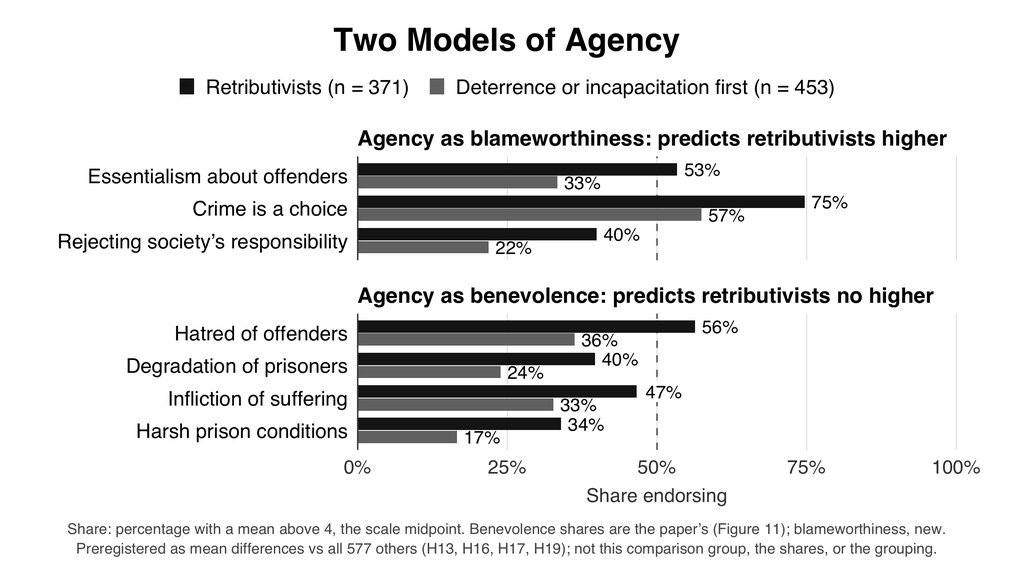

```r
# THE VALUES TABLE: each share (in percent) with its exact 95% interval; each
# difference (retributivists minus the deterrence- or incapacitation-first, in
# percentage points) with its Newcombe hybrid score 95% interval; and each
# difference's two-sided p (two-sample test of equal proportions, no
# continuity correction), in `value`, its interval columns left empty.
short10 <- sub(":.*", "", sh10$model)
keep_values("pt_10_agency_shares", rbind(
  data.frame(label = paste0(short10, ": ", sh10$label, ", % endorsing (mean > 4), retributivists, exact 95% CI"),
             value = 100 * sh10$s1, lower = 100 * sh10$l1, upper = 100 * sh10$u1, n = sh10$n1),
  data.frame(label = paste0(short10, ": ", sh10$label,
                            ", % endorsing (mean > 4), deterrence or incapacitation first, exact 95% CI"),
             value = 100 * sh10$s2, lower = 100 * sh10$l2, upper = 100 * sh10$u2, n = sh10$n2),
  data.frame(label = paste0(short10, ": ", sh10$label,
                            ", difference in percentage points (retributivists minus deterrence/incapacitation first), Newcombe hybrid score 95% CI"),
             value = 100 * sh10$diff, lower = 100 * sh10$diff_lower, upper = 100 * sh10$diff_upper,
             n = sh10$n1 + sh10$n2),
  data.frame(label = paste0(short10, ": ", sh10$label,
                            ", difference, two-sided p (two-sample test of proportions, no continuity correction)"),
             value = sh10$p_two, lower = NA, upper = NA, n = sh10$n1 + sh10$n2)))
fig10
```

```r
# === SLIDE 11 (BACKUP): REVENGE AND DESERT, THREE WAYS ===
# WHAT THIS CHUNK DOES: the correlations of five scores with three outcomes,
# as three panels side by side, with 95% intervals:
#   OUTCOMES (panels):
#     1. Punitiveness, the paper's six components;
#     2. Policy and sentence only: the mean of four of those six standardized
#        components, three-strikes laws, life without parole, the death
#        penalty and the first sentence. It leaves out support for more
#        punishment and rejection of parsimony, the two attitude components
#        whose wording is closest to the predictors (revenge's fourth item
#        asks for "punishing them more severely");
#     3. First sentence only: Sentence1_z, the first sentence standardized
#        within vignette.
#   SCORES (rows): revenge (four items), revenge on Study 1's three items
#     (revenge_1 to _3, which leave out the fourth, harsher-punishment item),
#     desert theory, just deserts, severity-deserts.
# The slide answers the question whether revenge's lead over just deserts,
# and its tie with desert theory, depend on the attitude components of
# punitiveness. The tests are written to the tests table: in each panel,
# four-item revenge against desert theory, just deserts and severity-deserts
# (Steiger's Z, Zou's interval, two-sided).
# READS: d (the components, the revenge items, Sentence1_z); sc; ps (the
#        paper's punitiveness scores, for the guards); assoc (slide 2);
#        tests_a and TESTS (the tests chunk); PAPER_H10 (three-item revenge).
# WRITES: pt_11_three_outcomes; its values; six rows added to the tests table.
# MATCHES: in the first panel, the paper's revenge .676, desert theory .674
#          and just deserts .432 (Results, Part 2, H10), and revenge on
#          Study 1's three items, .549 (Supplement, Table S7, "three shared
#          items"). EVERYTHING ELSE IS NEW AND EXPLORATORY: severity-deserts,
#          and every correlation and test in the second and third panels.
#          Each is guarded against its value computed independently of this
#          document.
#
# THE SIX COMPONENTS, BUILT AS 01 BUILDS THEM (section 7.4, p5_parts and
# punit_parts6). Each component is the mean of its items, already
# reverse-coded so that high means more punitive; each is then standardized
# across the 948 and the six are averaged (01's zmean()). 01 applies its
# at-least-half rule to the two-item components (a mean of those who answered
# at least one of the two); every item was answered, so the rule changes
# nothing here, and the guard below says so.
# DANGER: the parsimony component must use parsimony_1_R and parsimony_2_R,
# the reversed items. The raw items would turn one component upside down, and
# the guard against the paper's punitiveness below would fail.
PART_ITEMS <- list(punish_more        = c("punishmore_1_R", "punishmore_2"),
                   parsimony_rejected = c("parsimony_1_R", "parsimony_2_R"),
                   three_strikes      = c("threestrikes_1", "threestrikes_2"),
                   life_without_parole = "LWOP",
                   death_penalty      = "deathpenalty",
                   first_sentence     = "Sentence1_z")
stopifnot(!anyNA(d[, unlist(PART_ITEMS)]))
parts11 <- as.data.frame(lapply(PART_ITEMS, function(cols) rowMeans(d[, cols, drop = FALSE])))
# STANDARDIZE EACH COMPONENT across the whole sample: scale() on the six
# columns at once standardizes each column on its own, exactly as zmean()
# does inside 01.
Z11 <- as.data.frame(scale(parts11))
# GUARDS: the six standardized components averaged reproduce the paper's
# punitiveness exactly (PAPER_person_scores$punit_six), and the five without
# the sentence reproduce the paper's five-component score (punit_five_z).
# Either failing would mean a component is built differently from 01's, and
# the policy-and-sentence score below could not be read as a part of the
# paper's punitiveness.
same(rowMeans(Z11), ps$punit_six, "slide 11: six components rebuilt = the paper's punitiveness")
same(rowMeans(Z11[, 1:5]), ps$punit_five_z,
     "slide 11: five components rebuilt = the paper's five-component score")
# POLICY AND SENTENCE ONLY (NEW, exploratory): the four behavioural components,
# each standardized as above, averaged. The two attitude components (support
# for more punishment, rejection of parsimony) are left out.
POLICY_PARTS <- c("three_strikes", "life_without_parole", "death_penalty", "first_sentence")
sc$punit_policy <- rowMeans(Z11[, POLICY_PARTS])
# FIRST SENTENCE ONLY: the within-vignette z-score as the data carry it (a
# correlation does not change when the sentence is restandardized).
sc$sentence1 <- d$Sentence1_z

OUT11 <- c(six      = "Punitiveness\n(six components)",
           policy   = "Policy and sentence only\n(four components)",
           sentence = "First sentence only")
OUT_COL <- c(six = "punit", policy = "punit_policy", sentence = "sentence1")
# ROW LABELS. Three-item revenge is labelled by its source, Study 1's three
# items (Table S7's "three shared items"). The Supplement also reports a
# three-item scoring without the father item (Table S12), which tracks
# punitiveness far more closely, and this slide's point is how much of
# revenge's lead rests on the fourth, harsher-punishment item, so the label
# must say which three items these are.
S11 <- c(revenge = "Revenge (four items)", revenge3 = "Revenge (Study 1’s three items)",
         desert_theory = "Desert theory", just_deserts = "Just deserts",
         severity_deserts = "Severity-deserts")
r11 <- do.call(rbind, lapply(names(OUT11), function(o)
  do.call(rbind, lapply(names(S11), function(s)
    cbind(outcome = o, key = s, cor_ci(sc[[OUT_COL[[o]]]], sc[[s]]),
          stringsAsFactors = FALSE)))))
stopifnot(nrow(r11) == 15, all(r11$n == 948))
r11_at <- function(o, s) r11[r11$outcome == o & r11$key == s, ]

# GUARDS, FIRST PANEL: the four scores slide 2 plots are slide 2's values
# (themselves guarded against the exports), to 1e-8; three-item revenge is the
# r in PAPER_H10's three-item row (r_jk), to 1e-8, and the Supplement's .549.
for (s in names(SCORES))
  same_each(unlist(r11_at("six", s)[, c("r", "lower", "upper")]),
            unlist(assoc[assoc$key == s, c("r", "lower", "upper")]),
            paste("slide 11, punitiveness:", s), labels = c("r", "lower", "upper"))
h10_3 <- h10[h10$punitiveness == SIX & grepl("^one-sided.*three-item", h10$sidedness), ]
stopifnot(nrow(h10_3) == 1)
same(r11_at("six", "revenge3")$r, h10_3$r_jk, "slide 11: three-item revenge r (PAPER_H10)")
paper_same(r11_at("six", "revenge3")$r, .549, 3, "Table S7: three-item revenge .549")
# GUARDS, ALL FIFTEEN, against their values computed independently of this
# document, three decimals, in the order revenge four items, Study 1's three
# items, desert theory, just deserts, severity-deserts.
paper_same(r11$r[r11$outcome == "six"],      c(.676, .549, .674, .432, .734), 3, "slide 11: punitiveness r's")
paper_same(r11$r[r11$outcome == "policy"],   c(.628, .521, .621, .421, .659), 3, "slide 11: policy and sentence r's")
paper_same(r11$r[r11$outcome == "sentence"], c(.326, .268, .389, .299, .419), 3, "slide 11: first sentence r's")

# THE TESTS. In each panel, four-item revenge against desert theory, just
# deserts and severity-deserts: dep_cor() (Steiger's Z, Zou's interval), as
# for slides 2 and 4. In the first panel these three tests are ALREADY in the
# tests table (family A, whole sample, four-item revenge), with their
# registered-direction p's and guards; they are recomputed here only to show
# that they are the same tests, and only the six tests of the other two panels
# are added to the table.
RIV11 <- c("desert_theory", "just_deserts", "severity_deserts")
t11 <- do.call(rbind, lapply(names(OUT11), function(o)
  do.call(rbind, lapply(RIV11, function(h)
    cbind(outcome = o, rival_key = h,
          dep_cor(sc[[OUT_COL[[o]]]], sc$revenge, sc[[h]]), stringsAsFactors = FALSE)))))
t11_at <- function(o, h) t11[t11$outcome == o & t11$rival_key == h, ]
for (h in RIV11) {
  x <- t11_at("six", h); y <- tA("Whole sample", "revenge", h)
  same_each(c(x$diff, x$diff_lower, x$diff_upper, x$z, x$p_two),
            c(y$diff, y$diff_lower, y$diff_upper, y$z, y$p_two),
            paste("slide 11: first-panel test = tests table,", h),
            labels = c("difference", "lower", "upper", "Z", "p"))
}
# GUARDS against their values computed independently of this document. The
# differences are revenge minus the rival, so a rival that leads revenge gives
# a negative difference:
#   first sentence: desert theory leads revenge by .063 [.008, .119], p = .025
#     (two-sided p = .025478, which rounds to .025 and is guarded at three
#     decimals); revenge against just deserts .027 [-.041, .095], p = .44;
#   policy and sentence: severity-deserts leads revenge by .031 [-.009, .071],
#     p = .13.
a <- t11_at("sentence", "desert_theory")
paper_same(c(a$diff, a$diff_lower, a$diff_upper), c(-.063, -.119, -.008), 3,
           "first sentence: revenge minus desert theory -.063 [-.119, -.008]")
paper_same(a$p_two, .025, 3, "first sentence: revenge vs desert theory, p = .025")
a <- t11_at("sentence", "just_deserts")
paper_same(c(a$diff, a$diff_lower, a$diff_upper), c(.027, -.041, .095), 3,
           "first sentence: revenge minus just deserts .027 [-.041, .095]")
paper_same(a$p_two, .44, 2, "first sentence: revenge vs just deserts, p = .44")
a <- t11_at("policy", "severity_deserts")
paper_same(c(a$diff, a$diff_lower, a$diff_upper), c(-.031, -.071, .009), 3,
           "policy and sentence: revenge minus severity-deserts -.031 [-.071, .009]")
paper_same(a$p_two, .13, 2, "policy and sentence: revenge vs severity-deserts, p = .13")
print(data.frame(outcome = t11$outcome, rival = t11$rival_key, diff = round(t11$diff, 3),
                 lower = round(t11$diff_lower, 3), upper = round(t11$diff_upper, 3),
                 z = round(t11$z, 2), p_two = signif(t11$p_two, 3)))
```

```
##    outcome            rival   diff  lower  upper     z    p_two
## 1      six    desert_theory  0.002 -0.039  0.042  0.09 9.30e-01
## 2      six     just_deserts  0.244  0.188  0.301  8.70 3.34e-18
## 3      six severity_deserts -0.058 -0.094 -0.022 -3.20 1.39e-03
## 4   policy    desert_theory  0.008 -0.036  0.051  0.34 7.34e-01
## 5   policy     just_deserts  0.207  0.150  0.266  7.08 1.46e-12
## 6   policy severity_deserts -0.031 -0.071  0.009 -1.53 1.27e-01
## 7 sentence    desert_theory -0.063 -0.119 -0.008 -2.23 2.55e-02
## 8 sentence     just_deserts  0.027 -0.041  0.095  0.77 4.44e-01
## 9 sentence severity_deserts -0.093 -0.144 -0.042 -3.60 3.21e-04
```

```r
# THE TESTS TABLE TAKES AN `outcome` COLUMN HERE, because with these rows it
# correlates revenge with three outcomes. The tests chunk's correlation rows
# are all on the paper's punitiveness; the endorsement rows (paired differences) have no
# outcome, so theirs is NA.
TESTS$outcome <- ifelse(grepl("^Correlation with punitiveness", TESTS$family),
                        "Punitiveness (six components)", NA_character_)
OUT_NAME <- c(policy = "Policy and sentence only (three strikes, life without parole, death penalty, first sentence; standardized, averaged)",
              sentence = "First sentence only (Sentence1_z)")
new11 <- t11[t11$outcome != "six", ]
# STATUS: every one of these rows is EXPLORATORY. H10 registered revenge
# against just deserts on punitiveness, one-sided; on another outcome it is
# not H10, so these rows are two-sided only and their one-sided column is NA,
# by the same rule as the severity-deserts rows (see the tests chunk).
out_c <- data.frame(family = "Correlation with another outcome: revenge vs rival (Steiger Z, Zou CI)",
                    sample = "Whole sample", revenge_scoring = REV_SCORING[["revenge"]],
                    rival = RIVALS[new11$rival_key], n = new11$n,
                    r_revenge = new11$r_revenge, r_rival = new11$r_rival,
                    r_revenge_rival = new11$r_revenge_rival,
                    M_rival = NA_real_, M_revenge = NA_real_,
                    difference = new11$diff, difference_lower = new11$diff_lower,
                    difference_upper = new11$diff_upper,
                    statistic = "Steiger Z", statistic_value = new11$z, df = NA_real_,
                    p_two_sided = new11$p_two, p_one_sided_registered_direction = NA_real_,
                    paired_d = NA_real_, paired_d_lower = NA_real_, paired_d_upper = NA_real_,
                    status = paste0("exploratory: outcome other than the paper's punitiveness ",
                                    "(slide 11, backup); reruns no registered test; two-sided only"),
                    outcome = OUT_NAME[new11$outcome], stringsAsFactors = FALSE)
TESTS <- rbind(TESTS, out_c[, names(TESTS)])
TESTS <- TESTS[, c("family", "outcome", setdiff(names(TESTS), c("family", "outcome")))]
rownames(TESTS) <- NULL
# GUARDS on the grown table: six new rows, all two-sided only, none calling
# itself registered; every correlation row has an outcome.
stopifnot(nrow(out_c) == 6, nrow(TESTS) == 24,
          all(is.na(TESTS$p_one_sided_registered_direction[TESTS$family == out_c$family[1]])),
          !any(grepl("^registered test", TESTS$status)),
          !anyNA(TESTS$outcome[grepl("^Correlation", TESTS$family)]))

# THE PLOT. Rows bottom-up, so the levels are reversed; panels in OUT11's
# order.
d11 <- data.frame(panel = factor(OUT11[r11$outcome], levels = unname(OUT11)),
                  key = r11$key, value = r11$r, lower = r11$lower, upper = r11$upper,
                  n = r11$n, stringsAsFactors = FALSE)
d11$label <- factor(S11[d11$key], levels = rev(unname(S11)))
# FILL: four-item revenge G1 (white knock-out inside); three-item revenge
# HATCHED, white with dark stripes and a black outline, so it reads as a
# variant of revenge and is clearly not the same bar (G2 beside G1 is not
# clearly different on a projector); desert theory and just deserts G3;
# severity-deserts white with a black outline, as on slide 9.
SHADE11 <- c(revenge = "Revenge, four items", revenge3 = "Revenge, three items",
             desert_theory = "Desert", just_deserts = "Desert",
             severity_deserts = "Exploratory")
FILLS11 <- c("Revenge, four items" = G1, "Revenge, three items" = "white",
             Desert = G3, Exploratory = "white")
d11$shade <- unname(SHADE11[d11$key])
# The printed value starts .012 past the interval's end, as on slides 8 and
# 9, after the space bar_facets() puts before it, which keeps it clear of the
# cap on these narrower panels.
d11$txt <- fmt_r(d11$value, digits = 3); d11$tx <- pmax(d11$upper, 0) + 0.012

fig11 <- bar_facets(d11, FILLS11, lims = data.frame(x = c(0, 0.86)),
                    breaks = seq(0, 0.8, 0.2), labels = axis_r,
                    xlab = "Correlation with each outcome (r)",
                    hatch = "Revenge, three items", hatch_run = 0.18, hatch_gap = 0.035) +
  theme(panel.spacing.x = unit(2.6, "lines"),
        strip.text = element_text(size = 19, face = "bold", colour = INK,
                                  lineheight = 0.95, margin = margin(b = 10))) +
  labs(title = "Revenge and Desert, Three Ways",
       # THE CAPTION, one line each: which values are in the paper (the first
       # panel's revenge on both scorings, desert theory and just deserts;
       # revenge on Study 1's three items is in the Supplement, Table S7) and
       # that everything else is exploratory; and what "policy and sentence
       # only" contains.
       caption = cap("In the paper: the first panel’s revenge (both scorings; three items in Table S7), desert theory and just deserts. All else is exploratory.",
                     "Policy and sentence only: three strikes, life without parole, death penalty, first sentence (standardized, averaged)."))
save_slide(fig11, "pt_11_three_outcomes")
```

```
## [1] TRUE
```

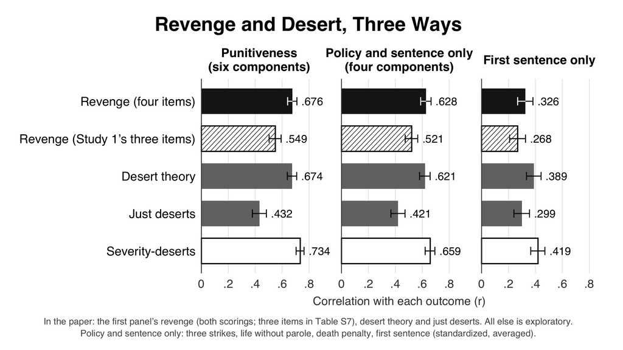

```r
keep_values("pt_11_three_outcomes", data.frame(
  label = paste0("r with ", gsub("\n", " ", OUT11[r11$outcome]), ": ", S11[r11$key]),
  value = r11$r, lower = r11$lower, upper = r11$upper, n = r11$n))
fig11
```

# 8. Slides 12 to 14: desert and its limits, and the sentences

Two questions Dan asked about the paper’s numbers. First, the paper gives desert theory’s correlations with the proportionality principle and the severity index as .199 and .474 in one place and as .078 and .277 in another. Both pairs are right: the first is the whole sample (Results, Part 2, H6), the second the retributivists alone (Part 3, H11). Slide 12 shows the two pairs side by side. Second, he asked for the sentences of the retributivists and of the other participants. Slide 13 shows both sentences for the two groups, and slide 14, a backup, splits the other participants by the goal they ranked first.

```r
# === SLIDE 12: DESERT THEORY WITH ITS TWO LIMITS, IN BOTH SAMPLES ===
# WHAT THIS CHUNK DOES: the correlation of desert theory with each of two
# measures of how punishment should relate to the crime, in two panels, the
# whole sample and the 371 retributivists:
#   - the proportionality principle, the single item "Punishment should be
#     proportionate to the severity of the crime, no more and no less" (the
#     second part of just deserts);
#   - the severity index, the mean of "Punishment should be greater than the
#     seriousness of the crime" and, reversed, "Punishment should be less
#     severe than the harmfulness of the crime" (section 3).
# It answers Dan's question why the paper gives these two correlations as
# .199 and .474 in one place and .078 and .277 in another: the first pair is
# the whole sample (Results, Part 2, H6; General Discussion), the second the
# retributivists alone (Results, Part 3, H11; General Discussion). The same
# comparison is run in two samples.
# READS: sc and rt (sections 3 and 4); h6, PAPER_H6's rows (slide 3's
#        chunk); PAPER_H6_cors, PAPER_H11_H6, PAPER_H11_H6_steiger and
#        PAPER_reliability for the guards.
# WRITES: pt_12_desert_limits_both; its values, with the difference between
#         the two correlations in each sample (and its two-sided p), and the
#         SDs of desert theory, the principle and the severity index in each
#         sample.
# MATCHES: Results, Part 2, H6: r = .199 [.137, .260] with the principle and
#          .474 [.423, .522] with the severity index, ∆r = .275 [.193, .356],
#          Z = 6.53, two-sided p < .001 (correlations not registered).
#          Results, Part 3, H11 (Table S17): r = .277 against .078,
#          ∆r = .200 [.044, .352], two-sided p = .012. Table 1: desert theory
#          SD 1.19. NEW: the retributivists' SD of desert theory (0.83) and the
#          95% CIs of the retributivists' two r's, which the paper does not
#          print; each is guarded against its value computed independently of
#          this document.
#
# WHY THE RETRIBUTIVISTS' CORRELATIONS ARE LOWER, said in the caption. The
# retributivists were chosen for ranking "Criminals deserve to be punished"
# first, and their desert-theory scores bunch near the top of the scale (mean
# 6.13, SD 0.83, against SD 1.19 in the whole sample). A correlation depends
# on how much the scores vary: with less spread in desert theory, there is
# less for it to share with anything else. The caption says "partly", because
# the narrower spread is one reason and need not be the only one.

# PANEL HEADERS, one per sample, worded as on slide 9. This slide answers
# Dan's first question and may be shown on its own, without slide 9 before
# it, so the right header says who the retributivists are, as slide 9's does:
# the participants who ranked retribution ("Criminals deserve to be punished")
# first of the four goals of punishment. The caption has no room for this.
P12 <- c(whole  = sprintf("Whole sample (N = %d)", nrow(sc)),
         retrib = sprintf("Retributivists (n = %d)\nranked retribution first", nrow(rt)))
stopifnot(P12[["whole"]] == "Whole sample (N = 948)",
          P12[["retrib"]] == "Retributivists (n = 371)\nranked retribution first")
# ROW LABELS. The principle is on top, then the severity index, the order in
# which the paper names them. Each label carries a short gloss, so the caption
# need define only desert theory and the severity index's two items:
#   - the principle's gloss quotes the end of its item ("no more and no
#     less"), the words that make it a limit in both directions;
#   - the severity index's gloss is the Method's own reading of a high score
#     ("punishment at or above the offense and never below it", shortened).
# DANGER: do not gloss the index as "punishment greater than the crime"; its
# high end is punishment AT or above the offense (see slide 1's caption).
LIM12 <- c(proportionality_principle = "Proportionality principle\n(“no more and no less”)",
           severity_index            = "Severity index\n(at or above the offense)")
SAMP12 <- list(whole = sc, retrib = rt)
# One row per sample and measure: r of desert theory with the measure, its
# Fisher 95% interval and n (cor_ci(), section 2).
r12 <- do.call(rbind, lapply(names(SAMP12), function(s)
  do.call(rbind, lapply(names(LIM12), function(v)
    cbind(sample = s, key = v,
          cor_ci(SAMP12[[s]]$desert_theory, SAMP12[[s]][[v]]),
          stringsAsFactors = FALSE)))))
r12_at <- function(s, v) r12[r12$sample == s & r12$key == v, ]
stopifnot(nrow(r12) == 4, all(r12$n[r12$sample == "whole"] == 948),
          all(r12$n[r12$sample == "retrib"] == 371))

# GUARDS, THE FOUR r's, against the export rows that hold them (1e-8, each
# number on its own): PAPER_H6_cors for the whole sample and PAPER_H11_H6 for
# the retributivists, where x is desert theory and y the limit.
h6c <- read_s2("PAPER_H6_cors"); h11h6 <- read_s2("PAPER_H11_H6")
EXP12 <- c(proportionality_principle = "Proportionality principle",
           severity_index = "Severity index")        # the exports' y labels
for (s in names(SAMP12)) for (v in names(LIM12)) {
  tab <- if (s == "whole") h6c else h11h6
  e <- tab[tab$x == "Desert theory" & tab$y == EXP12[[v]], ]
  stopifnot(nrow(e) == 1, e$n == r12_at(s, v)$n)
  same_each(unlist(r12_at(s, v)[, c("r", "lower", "upper")]),
            c(e$r, e$ci_lower, e$ci_upper),
            paste("slide 12:", s, v), labels = c("r", "lower", "upper"))
}
# ... then against the paper's printed values (three decimals). The paper
# prints the whole sample's intervals but not the retributivists'; those two
# are guarded against their values computed independently of this document.
paper_same(c(r12_at("whole", "proportionality_principle")$r, r12_at("whole", "severity_index")$r,
             r12_at("retrib", "proportionality_principle")$r, r12_at("retrib", "severity_index")$r),
           c(.199, .474, .078, .277), 3,
           "slide 12: desert theory with the principle and the index (H6 .199, .474; H11 .078, .277)")
paper_same(unlist(r12_at("whole", "proportionality_principle")[, c("lower", "upper")]),
           c(.137, .260), 3, "slide 12: whole sample, principle CI [.137, .260]")
paper_same(unlist(r12_at("whole", "severity_index")[, c("lower", "upper")]),
           c(.423, .522), 3, "slide 12: whole sample, severity index CI [.423, .522]")
paper_same(unlist(r12_at("retrib", "proportionality_principle")[, c("lower", "upper")]),
           c(-.024, .178), 3, "slide 12: retributivists, principle CI [-.024, .178] (new)")
paper_same(unlist(r12_at("retrib", "severity_index")[, c("lower", "upper")]),
           c(.180, .369), 3, "slide 12: retributivists, severity index CI [.180, .369] (new)")
```

```r
# THE DIFFERENCE BETWEEN THE TWO CORRELATIONS in each sample, as the paper
# tests it: dep_cor() (section 2) with j = desert theory, the score both
# correlations share, k = the severity index and h = the principle, so the
# difference is r(desert, index) - r(desert, principle); Steiger's Z,
# two-sided, and Zou's interval. dep_cor() was written for revenge against a
# rival, so its columns are named for that use: here r_revenge is
# r(desert, index), r_rival is r(desert, principle), and r_revenge_rival is
# r(index, principle). Not drawn: it goes to the values table.
dr12 <- rbind(
  cbind(sample = "whole",  dep_cor(sc$desert_theory, sc$severity_index, sc$proportionality_principle)),
  cbind(sample = "retrib", dep_cor(rt$desert_theory, rt$severity_index, rt$proportionality_principle)))
# GUARDS against the exports: PAPER_H6's "Desert theory" row (whole sample)
# and PAPER_H11_H6_steiger (retributivists), where r_jk is the index and r_jh
# the principle, as here. Their p is cocor's two-sided p, which loses digits
# to cancellation once p is small (see same_p(), section 2), hence the floor.
h6d <- h6[h6$pair == "Desert theory", ]; h11s <- read_s2("PAPER_H11_H6_steiger")
stopifnot(nrow(h6d) == 1, nrow(h11s) == 1, h6d$n == 948, h11s$n == 371,
          h6d$alternative == "two.sided", h11s$alternative == "two.sided")
for (s in c("whole", "retrib")) {
  e <- if (s == "whole") h6d else h11s
  x <- dr12[dr12$sample == s, ]
  same_each(c(x$r_revenge, x$r_rival, x$r_revenge_rival, x$diff, x$diff_lower, x$diff_upper, x$z),
            c(e$r_jk, e$r_jh, e$r_kh, e$diff, e$diff_lower, e$diff_upper, e$z),
            paste("slide 12: difference,", s),
            labels = c("r(desert, index)", "r(desert, principle)", "r(index, principle)",
                       "difference", "lower", "upper", "Z"))
  same_p(x$p_two, e$p, paste("slide 12: difference p,", s), floor = 1e-15)
}
paper_same(unlist(dr12[dr12$sample == "whole", c("diff", "diff_lower", "diff_upper")]),
           c(.275, .193, .356), 3, "H6: ∆r = .275 [.193, .356]")
paper_same(dr12$z[dr12$sample == "whole"], 6.53, 2, "H6: Z = 6.53")
stopifnot(dr12$p_two[dr12$sample == "whole"] < .001)                # "p < .001"
paper_same(unlist(dr12[dr12$sample == "retrib", c("diff", "diff_lower", "diff_upper")]),
           c(.200, .044, .352), 3, "H11 (H6 among retributivists): ∆r = .200 [.044, .352]")
paper_same(dr12$p_two[dr12$sample == "retrib"], .012, 3, "H11 (H6 among retributivists): p = .012")

# THE SPREAD OF EACH SCORE in each sample (SD, n - 1 denominator). Desert
# theory's whole-sample SD is Table 1's (PAPER_reliability, 1e-8); the
# retributivists' SD is new, and both are guarded at the two decimals the
# caption prints. The SDs of the principle and the index go to the values
# table too, so a reader can see that their spread barely changes among
# retributivists (1.36 and 1.37; 1.24 and 1.13): the narrower spread is desert
# theory's.
sd12 <- do.call(rbind, lapply(names(SAMP12), function(s)
  data.frame(sample = s, key = c("desert_theory", names(LIM12)),
             sd = vapply(c("desert_theory", names(LIM12)),
                         function(v) stats::sd(SAMP12[[s]][[v]]), numeric(1)),
             n = nrow(SAMP12[[s]]), stringsAsFactors = FALSE)))
sd_at <- function(s, v) sd12$sd[sd12$sample == s & sd12$key == v]
rel <- read_s2("PAPER_reliability")
rel_dt <- rel[grepl("^Desert theory \\(paper\\)", rel$score), ]
stopifnot(nrow(rel_dt) == 1)
same(sd_at("whole", "desert_theory"), rel_dt$SD, "slide 12: desert theory SD (PAPER_reliability, Table 1)")
paper_same(c(sd_at("whole", "desert_theory"), sd_at("retrib", "desert_theory")), c(1.19, 0.83), 2,
           "slide 12: desert theory SD, 1.19 whole sample and 0.83 retributivists")
paper_same(c(sd_at("whole", "proportionality_principle"), sd_at("retrib", "proportionality_principle"),
             sd_at("whole", "severity_index"), sd_at("retrib", "severity_index")),
           c(1.36, 1.37, 1.24, 1.13), 2, "slide 12: SDs of the principle and the index (new)")

# THE PLOT: bar_facets() (section 2), two panels on one shared r axis.
d12 <- data.frame(panel = factor(P12[r12$sample], levels = unname(P12)), key = r12$key,
                  value = r12$r, lower = r12$lower, upper = r12$upper, n = r12$n,
                  stringsAsFactors = FALSE)
d12$label <- factor(LIM12[d12$key], levels = rev(unname(LIM12)))   # principle on top
# FILL: the severity index in the darkest gray, G1, with the white knock-out
# inside its bar (mark_dark(), ci_knockout()); the principle in the mid gray,
# G3, with a plain black interval, which reads on G3 (section 2).
SHADE12 <- c(proportionality_principle = "Principle", severity_index = "Index")
FILLS12 <- c(Principle = G3, Index = G1)
d12$shade <- unname(SHADE12[d12$key])
d12$txt <- fmt_r(d12$value, digits = 3); d12$tx <- pmax(d12$upper, 0) + 0.012
# THE AXIS runs from just below zero, so the retributivists' interval for the
# principle (lower end -.024) is drawn whole, to .6, past the largest printed
# value; its ticks start at "0" (axis_r()).
fig12 <- bar_facets(d12, FILLS12, lims = data.frame(x = c(-0.05, 0.6)),
                    breaks = seq(0, 0.6, 0.2), labels = axis_r,
                    xlab = "Correlation with desert theory (r), with 95% CIs") +
  # The right panel's header is two lines, the left one line; as on slide 9,
  # vjust = 0 sets both headers on the bottom of their strips, so both end
  # the same distance above their bars.
  theme(panel.spacing.x = unit(3, "lines"),
        axis.text.y = element_text(colour = INK, size = 19, lineheight = 0.95),
        strip.text = element_text(size = 20, face = "bold", colour = INK, vjust = 0,
                                  lineheight = 0.95, margin = margin(b = 10))) +
  # THE CAPTION: the severity index's two items on the first line, whole;
  # desert theory's definition and the reason the retributivists'
  # correlations are lower on the second ("0.83 vs. 1.19 overall": the
  # retributivists' SD against the whole sample's). The principle's gloss is
  # on its row, and the axis title says the error bars are 95% CIs, because
  # the two caption lines have no room left for it.
  labs(title = "Desert, Proportionality, and Severity",
       caption = cap("Severity index: “greater than the seriousness of the crime” and, reversed, “less severe than the harmfulness of the crime.”",
                     "Desert theory: five items. Retributivists’ correlations are lower partly because their desert scores vary less (SD 0.83 vs. 1.19 overall)."))
save_slide(fig12, "pt_12_desert_limits_both")
```

```
## [1] TRUE
```

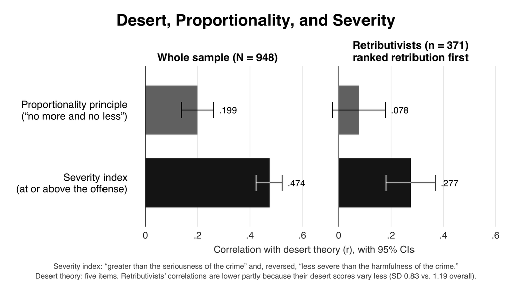

```r
SNAME12 <- c(whole = "whole sample", retrib = "retributivists")
keep_values("pt_12_desert_limits_both", rbind(
  data.frame(label = paste0("r with desert theory, ", SNAME12[r12$sample], ": ",
                            EXP12[r12$key]),
             value = r12$r, lower = r12$lower, upper = r12$upper, n = r12$n),
  data.frame(label = paste0("Difference, r(desert theory, severity index) minus r(desert theory, principle), ",
                            SNAME12[dr12$sample], " (Zou 95% CI)"),
             value = dr12$diff, lower = dr12$diff_lower, upper = dr12$diff_upper, n = dr12$n),
  data.frame(label = paste0("Difference, ", SNAME12[dr12$sample],
                            ", two-sided p (Steiger Z)"),
             value = dr12$p_two, lower = NA, upper = NA, n = dr12$n),
  data.frame(label = paste0("SD, ", SNAME12[sd12$sample], ": ",
                            c(desert_theory = "Desert theory", EXP12)[sd12$key]),
             value = sd12$sd, lower = NA, upper = NA, n = sd12$n)))
fig12
```

```r
# === SLIDE 13: THE TWO SENTENCES, RETRIBUTIVISTS AND ALL OTHERS ===
# WHAT THIS CHUNK DOES: the first and second sentences, in years (0 to 50,
# 50 = life), as violins, in two panels (first sentence, second sentence),
# each with two violins: the 371 retributivists and the 577 other
# participants, the registered ranking comparison. Each violin has every
# participant as a point, the mean with its 95% interval, and, under it, the
# median and the share choosing the 50-year maximum.
# READS: d (Sentence1, Sentence2, Sentence1_z); sc (grp_rank,
#        grp_vs_deter_incap); descriptives, PAPER_contrasts_rank,
#        PAPER_contrasts_vs_deter_incap and P3_sentence_direction_by_ranking
#        for the guards.
# WRITES: pt_13_sentences_groups; its values (means, intervals, medians, SDs,
#         shares choosing 50, the shares who reduced, kept, or raised the
#         sentence, and the two H14 d's).
# MATCHES: Results, Study 2: the whole sample's mean first sentence, 36.2
#          years, and the mean second sentence, 29.4. Results, Part 3, H14
#          (registered, on the first sentence standardized within vignette):
#          d = 0.51 against all others (Table S19) and 0.41 against the
#          deterrence- or incapacitation-first (Table S19, last column).
#          NEW AND DESCRIPTIVE: every number in years for the two groups (the
#          paper tests the standardized sentence, not raw years).
#
# WHY "ALL OTHER PARTICIPANTS" and not the deterrence- or incapacitation-first.
# Dan asked for retributivists and non-retributivists, and the registered H14
# comparison is with all 577 others (slides 6 and 7). The caption also gives
# the d against the stricter group, the comparison the main text reports.
# Slide 14 splits the 577 by the goal they ranked first.
# RAW YEARS. The three vignettes differ a little in their sentences, so H14 is
# tested on the sentence standardized within vignette. The slide shows raw
# years, which a talk audience reads directly; the vignettes were assigned
# at random and split almost evenly (315, 317, 316), so the groups'
# raw-year means are not distorted by vignette in any way that matters here,
# but they are descriptive, and the caption says so.

SENT13 <- c(Sentence1 = "First sentence", Sentence2 = "Second sentence")
GRP13  <- c(ret = "Retributivists", oth = "All other participants")
# THE GROUPS: the registered ranking grouping (grp_rank; section 3), first
# level "Retributivist". The guard ties it to the retributivist flag.
g13 <- ifelse(sc$grp_rank == levels(sc$grp_rank)[1], "ret", "oth")
stopifnot(!anyNA(d[, names(SENT13)]), !anyNA(g13),
          identical(g13 == "ret", d$retributivist == 1),
          identical(as.integer(table(factor(g13, levels = names(GRP13)))), c(371L, 577L)),
          all(unlist(d[, names(SENT13)]) %in% 0:50))   # whole years, 0 to 50

# ONE ROW PER SENTENCE AND GROUP: mean with its t interval (mean_ci()), the
# median, the SD, and the share choosing 50 with its exact interval
# (share_cp()). The median prints without decimals when it is a whole year.
sent_row <- function(x) {
  m <- mean_ci(x); s50 <- share_cp(x == 50)
  data.frame(n = m$n, mean = m$mean, lower = m$lower, upper = m$upper,
             median = stats::median(x), sd = stats::sd(x), k50 = s50$k,
             share50 = s50$share, share50_lower = s50$lower, share50_upper = s50$upper)
}
st13 <- do.call(rbind, lapply(names(SENT13), function(v)
  do.call(rbind, lapply(names(GRP13), function(g)
    cbind(sentence = v, group = g, sent_row(d[[v]][g13 == g]), stringsAsFactors = FALSE)))))
st_at <- function(v, g) st13[st13$sentence == v & st13$group == g, ]

# GUARDS.
# 1. The n's.
stopifnot(identical(as.integer(st13$n), c(371L, 577L, 371L, 577L)))
# 2. The whole sample's mean first sentence is the export's and the paper's
#    36.2, and the second sentence's the paper's 29.4; and each pair of group
#    means averages back to the whole-sample mean (n-weighted), which a slip
#    in the grouping would break.
desc <- read_s2("descriptives")
same(mean(d$Sentence1), desc$mean[desc$variable == "Sentence1"], "slide 13: mean first sentence (descriptives)")
paper_same(mean(d$Sentence1), 36.2, 1, "mean first sentence 36.2")
paper_same(mean(d$Sentence2), 29.4, 1, "mean second sentence 29.4")
for (v in names(SENT13))
  same((371 * st_at(v, "ret")$mean + 577 * st_at(v, "oth")$mean) / 948, mean(d[[v]]),
       paste("slide 13: group means average to the whole-sample mean,", v))
# 3. H14, the registered test, on the standardized first sentence: welch_d()
#    (section 2, 01's welch_contrast()) against all others (PAPER_contrasts_rank)
#    and against the deterrence- or incapacitation-first
#    (PAPER_contrasts_vs_deter_incap), 1e-8 for each number, then the printed
#    d's, 0.51 and 0.41.
h14 <- rbind(cbind(comparison = "all others",
                   welch_d(d$Sentence1_z, sc$grp_rank)),
             cbind(comparison = "deterrence- or incapacitation-first",
                   welch_d(d$Sentence1_z, sc$grp_vs_deter_incap)))
EXP14 <- list(read_s2("PAPER_contrasts_rank"), read_s2("PAPER_contrasts_vs_deter_incap"))
for (i in 1:2) {
  e <- EXP14[[i]][EXP14[[i]]$variable == "Sentence1_z", ]
  stopifnot(nrow(e) == 1, e$hypothesis == "H14", e$alternative == "greater",
            e$n1 == h14$n1[i], e$n2 == h14$n2[i])
  same_each(unlist(h14[i, c("M1", "M2", "t", "d", "lower", "upper")]),
            c(e$M1, e$M2, e$t, e$d, e$d_lower, e$d_upper),
            paste("slide 13: H14 against", h14$comparison[i]),
            labels = c("M1", "M2", "t", "d", "lower", "upper"))
  same_p(h14$p_dir[i], e$p_dir, paste("slide 13: H14 one-sided p against", h14$comparison[i]))
}
stopifnot(identical(as.integer(h14$n2), c(577L, 453L)))
paper_same(h14$d, c(0.51, 0.41), 2, "H14: d = 0.51 against all others, 0.41 against deterrence/incapacitation-first")
# 4. The raw-year values, against their values computed independently of this
#    document: first sentence 39.9 [38.8, 41.1], Mdn 45, 48.8% at 50, against
#    33.8 [32.7, 34.9], Mdn 30, 31.0%; second sentence 34.4 (Mdn 35) against
#    26.3 (Mdn 25).
paper_same(unlist(st_at("Sentence1", "ret")[, c("mean", "lower", "upper")]), c(39.9, 38.8, 41.1), 1,
           "first sentence, retributivists 39.9 [38.8, 41.1]")
paper_same(unlist(st_at("Sentence1", "oth")[, c("mean", "lower", "upper")]), c(33.8, 32.7, 34.9), 1,
           "first sentence, all others 33.8 [32.7, 34.9]")
paper_same(st13$mean[st13$sentence == "Sentence2"], c(34.4, 26.3), 1, "second sentence means 34.4 and 26.3")
# (== rather than identical(): the medians of whole-year sentences can come
# back as integers or doubles, and only their values matter.)
stopifnot(all(st13$median == c(45, 30, 35, 25)))
paper_same(100 * st13$share50[st13$sentence == "Sentence1"], c(48.8, 31.0), 1,
           "first sentence, share choosing 50: 48.8% and 31.0%")
```

```r
# WHO REDUCED, KEPT, OR RAISED THE SENTENCE, by group. Values table only; the
# caption gives the share who reduced it.
# DANGER: THE ONE PARTICIPANT WHOSE FIRST SENTENCE WAS 0 is left out, as in
# the analysis (the sentencing ratio needs a first sentence above zero) and in
# the Supplement's figure of the groupings (Panel C, n = 947). The others'
# share who reduced is therefore 306 of 576, 53.1%. Counting that participant
# as having kept the sentence would give 306 of 577, 53.0%; the guard against
# P3_sentence_direction_by_ranking holds this document to the analysis's
# rule.
ok13  <- d$Sentence1 > 0
dir13 <- ifelse(d$Sentence2 < d$Sentence1, "reduced",
                ifelse(d$Sentence2 == d$Sentence1, "kept", "raised"))
DIRS  <- c("reduced", "kept", "raised")
tab13 <- table(factor(g13[ok13], levels = names(GRP13)), factor(dir13[ok13], levels = DIRS))
p3 <- read_s2("P3_sentence_direction_by_ranking")
EXP_GRP13 <- c(ret = "Retributivist", oth = "Other")       # the export's group names
for (g in names(GRP13)) {
  e <- p3[p3$group == EXP_GRP13[[g]], ]
  stopifnot(nrow(e) == 1, e$n == sum(tab13[g, ]),
            identical(as.integer(tab13[g, DIRS]), as.integer(unlist(e[, DIRS]))))
  same_each(tab13[g, DIRS] / sum(tab13[g, ]), unlist(e[, paste0("share_", DIRS)]),
            paste("slide 13: reduced / kept / raised shares,", g), labels = DIRS)
}
stopifnot(identical(as.integer(rowSums(tab13)), c(371L, 576L)))
paper_same(100 * tab13[, "reduced"] / rowSums(tab13), c(34.2, 53.1), 1,
           "reduced the sentence: 34.2% of retributivists, 53.1% of the 576 others")
dir_rows <- do.call(rbind, lapply(names(GRP13), function(g) do.call(rbind, lapply(DIRS, function(k)
  cbind(group = g, direction = k,
        share_cp(factor(dir13[ok13 & g13 == g], levels = DIRS) == k), stringsAsFactors = FALSE)))))

# THE VIOLINS. A helper for slides 13 and 14, in the style of violin_1to7()
# (section 2): the violin is the shape of everyone's answers; each point is
# one participant, spread sideways only (seeded, so every knit draws the same
# slide); the black point is the mean and the black bar its 95% interval,
# with the mean printed beside it to one decimal.
#   long   one row per participant and violin: columns xlab (the violin's
#          axis label, a factor in the slide's order), years, and panel where
#          the slide has panels.
#   stats  one row per violin: xlab, mean, lower, upper (and panel).
# THE AXIS LABEL UNDER EACH VIOLIN carries the group, its n, the median, and
# the share choosing 50, so these sit under the violin they describe rather
# than in a legend. On slide 13 the two panels have different medians, so each
# panel's labels are its own levels, and the panels take scales = "free_x".
# scale = "width" gives every violin the same greatest width, as on slide 1,
# so a small group's violin is not drawn thinner for being small.
# adjust = 1.4 smooths the violins a little more than the default, because
# the sentences heap on multiples of 5 and the default bandwidth would draw a
# ripple for each heap.
# THE Y AXIS runs from 0 to 50 in steps of 10, with 50 labelled "50 (life)",
# as the instructions equated 50 years with life.
# DANGER: limits = c(0, 50) drops any value outside 0 to 50; there are none
# (guarded above), and a change to the data that produced one would silently
# lose it from the violins, so keep that guard with this scale.
violin_years <- function(long, stats) {
  ggplot(long, aes(x = xlab, y = years)) +
    geom_violin(fill = FILL_VIOLIN, colour = G3, linewidth = 0.6, width = 0.8,
                scale = "width", adjust = 1.4, trim = TRUE) +
    geom_point(position = position_jitter(width = 0.2, height = 0, seed = 1),
               size = 1.1, alpha = 0.3, colour = G3, stroke = 0) +
    geom_errorbar(data = stats, aes(x = xlab, ymin = lower, ymax = upper),
                  inherit.aes = FALSE, width = 0.1, linewidth = 1, colour = INK) +
    geom_point(data = stats, aes(x = xlab, y = mean), inherit.aes = FALSE,
               size = 5, colour = INK) +
    geom_label(data = stats, aes(x = xlab, y = mean, label = sprintf("%.1f", mean)),
               inherit.aes = FALSE, nudge_x = 0.2, hjust = 0, size = 6,
               label.size = 0, fill = "white", label.padding = unit(0.15, "lines")) +
    scale_y_continuous(breaks = seq(0, 50, 10), limits = c(0, 50),
                       labels = c("0", "10", "20", "30", "40", "50 (life)")) +
    labs(x = NULL, y = "Years in prison") +
    theme_vbar() +
    theme(axis.text.x = element_text(colour = INK, size = 17, lineheight = 0.95))
}
# The median as printed: whole years without decimals ("45"), a half year
# with one ("25.5").
fmt_mdn <- function(m) ifelse(m == round(m), sprintf("%.0f", m), sprintf("%.1f", m))
# The label under a violin, four short lines: the group, its n, the median
# ("Mdn 45"), and the share choosing 50 ("48.8% chose 50").
# LINE BREAKS. The violins on slides 13 and 14 sit about 2.4 inches apart, and
# at 17 pt a line much wider than 2 inches runs into its neighbour's label.
# "Mdn 45; 48.8% chose 50" on one line is about 2.6 inches and did; split in
# two, the widest line ("All other participants", about 2.3 inches, on slide
# 13's narrower panels still clear of its neighbour) fits.
vlab <- function(name, s) sprintf("%s\n(n = %d)\nMdn %s\n%.1f%% chose 50",
                                  name, s$n, fmt_mdn(s$median), 100 * s$share50)

st13$xlab <- vlab(GRP13[st13$group], st13)
st13$panel <- factor(SENT13[st13$sentence], levels = unname(SENT13))
# Each panel's two labels, retributivists first (left), in panel order.
st13$xlab <- factor(st13$xlab, levels = st13$xlab)
stopifnot(!anyDuplicated(levels(st13$xlab)))
long13 <- do.call(rbind, lapply(seq_len(nrow(st13)), function(i)
  data.frame(panel = st13$panel[i], xlab = st13$xlab[i],
             years = d[[st13$sentence[i]]][g13 == st13$group[i]])))
stopifnot(nrow(long13) == 2 * 948)

fig13 <- violin_years(long13, st13) +
  facet_wrap(~ panel, nrow = 1, scales = "free_x") +
  theme(strip.text = element_text(size = 20, face = "bold", colour = INK,
                                  margin = margin(b = 10)),
        panel.spacing.x = unit(3, "lines")) +
  # THE CAPTION: the registered test first, in the paper's terms (the d's are
  # on the standardized first sentence, not on the years drawn); then that
  # the years are descriptive, what the black marks are, and the share who
  # reduced the sentence. "vs." rather than "against" keeps the first line
  # within the 140 characters cap() allows.
  labs(title = "Sentences by Group",
       caption = cap("Registered test (H14), first sentence standardized within vignette: d = 0.51 vs. all others (0.41 vs. deterrence- or incapacitation-first).",
                     "Years are raw and descriptive. Black points: means with 95% CIs. Reduced the second sentence: 34.2% of retributivists, 53.1% of the others."))
save_slide(fig13, "pt_13_sentences_groups")
```

```
## [1] TRUE
```

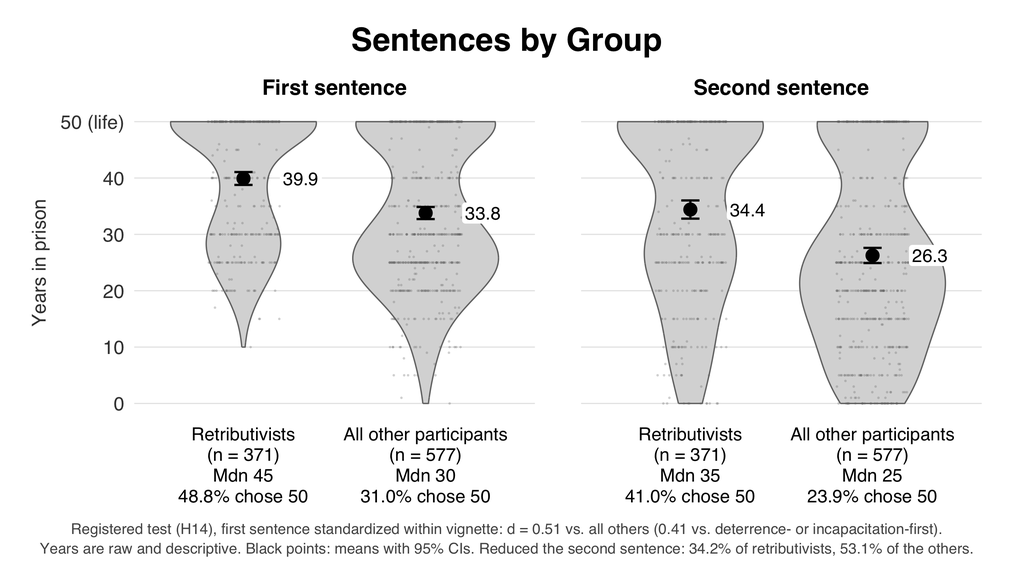

```r
GNAME13 <- c(ret = "retributivists", oth = "all other participants")
SNAME13 <- c(Sentence1 = "first sentence", Sentence2 = "second sentence")
where13 <- paste0(SNAME13[st13$sentence], ", ", GNAME13[st13$group])
keep_values("pt_13_sentences_groups", rbind(
  data.frame(label = paste0("Mean (years, t 95% CI), ", where13),
             value = st13$mean, lower = st13$lower, upper = st13$upper, n = st13$n),
  data.frame(label = paste0("Median (years), ", where13),
             value = st13$median, lower = NA, upper = NA, n = st13$n),
  data.frame(label = paste0("SD (years), ", where13),
             value = st13$sd, lower = NA, upper = NA, n = st13$n),
  data.frame(label = paste0("Share choosing 50 years (%, exact 95% CI), ", where13),
             value = 100 * st13$share50, lower = 100 * st13$share50_lower,
             upper = 100 * st13$share50_upper, n = st13$n),
  data.frame(label = paste0("Share who ", dir_rows$direction, " the sentence (%, exact 95% CI; first sentence above 0), ",
                            GNAME13[dir_rows$group]),
             value = 100 * dir_rows$share, lower = 100 * dir_rows$lower,
             upper = 100 * dir_rows$upper, n = dir_rows$n),
  data.frame(label = paste0("H14 (registered), Cohen's d, first sentence standardized within vignette, retributivists vs ",
                            h14$comparison),
             value = h14$d, lower = h14$lower, upper = h14$upper, n = h14$n1 + h14$n2)))
fig13
```

```r
# === SLIDE 14 (BACKUP): THE FIRST SENTENCE BY THE GOAL RANKED FIRST ===
# WHAT THIS CHUNK DOES: the first sentence, in years, as four violins, one
# for each group defined by the goal of punishment ranked first of four:
# retribution (the retributivists, 371), incapacitation (266), deterrence
# (187) and rehabilitation (124), in that order, from the longest mean
# sentence to the shortest. Mean with its 95% interval, median, and share
# choosing 50, as on slide 13.
# It shows that the "non-retributivists" of slide 13 are not one group: the
# 124 who ranked rehabilitation first gave by far the shortest sentences, and
# the deterrence- and incapacitation-first sit between them and the
# retributivists.
# READS: d (Sentence1, Sentence1_z); `first` (section 3, the goal each
#        participant ranked first); st13 (slide 13); first_choice_group_means
#        for the guards.
# WRITES: pt_14_sentences_by_goal; its values.
# MATCHES: Table S20, "First sentence, z within vignette (H14)": 0.30, −0.14,
#          −0.06, −0.55 for retribution, deterrence, incapacitation and
#          rehabilitation first (standardized; the grouping by first choice
#          was not registered and no test compares the four groups). NEW AND
#          DESCRIPTIVE: every number in years.

# THE GROUPS, in the slide's order. `first` holds the column of the goal
# ranked first: 1 retribution, 2 deterrence, 3 incapacitation, 4
# rehabilitation (section 3). The slide's order is retribution,
# incapacitation, deterrence, rehabilitation.
# DANGER: the codes and the names must move together. GOAL14's names are the
# codes as character strings; the guard on the counts below catches a
# mismatch.
GOAL14 <- c("1" = "Retribution", "3" = "Incapacitation", "2" = "Deterrence",
            "4" = "Rehabilitation")
st14 <- do.call(rbind, lapply(names(GOAL14), function(k)
  cbind(code = as.integer(k), goal = GOAL14[[k]], sent_row(d$Sentence1[first == as.integer(k)]),
        z_mean = mean(d$Sentence1_z[first == as.integer(k)]), stringsAsFactors = FALSE)))
stopifnot(identical(as.integer(st14$n), c(371L, 266L, 187L, 124L)))   # Part 3: 371, 266, 187, 124

# GUARDS.
# 1. The retribution-first group is slide 13's retributivists: the same mean,
#    interval, median, SD and share at 50, to 1e-8.
same_each(unlist(st14[1, c("n", "mean", "lower", "upper", "median", "sd", "share50")]),
          unlist(st_at("Sentence1", "ret")[, c("n", "mean", "lower", "upper", "median", "sd", "share50")]),
          "slide 14: retribution first = slide 13's retributivists",
          labels = c("n", "mean", "lower", "upper", "median", "sd", "share50"))
# 2. The four groups' standardized first sentence is Table S20's
#    (first_choice_group_means, H14 row, 1e-8 each), and the printed two
#    decimals. This ties the four groups to the paper's grouping.
fcm <- read_s2("first_choice_group_means")
fcm14 <- fcm[fcm$hypothesis == "H14" & fcm$outcome == "Sentence 1 (z within vignette)", ]
stopifnot(nrow(fcm14) == 1)
EXP_COL14 <- c("1" = "desert_first", "3" = "incapacitation_first", "2" = "deterrence_first",
               "4" = "rehabilitation_first")                   # in the slide's order
same_each(st14$z_mean, unlist(fcm14[, EXP_COL14]), "slide 14: standardized first sentence (Table S20)",
          labels = st14$goal)
paper_same(st14$z_mean, c(0.30, -0.06, -0.14, -0.55), 2, "Table S20: 0.30, −0.06, −0.14, −0.55")
# 3. The raw-year values, against their values computed independently of
#    this document: 39.9, 35.5, 34.5, 29.1; and the four groups' means
#    average back to the whole-sample mean (n-weighted).
paper_same(st14$mean, c(39.9, 35.5, 34.5, 29.1), 1, "first sentence by goal: 39.9, 35.5, 34.5, 29.1")
same(sum(st14$n * st14$mean) / 948, mean(d$Sentence1), "slide 14: group means average to the whole-sample mean")

st14$xlab <- factor(vlab(st14$goal, st14), levels = vlab(st14$goal, st14))
long14 <- do.call(rbind, lapply(seq_len(nrow(st14)), function(i)
  data.frame(xlab = st14$xlab[i], years = d$Sentence1[first == st14$code[i]])))
stopifnot(nrow(long14) == 948)

fig14 <- violin_years(long14, st14) +
  labs(title = "First Sentence by First-Ranked Goal",
       caption = cap("Groups by the goal of punishment ranked first of four. Raw years, descriptive; no test compares the four groups.",
                     "Black points: means with 95% CIs. Table S20 gives the first sentence standardized within vignette for the same four groups."))
save_slide(fig14, "pt_14_sentences_by_goal")
```

```
## [1] TRUE
```

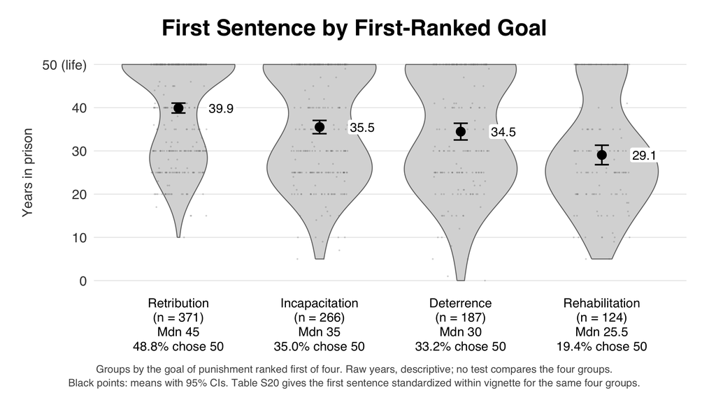

```r
keep_values("pt_14_sentences_by_goal", rbind(
  data.frame(label = paste0("Mean first sentence (years, t 95% CI), ranked first: ", st14$goal),
             value = st14$mean, lower = st14$lower, upper = st14$upper, n = st14$n),
  data.frame(label = paste0("Median first sentence (years), ranked first: ", st14$goal),
             value = st14$median, lower = NA, upper = NA, n = st14$n),
  data.frame(label = paste0("SD of first sentence (years), ranked first: ", st14$goal),
             value = st14$sd, lower = NA, upper = NA, n = st14$n),
  data.frame(label = paste0("Share choosing 50 years (%, exact 95% CI), ranked first: ", st14$goal),
             value = 100 * st14$share50, lower = 100 * st14$share50_lower,
             upper = 100 * st14$share50_upper, n = st14$n),
  data.frame(label = paste0("Mean first sentence standardized within vignette (Table S20), ranked first: ", st14$goal),
             value = st14$z_mean, lower = NA, upper = NA, n = st14$n)))
fig14
```

# 9. What was written

```r
# === THE TWO TABLES ===
# WHAT THIS CHUNK DOES: writes every plotted value to one table, so a number on
# any slide can be looked up, and writes the tests behind slides 1 to 4, 9 and
# 11.
# WRITES: output/tables/princeton_talk_figure_values.csv (figure, label, value,
#         lower, upper, n), for all fourteen slides. Besides the plotted values
#         it holds slide 6's medians and typical interval half-widths,
#         slide 10's differences in percentage points and their two-sided p's
#         and slide 12's differences between correlations and their
#         two-sided p's (a p sits in `value`, with lower and upper empty; the
#         label says so), slide 12's SDs, and slides 13 and 14's medians, SDs,
#         shares choosing 50, who reduced, kept, or raised the sentence, the
#         H14 d's and Table S20's standardized means.
#         And output/tables/princeton_talk_tests.csv: the dependent-correlation
#         tests and paired endorsement differences of the tests chunk (18
#         rows) and slide 11's six tests on the other two outcomes, with an
#         `outcome` column saying which outcome each correlation test uses.
#         Slides 12 to 14 add no rows to the tests table.
# GUARDS: all fourteen slides' values are present, and nothing else.
vals <- do.call(rbind, VALUES)
rownames(vals) <- NULL
vals$label <- gsub("\n", " ", vals$label)
stopifnot(identical(names(vals), c("figure", "label", "value", "lower", "upper", "n")),
          identical(sort(unique(vals$figure)),
                    c("pt_01_endorsement", "pt_02_punitiveness", "pt_03_parts",
                      "pt_04_retributivists", "pt_05_agency", "pt_06_four_groupings",
                      "pt_07_groupings_summary", "pt_08_endorsing_punishing",
                      "pt_09_revenge_desert_both", "pt_10_agency_shares",
                      "pt_11_three_outcomes", "pt_12_desert_limits_both",
                      "pt_13_sentences_groups", "pt_14_sentences_by_goal")),
          !anyNA(vals$value))
write.csv(vals, file.path(OUT_TABLES, "princeton_talk_figure_values.csv"), row.names = FALSE)
write.csv(TESTS, file.path(OUT_TABLES, "princeton_talk_tests.csv"), row.names = FALSE)
cat(sprintf("%d plotted values written to princeton_talk_figure_values.csv\n", nrow(vals)))
```

```
## 232 plotted values written to princeton_talk_figure_values.csv
```

```r
cat(sprintf("%d tests written to princeton_talk_tests.csv\n", nrow(TESTS)))
```

```
## 24 tests written to princeton_talk_tests.csv
```

```r
print(list.files(OUT_FIGURES))
```

```
##  [1] "pt_01_endorsement.pdf"         "pt_01_endorsement.png"
##  [3] "pt_02_punitiveness.pdf"        "pt_02_punitiveness.png"
##  [5] "pt_03_parts.pdf"               "pt_03_parts.png"
##  [7] "pt_04_retributivists.pdf"      "pt_04_retributivists.png"
##  [9] "pt_05_agency.pdf"              "pt_05_agency.png"
## [11] "pt_06_four_groupings.pdf"      "pt_06_four_groupings.png"
## [13] "pt_07_groupings_summary.pdf"   "pt_07_groupings_summary.png"
## [15] "pt_08_endorsing_punishing.pdf" "pt_08_endorsing_punishing.png"
## [17] "pt_09_revenge_desert_both.pdf" "pt_09_revenge_desert_both.png"
## [19] "pt_10_agency_shares.pdf"       "pt_10_agency_shares.png"
## [21] "pt_11_three_outcomes.pdf"      "pt_11_three_outcomes.png"
## [23] "pt_12_desert_limits_both.pdf"  "pt_12_desert_limits_both.png"
## [25] "pt_13_sentences_groups.pdf"    "pt_13_sentences_groups.png"
## [27] "pt_14_sentences_by_goal.pdf"   "pt_14_sentences_by_goal.png"
```

```r
print(list.files(DOCS_FIG))
```

```
##  [1] "~$tes on the talk figures.docx" "Email to Dan.txt"
##  [3] "Notes on the talk figures.docx" "pt_01_endorsement.png"
##  [5] "pt_02_punitiveness.png"         "pt_03_parts.png"
##  [7] "pt_04_retributivists.png"       "pt_05_agency.png"
##  [9] "pt_06_four_groupings.png"       "pt_07_groupings_summary.png"
## [11] "pt_08_endorsing_punishing.png"  "pt_09_revenge_desert_both.png"
## [13] "pt_10_agency_shares.png"        "pt_11_three_outcomes.png"
## [15] "pt_12_desert_limits_both.png"   "pt_13_sentences_groups.png"
## [17] "pt_14_sentences_by_goal.png"    "Reply to Dan, 29 Sep.txt"
```